# Non-additive genetic effects induce novel phenotypic distributions in male mating traits of F1 hybrids

Supplementary Information

Keisuke Atsumi, Malgorzata Lagisz & Shinichi Nakagawa

21/02/22 12:42

## Load packages

```r
rm(list=ls())  # reset workspace
options(scipen=100)  # do not show numbers using exponential

# install & load packages
pacman::p_load(
  openxlsx   # open excel
  , tidyverse
  , magrittr   # extended pipe
  , foreach    # Parallel processing
  , metafor    # meta-analysis
  , MCMCglmm   # comparative analysis
  , orchaRd    # Orchard plot - meta-analysis
  , rotl       # open tree of life
  , ape        # Phylogeny
  , phytools   # Phylogeny
  , knitr
  , kableExtra # nice tables
  , pander     # nice tables
  , svglite    # Export SVG plots
  , ggiraphExtra # Geom predict
  , ggbeeswarm # Orchard plot
  , ggtree
  , patchwork   # combine multiple plots
  # , R.rsp
)

# Rmarkdown settings
knitr::opts_chunk$set(
  prompt  = FALSE,  # Do not add > or + in inline-code
  message = FALSE,
  comment = "",
  warning = FALSE,  # Mute warnings
  tidy    = TRUE
  )
options(knitr.kable.NA = '') # Hide NAs in kable table
```

## Custom function

We have custom functions named : `get_pred()`, `get_reg()`, `get_fixed.MCMCglmm()` and `get_random.MCMCglmm()`, all of which are used later (see below for their functionality) and the code are included here.

```r
#' Title: get_pred
#' function to get prediction intervals (crediblity intervals) from rma objects (metafor)
#'
#' @param model: rma.mv object
#' @param mod: the name of a moderator
get_pred <- function(model, mod = " ") {
  I2 <- i2_ml(model) %>%
    as.data.frame() %>%
    rownames_to_column("Partition") %>%
    rename("I2" = ".") %>%
    mutate(percentage = str_c(round(I2*100,1),"%", sep = "")) %>%
    column_to_rownames("Partition")

  name <- as.factor(str_replace(row.names(model$beta), mod, ""))
  len <- length(name)

  if (len != 1) {
      newdata <- matrix(NA, ncol = len, nrow = len)
      for (i in 1:len) {
          # getting the position of unique case from X (design matrix)
          pos <- which(model$X[, i] == 1)[[1]]
          newdata[, i] <- model$X[pos, ]
      }
      pred <- predict.rma(model, newmods = newdata)
    } else {
        pred <- predict.rma(model)
    }

    table <- tibble(
      'Dataset' = "",
      'Fixed effects' = name,
      'Estimate' = model$beta, # regression: estimate
      'LowerCI' = model$ci.lb, # regression: 95ci,
      'UpperCI'  = model$ci.ub, # regression: 95ci
      'lowerPR' = pred$cr.lb,  # lower prediction range
      'upperPR' = pred$cr.ub, # lower prediction range
      'Praw'        = model$pval,
    # 'V[species with phylogeny]' =
    #   c(model$sigma2[1], rep("", length(model$beta))),
    # 'V[study]' =
    #   c(model$sigma2[2], rep("", length(model$beta))),
    # 'V[crossed strain]' =
    #   c(model$sigma2[3], rep("", length(model$beta))),
    # 'V[residual]' =
    #   c(model$sigma2[4], rep("", length(model$beta))),
    'I2[total]' =
      c(I2["I2_total","percentage"], rep("", length(model$beta)-1)),
    '%I2[species with phylogeny]' =
      c(I2["I2_spL.name","percentage"], rep("", length(model$beta)-1)),
    '%I2[study]' =
      c(I2["I2_Study.ID","percentage"], rep("", length(model$beta)-1)),
    '%I2[crossed strain]' =
      c(I2["I2_Cross.ID","percentage"], rep("", length(model$beta)-1)),
    '%I2[residual]' =
      c(I2["I2_ES.ID","percentage"], rep("", length(model$beta)-1)),
    )  %>%
    as.data.frame() %>%
    mutate_at(vars('Estimate':'Praw'), as.numeric) %>%
    mutate(P = ifelse(Praw < 0.001, "<0.001", round(Praw, 3))) %>%
    mutate(significance = ifelse(Praw < 0.05, "*", "")) %>%
    mutate_at("P", as.character) %>%
    select(-Praw)
}


#' Title: get_reg
#' function to get summary stats from rma objects (metafor)
#' @param model: rma.mv object
#' @param mod: the name of a moderator
get_reg <- function(model, mod = " ") {

  I2 <- i2_ml(model) %>%
    as.data.frame() %>%
    rownames_to_column("Partition") %>%
    rename("I2" = ".") %>%
    mutate(percentage = str_c(round(I2*100,1),"%", sep = "")) %>%
    column_to_rownames("Partition")

  table <- tibble(
    'Dataset' = "",
    'Fixed effects' = c("", row.names(model$beta)),
    'Estimate' = c("", model$beta), # regression: estimate
    'LowerCI' = c("", model$ci.lb), # regression: 95ci,
    'UpperCI'  = c("", model$ci.ub), # regression: 95ci
    'Praw'        = c("", model$pval),
    # 'V[species with phylogeny]' =
    #   c(model$sigma2[1], rep("", length(model$beta))),
    # 'V[study]' =
    #   c(model$sigma2[2], rep("", length(model$beta))),
    # 'V[crossed strain]' =
    #   c(model$sigma2[3], rep("", length(model$beta))),
    # 'V[residual]' =
    #   c(model$sigma2[4], rep("", length(model$beta))),
    'I2[total]' =
      c(I2["I2_total","percentage"], rep("", length(model$beta))),
    '%I2[species with phylogeny]' =
      c(I2["I2_spL.name","percentage"], rep("", length(model$beta))),
    '%I2[study]' =
      c(I2["I2_Study.ID","percentage"], rep("", length(model$beta))),
    '%I2[crossed strain]' =
      c(I2["I2_Cross.ID","percentage"], rep("", length(model$beta))),
    '%I2[residual]' =
      c(I2["I2_ES.ID","percentage"], rep("", length(model$beta))),
    )  %>%
    as.data.frame() %>%
    mutate_at(vars('Estimate':'Praw'), as.numeric) %>%
    mutate(P = ifelse(Praw < 0.001, "<0.001", round(Praw, 3))) %>%
    mutate_at("P", as.character) %>%
    mutate(significance = ifelse(Praw < 0.05, "*", "")) %>%
    select(-Praw)

}


#' Title: get_random.MCMCglmm
#'
#' @param x: VCV of MCMCglmm products (i.e. summary('MCMCglmm object'$VCV)), which was transformed if apprecable.
get_random.MCMCglmm <- function(x) {

  bind_cols(
    x$statistics %>%
    as.data.frame,
    x$quantiles %>%
    as.data.frame
    )  %>%
    rownames_to_column("Random effects")  %>%
    rename("Estimates" = "Mean") %>%
    as.data.frame %>%
    mutate(
      '95% credible interval' = str_c(
        round(.[,"2.5%"],2), round(.[,"97.5%"],2),
        sep = "--" # en-dash
        )
      ) %>%
    dplyr::select("Random effects", "Estimates", "95% credible interval")

}

#' Title: get_fixed.MCMCglmm
#'
#' @param x: Solution of MCMCglmm products (i.e. summary('MCMCglmm object'$solutions)), which was transformed if apprecable.
get_fixed.MCMCglmm <- function(x) {

  x %>%
    as.data.frame() %>%
    rownames_to_column(var = "Factors") %>%
    mutate(
      '95% credible interval' = str_c(
        round(.[,"l-95% CI"],2), round(.[,"u-95% CI"],2),
        sep = " -- " # en-dash
        ),
      Estimates = round(post.mean, 2),
      P = ifelse(pMCMC < 0.001, "< 0.001", round(pMCMC, 3))
      ) %>%
    mutate(significance = ifelse(P < 0.05, "*", ""))
  # %>% mutate(
  #     "Description" =
  #       str_c("$\\beta$ = ", Estimates,
  #             ", CI = ", .[, "95% credible interval"],
  #             ", P = ", P,
  #             "")
  #     )

}

#++++++++++++++++++++++++++++++++++++++++++++++#
# Setting plot theme for forest plots
#++++++++++++++++++++++++++++++++++++++++++++++#
foresttheme <- theme_bw() +
  theme(
    legend.position = "none",
    axis.line = element_line(size = 0.4, color = "grey50"),
    axis.ticks = element_line(size = 0.3, color = "grey50"),
    axis.text = element_text(size = 9.5, color = "black"),
    panel.grid.major.y = element_blank(),
    panel.grid.minor = element_blank(),
    panel.border = element_blank(),
    strip.text = element_text(size = 11, color = "black")
    )

#++++++++++++++++++++++++++++++++++++++++++++++#
# Setting plot theme for forest plots
#++++++++++++++++++++++++++++++++++++++++++++++#
stackedbartheme <- theme(
    strip.text = element_text(size = 11, color = "black"),
    axis.text = element_text(size = 11, color = "black"),
    panel.grid.minor = element_blank(),
    panel.grid.major.x = element_blank(),
    axis.ticks.x = element_blank(),
    legend.text = element_text(size = 11),
    legend.background = element_rect("grey95")
  )

#++++++++++++++++++++++++++++++++++++++++++++++#
# Setting plot theme for regression scatterplot
#++++++++++++++++++++++++++++++++++++++++++++++#
regressiontheme <- theme_bw() +
  theme(
    legend.position = "none",
    axis.ticks = element_line(size = 0.3, color = "grey50"),
    axis.text = element_text(size = 11, color = "black"),
    axis.text.y = element_blank(),
    panel.grid.major.y = element_blank(),
    panel.grid.minor = element_blank(),
    panel.border = element_rect(colour = "grey50", size = 0.7),
    strip.text = element_text(size = 11, color = "black")
    )

#++++++++++++++++++++++++++++++++++++++++++++++#
# Setting plot theme for orchard plot
#++++++++++++++++++++++++++++++++++++++++++++++#
orchardtheme <-  theme_bw() +
  theme(
    panel.grid.major.y = element_blank(),
    axis.text = element_text(size = 12, color = "black"),
    axis.title = element_text(size = 12, color = "black"),
    axis.ticks.y = element_blank(),
    legend.position = c(0.15, 0),
    legend.justification = c(0.15, 0),
    legend.text = element_text(size = 12),
    legend.title = element_text(size = 12),
    legend.direction = "horizontal",
    # legend.box.background = element_blank(),
    legend.key = element_blank()
    )

#+++++++++++++++++++++++++++++++++++++++++++++++++++++++++#
# Correcting estimate of binomial regression
#+++++++++++++++++++++++++++++++++++++++++++++++++++++++++#
c2 <- (16 * sqrt(3)/(15 * pi))^2
```

# Hypotheses

```r
tibble(
  Factors = c(
    "Genetic divergence",
    "Phenotypic divergence in focal trait",
    "Inviability of reciprocal hybrids (i.e. genetic incompatibility)",
    "Distribution overlap between parental species",
    "Crossing direction (parent-of-origin effect)",
    "Sex-determination system (male heterogamety vs. female heterogamety)",
    "Interaction between crossing direction and sex-determination system",
    "Trait type (sound trait vs. morphology)"
    ),
  'Hypothetical effect for novelty in phenotypic means' = c(
    "Increase. Positively correlate with the genetic divergence at phenotype-determining loci that increase phenotypic novelty through novel allelic interactions (i.e. over/underdominance, dominance, and epistasis) [@Lamkey1999; @Rieseberg1999]",
    "Increase. Indicates the genetic divergence at quantitative trait loci (QTL) that enhances phenotypic novelty [@Lamkey1999]",
    "Reduces trait size by outbreeding depression",
    "Increase. Reinforcement in range overlapping species pairs diverges QTL to develop behavioral isolation, and thus facilitate phenotypic novelty.",
    "Genomic imprinting increases novel phenotype resembles either mother or father (i.e. polar overdominance) [@Cockett1996].",
    "Increase in male heterogamety. In male heterogametic organisms, coadaptation between sex-chromosome and other chromosomes breaks down in F1 males [@Haldane1922; @Schilthuizen2011]. This genetic incompatibility reduce trait size in male heterogametic hybrids.",
    "Male heterogametic organisms tend to exhibit novel phenotype similar to father species, not mother species, due to effect of Y chromosome. Female heterogametic organisms do not show such trend.",
    "Increase in sound because of lower heritability compared to morphology [@Hoffmann2016]"
    ),
  `Hypothetical effect for phenotypic variability` = c(
    "Increase. Increase variation because of increased diversity in novel allelic interactions at phenotype determining loci [@Edmands1999]; increase variation by damaging developmental stability, through genetic incompatibility [@Lerner1954; @Alibert2003].",
    "Increase. Increases diversity in novel allelic interactions at QTL [@Edmands1999]",
    "Reduce. Lethal allelic interactions reduce genetic diversity of surviving hybrids",
    "Reduce. Reinforcement reduces intraspecific variation at QTL, and thus diminish genetic diversity of F1 hybrids at QTL",
    "Not specified",
    "Increase in male heterogamety. Reduced developmental stability increases phenotypic variability of heterogametic F1 males",
    "Not specified",
    "Not specified"
    )
  ) %>%
  kable("html", caption = "Table S1. Hypotheses for phenotypic novelty and variability of F1 hybrids") %>%
  kable_styling("striped", position = "left") %>%
  scroll_box(width = "100%", height = "500px")
```

Table S1. Hypotheses for phenotypic novelty and variability of F1 hybrids

| Factors | Hypothetical effect for novelty in phenotypic means | Hypothetical effect for phenotypic variability |
| --- | --- | --- |
| Genetic divergence | Increase. Positively correlate with the genetic divergence at phenotype-determining loci that increase phenotypic novelty through novel allelic interactions (i.e. over/underdominance, dominance, and e… | Increase. Increase variation because of increased diversity in novel allelic interactions at phenotype determining loci (Edmands 1999); increase variation by damaging developmental stability, through … |
| Phenotypic divergence in focal trait | Increase. Indicates the genetic divergence at quantitative trait loci (QTL) that enhances phenotypic novelty (Lamkey and Edwards 1999) | Increase. Increases diversity in novel allelic interactions at QTL (Edmands 1999) |
| Inviability of reciprocal hybrids (i.e. genetic incompatibility) | Reduces trait size by outbreeding depression | Reduce. Lethal allelic interactions reduce genetic diversity of surviving hybrids |
| Distribution overlap between parental species | Increase. Reinforcement in range overlapping species pairs diverges QTL to develop behavioral isolation, and thus facilitate phenotypic novelty. | Reduce. Reinforcement reduces intraspecific variation at QTL, and thus diminish genetic diversity of F1 hybrids at QTL |
| Crossing direction (parent-of-origin effect) | Genomic imprinting increases novel phenotype resembles either mother or father (i.e. polar overdominance) (Cockett et al. 1996). | Not specified |
| Sex-determination system (male heterogamety vs. female heterogamety) | Increase in male heterogamety. In male heterogametic organisms, coadaptation between sex-chromosome and other chromosomes breaks down in F1 males (Haldane 1922; Schilthuizen et al. 2011). This genetic… | Increase in male heterogamety. Reduced developmental stability increases phenotypic variability of heterogametic F1 males |
| Interaction between crossing direction and sex-determination system | Male heterogametic organisms tend to exhibit novel phenotype similar to father species, not mother species, due to effect of Y chromosome. Female heterogametic organisms do not show such trend. | Not specified |
| Trait type (sound trait vs. morphology) | Increase in sound because of lower heritability compared to morphology (Hoffmann et al. 2016) | Not specified |

# Female preference data

```r
tibble(
  Taxon = c(
    "Anura: tree frog (*Hyla*)",
    "Diptera: fruit fly (*Drosophila*)",
    "Orthoptera: bushcricket (*Ephippiger*)",
    "Orthoptera: grasshopper (*Chorthippus*)",
    "Orthoptera: grasshopper (*Chorthippus*)",
    "Orthoptera: grasshopper (*Chorthippus*)",
    "Orthoptera: Hawaiian cricket (*Laupala*)"
    ),
  `Parental species` = c(
    "*H. chrysoscelis* × *H. femoralis*",
    "*D. virilis* female × *D. montana* male",
    "*E. ephippiger* polysyllabic form
    × *E. ephippiger* monosyllabic form",
    "*C. brunneus* × *C. jacobsi*",
    "*C. biguttulus* × *C. Brunneus*",
    "*C. parallelus* × *C. Montanus*",
    "*L. kohalensis* × *L. Paranigra*"
    ),
  `Reciprocal cross` = c("Viable", "Inviable", rep("Viable", 5)),
  Results = c(
    "**Dominance**. Both reciprocal hybrids preferred hybrids over one parental species but not over the other parental species",
    "**Maternal / paternal inheritance**. Resembled mother in their receptivity, but resembled father in their song requirement",
    "**Additive**. Intermediate mate preferences without a large difference between reciprocal crosses",
    "**Dominance and paternal inheritance**. Both reciprocal hybrids preferred one parental species over themselves. Preference function resembles that of the father",
    "**Additive and dominance**. Several components of preference showed dominance, but other components showed additive inheritance. No maternal/paternal inheritance.",
    "**Novel preference**. Both reciprocal hybrids did not discriminate between males of two parental species",
    "**Additive**. Intermediate preference function, which was similar to reciprocal hybrids, resulting in preference for hybrids"
    ),
  Reference = c(
    "@Doherty1984", "@Isoherranen1999", "@Ritchie2000", "@Bridle2006",
    "@Gottsberger2019", "@Hochkirch2011", "@Shaw2000"
    )
  ) %>%
  kable("html", caption = "Table S2. Previously described female mate preference of F1 hybrids") %>%
  kable_styling("striped", position = "left") %>%
  scroll_box(width = "100%", height = "500px")
```

Table S2. Previously described female mate preference of F1 hybrids

| Taxon | Parental species | Reciprocal cross | Results | Reference |
| --- | --- | --- | --- | --- |
| Anura: tree frog (*Hyla*) | *H. chrysoscelis* × *H. femoralis* | Viable | **Dominance**. Both reciprocal hybrids preferred hybrids over one parental species but not over the other parental species | Doherty and Gerhardt (1984) |
| Diptera: fruit fly (*Drosophila*) | *D. virilis* female × *D. montana* male | Inviable | **Maternal / paternal inheritance**. Resembled mother in their receptivity, but resembled father in their song requirement | Isoherranen et al. (1999) |
| Orthoptera: bushcricket (*Ephippiger*) | *E. ephippiger* polysyllabic form × *E. ephippiger* monosyllabic form | Viable | **Additive**. Intermediate mate preferences without a large difference between reciprocal crosses | Ritchie (2000) |
| Orthoptera: grasshopper (*Chorthippus*) | *C. brunneus* × *C. jacobsi* | Viable | **Dominance and paternal inheritance**. Both reciprocal hybrids preferred one parental species over themselves. Preference function resembles that of the father | Bridle et al. (2006) |
| Orthoptera: grasshopper (*Chorthippus*) | *C. biguttulus* × *C. Brunneus* | Viable | **Additive and dominance**. Several components of preference showed dominance, but other components showed additive inheritance. No maternal/paternal inheritance. | Gottsberger and Mayer (2019) |
| Orthoptera: grasshopper (*Chorthippus*) | *C. parallelus* × *C. Montanus* | Viable | **Novel preference**. Both reciprocal hybrids did not discriminate between males of two parental species | Hochkirch and Lemke (2011) |
| Orthoptera: Hawaiian cricket (*Laupala*) | *L. kohalensis* × *L. Paranigra* | Viable | **Additive**. Intermediate preference function, which was similar to reciprocal hybrids, resulting in preference for hybrids | Shaw (2000) |

Only 3 out of 7 studies detected additive inheritance in female mate preference during hybridization, showing that non-additivity pervades female mate preference of F1 hybrids. Dominance and parent-of-origin effect (maternal / paternal inheritance) were detected in 3 and 2 studies, respectively. Novel weak preference also appeared in 1 study. Importantly, components of female preference often varied in inheritance mode, indicating that integration of mate preference easily breaks down in F1 hybrids. This summary is based on a non-exhaustive and non-systematic review.

# Data description

List of primary studies included

```r
read.xlsx(
  "../data/original.data.xlsx", sheet = "Primary.studies"
  # Same data is also saved as "../data/original.data.Primary.studies.txt"
  ) %>%
  arrange(First.author, Year) %>%
  kable("html") %>% kable_styling("striped", position = "left") %>%
  scroll_box(width = "100%", height = "500px")
```

| Study.name | First.author | Year | Title | Journal |
| --- | --- | --- | --- | --- |
| Bentrey&Hoy_1972 | Bentley, D. R. | 1972 | Genetic control of the neuronal network generating cricket (*Teleogryllus gryllus*) song patterns | Animal Behaviour |
| Blankers.et.al_2015 | Blankers, T. | 2015 | Phenotypic variation and covariation indicate high evolvability of acoustic communication in crickets | Journal of Evolutionary Biology |
| Butlin&Hewitt_1988 | Butlin, R. K. | 1988 | Genetics of behavioural and morphological differences between parapatric subspecies of *Chorthippus parallelus* (Orthoptera: Acrididae) | Biological Journal of the Linnean Society |
| Carson.et.al_1994 | Carson, H. L. | 1994 | Change in male secondary sexual characters in artificial interspecific hybrid populations | Proceedings of the National Academy of Sciences of the United States of America |
| Coyne_1983 | Coyne, J.A. | 1983 | Genetic basis of differences in genital morphology among three sibling species of *Drosophila* | Evolution |
| Coyne_1985 | Coyne, J.A. | 1985 | Genetic studies of three sibling species of *Drosophila* with relationship to theories of speciation | Genetical Research |
| Coyne_1986 | Coyne, J.A. | 1986 | Meiotic segregation and male recombination in interspecific hybrids of *Drosophila* | Genetics |
| Coyne.et.al_1991 | Coyne, J.A. | 1991 | Genetics of morphological differences and hybrid sterility between *Drosophila sechellia* and its relatives | Genetical Research |
| Crapon&Fritzsch_1984 | Crapon de caprona, MD. | 1984 | Interspecific fertile hybrids of haplochromine cichlidae (Teleostei) and their possible importance for speciation | Netherlands Journal of Zoology |
| Deregnaucourt_2010 | Deregnaucourt, S. | 2010 | Interspecific hybridization as a tool to understand vocal divergence: The example of crowing in quail (Genus *Coturnix*) | PLoS ONE |
| Doherty & Gerhardt 1984 | Doherty, J. A. | 1984 | Acoustic communication in hybrid treefrogs: sound production by males and selective phonotaxis by females | Journal of Comparative Physiology A |
| Ewing_1969 | Ewing, A.W. | 1969 | The genetic basis of sound production in *Drosophila pseudoobscura* and *D. persimilis* | Animal Behaviour |
| Gadenne et al_1997 | Gadenne, C. | 1997 | Development and pheromone communication systems in hybrids of *Agrotis ipsilon* and *Agrotis segetum* (Lepidoptera: Noctuidae) | Journal of Chemical Ecology |
| Gottsberger&Mayer_2007 | Gottsberger, B. | 2007 | Behavioral sterility of hybrid males in acoustically communicating grasshoppers (Acrididae, Gomphocerinae) | Journal of Comparative Physiology A: Neuroethology, Sensory, Neural, and Behavioral Physiology |
| Magalhaes&Seehausen_2010 | Magalhaes, I. S. | 2010 | Genetics of male nuptial colour divergence between sympatric sister species of a Lake Victoria cichlid fish | Journal of Evolutionary Biology |
| Monti et al_2001 | Monti, L | 2001 | Elliptic fourier analysis of the form of genitalia in two *Spodoptera* species and their hybrids (Lepidoptera: Noctuidae) | Biological Journal of the Linnean Society |
| Musolf et al_2015 | Musolf, K | 2015 | Ultrasonic vocalizations of male mice differ among species and females show assortative preferences for male calls | PLoS ONE |
| Paallysaho et al_2003 | Paallysaho, S. | 2003 | Role of X chromosomal song genes in the evolution of species-specific courtship songs in *Drosophila virilis* group species | Behavior Genetics |
| Sasabe_et.al_2007 | Sasabe, M. | 2007 | The genetic basis of interspecific differences in genital morphology of closely related carabid beetles | Heredity |
| Shaw_1996 | Shaw, K. L. | 1996 | Polygenic inheritance of a behavioral phenotype: Interspecific genetics of song in the Hawaiian cricket genus *Laupala* | Evolution |
| Shaw_2000 | Shaw, K. L. | 2000 | Interspecific genetics of mate recognition: Inheritance of female acoustic preference in Hawaiian crickets | Evolution |
| Suvanto et al_1994 | Suvanto, L. | 1994 | Secondary courtship songs and inhibitory songs of *Drosophila virilis*-group males | Behavior Genetics |
| Tomaru&Oguma_1994 | Tomaru, M. | 1994 | Differences in courtship song in the species of the *Drosophila auraria* complex | Animal Behaviour |
| van der Sluijs et al_2008 | Van Der Sluijs, I. | 2008 | Female mating preference functions predict sexual selection against hybrids between sibling species of cichlid fish | Philosophical Transactions of the Royal Society B: Biological Sciences |
| Wells_1994 | Wells, M. M. | 1994 | Behavioral responses of hybrid lacewings (Neuroptera: Chrysopidae) to courtship songs | Journal of Insect Behavior |

**Study.name**: Including author name(s) and published year

## Table of the dataset

Data of phenotype used in this study.

```r
## Phenotype data ##
pheno <- read.xlsx(
    "../data/original.data.xlsx", sheet = "Phenotype"
    # Same data is also saved as "../data/original.data.Phenotype.txt"
    ) %>%
  # Excluding data without any parent data
  drop_na(contains("SD.sp")) %>%
  # to numeric
  mutate_at(
    vars(contains("Mn") | contains("SD") | N.sp1:N.sp2),
    as.numeric
    ) %>%
  # delete observation with negative mean trait value
  filter(Mn.sp1 > 0 & Mn.sp2 > 0 & homologous == "Yes") %>%
  # calculate phenotypic difference between parental species
  mutate(
    Pheno.divergence = abs(log(Mn.sp1/Mn.sp2))
    ) %>%
  mutate_at(vars(contains("pheno.div")), scale) %>%
  # describe whether full cross or not
  mutate(
    Reciprocal = ifelse(
      is.na(Mn.hyb12 & Mn.hyb21),
      "Inviable", "Viable"
      )
    )

# making a scrollable table
kable(pheno, "html") %>% kable_styling("striped", position = "left") %>%
    scroll_box(width = "100%", height = "500px")
```

| Study.ID | Study.name | Source | Cross.ID | Genus | sp1.name | sp2.name | species.pair | homologous | trait.type | trait | Mn.sp1 | SD.sp1 | SE.sp1 | Mn.hyb12 | SD.hyb12 | SE.hyb12 | Mn.hyb21 | SD.hyb21 | SE.hyb21 | Mn.sp2 | SD.sp2 | SE.sp2 | Parents.sp1F.sp1 | Parents.sp1M.sp1 | Parents.sp1F.hyb12 | Parents.sp1M.hyb21 | Parents.sp2F.hyb21 | Parents.sp2M.hyb12 | Parents.sp2F.sp2 | … |
| --- | --- | --- | --- | --- | --- | --- | --- | --- | --- | --- | --- | --- | --- | --- | --- | --- | --- | --- | --- | --- | --- | --- | --- | --- | --- | --- | --- | --- | --- | --- |
| s001 | Blankers.et.al_2015 | table1 | Gryllus_rubens_Gryllus_texensis | Gryllus | Gryllus_rubens | Gryllus_texensis | Gryllus_rubens_Gryllus_texensis | Yes | sound | Carrier frequency | 4.7300000 | 0.2700000 |  | 4.8200000 | 0.2700000 |  | 5.0100000 | 0.1700000 |  | 5.1800000 | 0.2200000 |  |  |  | 12 | 12 | 12 | 12 |  | … |
| s001 | Blankers.et.al_2015 | table1 | Gryllus_rubens_Gryllus_texensis | Gryllus | Gryllus_rubens | Gryllus_texensis | Gryllus_rubens_Gryllus_texensis | Yes | sound | Pulse rate | 45.3400000 | 3.8600000 |  | 55.2700000 | 3.9600000 |  | 61.9600000 | 2.7900000 |  | 66.8800000 | 5.4000000 |  |  |  | 12 | 12 | 12 | 12 |  | … |
| s001 | Blankers.et.al_2015 | table1 | Gryllus_rubens_Gryllus_texensis | Gryllus | Gryllus_rubens | Gryllus_texensis | Gryllus_rubens_Gryllus_texensis | Yes | sound | Pulse duty cycle | 0.4300000 | 0.0600000 |  | 0.4600000 | 0.0800000 |  | 0.4800000 | 0.0800000 |  | 0.4400000 | 0.0800000 |  |  |  | 12 | 12 | 12 | 12 |  | … |
| s001 | Blankers.et.al_2015 | table1 | Gryllus_rubens_Gryllus_texensis | Gryllus | Gryllus_rubens | Gryllus_texensis | Gryllus_rubens_Gryllus_texensis | Yes | sound | Trill rate | 0.2800000 | 0.1500000 |  | 0.5900000 | 0.2500000 |  | 0.6800000 | 0.3500000 |  | 1.2800000 | 0.3900000 |  |  |  | 12 | 12 | 12 | 12 |  | … |
| s001 | Blankers.et.al_2015 | table1 | Gryllus_rubens_Gryllus_texensis | Gryllus | Gryllus_rubens | Gryllus_texensis | Gryllus_rubens_Gryllus_texensis | Yes | sound | Trill duty cycle | 0.7800000 | 0.1000000 |  | 0.7100000 | 0.1000000 |  | 0.7300000 | 0.1400000 |  | 0.6200000 | 0.1100000 |  |  |  | 12 | 12 | 12 | 12 |  | … |
| s002 | Butlin&Hewitt_1988 | Fig1 | parallelus_localityA | Chorthippus | Chorthippus_parallelus_erythropus | Chorthippus_parallelus_parallelus | Chorthippus_parallelus_erythropus_Chorthippus_parallelus_parallelus | Yes | sound | EI | 14.9600000 | 3.0958682 |  | 12.5000000 | 1.8973666 |  | 11.6000000 | 2.3216374 |  | 9.1888889 | 1.5863616 |  |  |  |  |  |  |  |  | … |
| s002 | Butlin&Hewitt_1988 | Fig1 | parallelus_localityB | Chorthippus | Chorthippus_parallelus_erythropus | Chorthippus_parallelus_parallelus | Chorthippus_parallelus_erythropus_Chorthippus_parallelus_parallelus | Yes | sound | EI | 14.9600000 | 3.0958682 |  | 12.7666667 | 1.7461068 |  | 11.7400000 | 2.9499831 |  | 10.7880000 | 2.4703554 |  |  |  |  |  |  |  |  | … |
| s002 | Butlin&Hewitt_1988 | Fig1 | parallelus_localityA | Chorthippus | Chorthippus_parallelus_erythropus | Chorthippus_parallelus_parallelus | Chorthippus_parallelus_erythropus_Chorthippus_parallelus_parallelus | Yes | sound | SI | 15.1375000 | 11.2491875 |  | 0.5000000 |  |  | 9.7000000 | 6.2282522 |  | 11.8750000 | 6.6447348 |  |  |  |  |  |  |  |  | … |
| s002 | Butlin&Hewitt_1988 | Fig1 | parallelus_localityB | Chorthippus | Chorthippus_parallelus_erythropus | Chorthippus_parallelus_parallelus | Chorthippus_parallelus_erythropus_Chorthippus_parallelus_parallelus | Yes | sound | SI | 15.1375000 | 11.2491875 |  | 10.4250000 | 10.2530483 |  | 6.9305556 | 5.6248059 |  | 11.4291667 | 11.0768873 |  |  |  |  |  |  |  |  | … |
| s002 | Butlin&Hewitt_1988 | Fig1 | parallelus_localityA | Chorthippus | Chorthippus_parallelus_erythropus | Chorthippus_parallelus_parallelus | Chorthippus_parallelus_erythropus_Chorthippus_parallelus_parallelus | Yes | sound | ES | 31.6666667 | 26.6666667 |  | 60.7142857 | 12.9362645 |  | 43.6666667 | 18.5711844 |  | 59.4444444 | 25.4344959 |  |  |  |  |  |  |  |  | … |
| s002 | Butlin&Hewitt_1988 | Fig1 | parallelus_localityB | Chorthippus | Chorthippus_parallelus_erythropus | Chorthippus_parallelus_parallelus | Chorthippus_parallelus_erythropus_Chorthippus_parallelus_parallelus | Yes | sound | ES | 31.6666667 | 26.6666667 |  | 31.6666667 | 9.4280904 |  | 52.2727273 | 18.1363067 |  | 44.1666667 | 25.3174292 |  |  |  |  |  |  |  |  | … |
| s002 | Butlin&Hewitt_1988 | Fig1 | parallelus_localityA | Chorthippus | Chorthippus_parallelus_erythropus | Chorthippus_parallelus_parallelus | Chorthippus_parallelus_erythropus_Chorthippus_parallelus_parallelus | Yes | sound | SH | 4.1538462 | 12.6217151 |  | 2.3571429 | 2.8996833 |  | 9.2142857 | 5.3375833 |  | 5.9545455 | 4.6390367 |  |  |  |  |  |  |  |  | … |
| s002 | Butlin&Hewitt_1988 | Fig1 | parallelus_localityB | Chorthippus | Chorthippus_parallelus_erythropus | Chorthippus_parallelus_parallelus | Chorthippus_parallelus_erythropus_Chorthippus_parallelus_parallelus | Yes | sound | SH | 4.1538462 | 12.6217151 |  | 4.7857143 | 5.0345743 |  | 7.9166667 | 5.5295921 |  | 7.3666667 | 5.0793700 |  |  |  |  |  |  |  |  | … |
| s002 | Butlin&Hewitt_1988 | Fig1 | parallelus_localityA | Chorthippus | Chorthippus_parallelus_erythropus | Chorthippus_parallelus_parallelus | Chorthippus_parallelus_erythropus_Chorthippus_parallelus_parallelus | Yes | sound | EH | 63.0769231 | 66.4928701 |  | 108.5714286 | 102.7380263 |  | 194.2857143 | 83.6416067 |  | 200.0000000 | 120.3328717 |  |  |  |  |  |  |  |  | … |
| s002 | Butlin&Hewitt_1988 | Fig1 | parallelus_localityB | Chorthippus | Chorthippus_parallelus_erythropus | Chorthippus_parallelus_parallelus | Chorthippus_parallelus_erythropus_Chorthippus_parallelus_parallelus | Yes | sound | EH | 63.0769231 | 66.4928701 |  | 77.1428571 | 73.6234213 |  | 223.0769231 | 116.8420772 |  | 181.3333333 | 123.2810700 |  |  |  |  |  |  |  |  | … |
| s002 | Butlin&Hewitt_1988 | Fig1 | parallelus_localityA | Chorthippus | Chorthippus_parallelus_erythropus | Chorthippus_parallelus_parallelus | Chorthippus_parallelus_erythropus_Chorthippus_parallelus_parallelus | Yes | sound | COH | 4.9800000 | 5.9337678 |  | 7.8571429 | 6.9755404 |  | 6.4285714 | 5.0350810 |  | 2.5000000 | 3.9080337 |  |  |  |  |  |  |  |  | … |
| s002 | Butlin&Hewitt_1988 | Fig1 | parallelus_localityB | Chorthippus | Chorthippus_parallelus_erythropus | Chorthippus_parallelus_parallelus | Chorthippus_parallelus_erythropus_Chorthippus_parallelus_parallelus | Yes | sound | COH | 4.9800000 | 5.9337678 |  | 3.5000000 | 4.8989795 |  | 10.1923077 | 8.6057639 |  | 3.7666667 | 4.6110977 |  |  |  |  |  |  |  |  | … |
| s002 | Butlin&Hewitt_1988 | Fig1 | parallelus_localityA | Chorthippus | Chorthippus_parallelus_erythropus | Chorthippus_parallelus_parallelus | Chorthippus_parallelus_erythropus_Chorthippus_parallelus_parallelus | Yes | sound | COD | 60.4615385 | 13.8153504 |  | 51.6000000 | 7.2000000 |  | 58.2857143 | 17.9181814 |  | 44.4000000 | 11.7575508 |  |  |  |  |  |  |  |  | … |
| s002 | Butlin&Hewitt_1988 | Fig1 | parallelus_localityB | Chorthippus | Chorthippus_parallelus_erythropus | Chorthippus_parallelus_parallelus | Chorthippus_parallelus_erythropus_Chorthippus_parallelus_parallelus | Yes | sound | COD | 60.4615385 | 13.8153504 |  | 66.0000000 | 9.7979590 |  | 55.0909091 | 11.9503103 |  | 43.5000000 | 14.6201915 |  |  |  |  |  |  |  |  | … |
| s002 | Butlin&Hewitt_1988 | Fig1 | parallelus_localityA | Chorthippus | Chorthippus_parallelus_erythropus | Chorthippus_parallelus_parallelus | Chorthippus_parallelus_erythropus_Chorthippus_parallelus_parallelus | Yes | sound | EL | 3.0400000 | 0.4983974 |  | 3.1857143 | 0.4517540 |  | 2.8076923 | 0.4269058 |  | 2.2250000 | 0.2633913 |  |  |  |  |  |  |  |  | … |
| s002 | Butlin&Hewitt_1988 | Fig1 | parallelus_localityB | Chorthippus | Chorthippus_parallelus_erythropus | Chorthippus_parallelus_parallelus | Chorthippus_parallelus_erythropus_Chorthippus_parallelus_parallelus | Yes | sound | EL | 3.0400000 | 0.4983974 |  | 2.6333333 | 0.1885618 |  | 2.9181818 | 0.3242283 |  | 2.1416667 | 0.5626697 |  |  |  |  |  |  |  |  | … |
| s002 | Butlin&Hewitt_1988 | Fig1 | parallelus_localityA | Chorthippus | Chorthippus_parallelus_erythropus | Chorthippus_parallelus_parallelus | Chorthippus_parallelus_erythropus_Chorthippus_parallelus_parallelus | Yes | sound | NS | 13.9000000 | 2.6153394 |  | 15.6666667 | 2.0344259 |  | 13.8846154 | 1.6426274 |  | 12.0000000 | 1.5000000 |  |  |  |  |  |  |  |  | … |
| s002 | Butlin&Hewitt_1988 | Fig1 | parallelus_localityB | Chorthippus | Chorthippus_parallelus_erythropus | Chorthippus_parallelus_parallelus | Chorthippus_parallelus_erythropus_Chorthippus_parallelus_parallelus | Yes | sound | NS | 13.9000000 | 2.6153394 |  | 12.1666667 | 0.4714045 |  | 13.6818182 | 1.1922615 |  | 12.7000000 | 2.4819347 |  |  |  |  |  |  |  |  | … |
| s002 | Butlin&Hewitt_1988 | Fig1 | parallelus_localityA | Chorthippus | Chorthippus_parallelus_erythropus | Chorthippus_parallelus_parallelus | Chorthippus_parallelus_erythropus_Chorthippus_parallelus_parallelus | Yes | sound | SL | 0.2270000 | 0.0124900 |  | 0.2121429 | 0.0174964 |  | 0.2065385 | 0.0274131 |  | 0.1987500 | 0.0264280 |  |  |  |  |  |  |  |  | … |
| s002 | Butlin&Hewitt_1988 | Fig1 | parallelus_localityB | Chorthippus | Chorthippus_parallelus_erythropus | Chorthippus_parallelus_parallelus | Chorthippus_parallelus_erythropus_Chorthippus_parallelus_parallelus | Yes | sound | SL | 0.2270000 | 0.0124900 |  | 0.2183333 | 0.0205480 |  | 0.2168182 | 0.0224897 |  | 0.1750000 | 0.0284376 |  |  |  |  |  |  |  |  | … |
| s002 | Butlin&Hewitt_1988 | Fig1 | parallelus_localityA | Chorthippus | Chorthippus_parallelus_erythropus | Chorthippus_parallelus_parallelus | Chorthippus_parallelus_erythropus_Chorthippus_parallelus_parallelus | Yes | sound | COR | 3.5000000 | 3.2730000 |  | 3.3181818 | 3.1298943 |  | 3.2500000 | 3.0741110 |  | 2.5000000 | 2.4074367 |  |  |  |  |  |  |  |  | … |
| s002 | Butlin&Hewitt_1988 | Fig1 | parallelus_localityB | Chorthippus | Chorthippus_parallelus_erythropus | Chorthippus_parallelus_parallelus | Chorthippus_parallelus_erythropus_Chorthippus_parallelus_parallelus | Yes | sound | COR | 3.5000000 | 3.2730000 |  | 3.0000000 | 2.8262465 |  | 2.5000000 | 2.3614732 |  | 1.6333333 | 1.4974284 |  |  |  |  |  |  |  |  | … |
| s002 | Butlin&Hewitt_1988 | Fig1 | parallelus_localityA | Chorthippus | Chorthippus_parallelus_erythropus | Chorthippus_parallelus_parallelus | Chorthippus_parallelus_erythropus_Chorthippus_parallelus_parallelus | Yes | morphology | RL | 4.0142857 | 0.2799417 |  | 3.7545455 | 0.1724879 |  | 3.7428571 | 0.1545236 |  | 3.5571429 | 0.3499271 |  |  |  |  |  |  |  |  | … |
| s002 | Butlin&Hewitt_1988 | Fig1 | parallelus_localityB | Chorthippus | Chorthippus_parallelus_erythropus | Chorthippus_parallelus_parallelus | Chorthippus_parallelus_erythropus_Chorthippus_parallelus_parallelus | Yes | morphology | RL | 4.0142857 | 0.2799417 |  | 3.9111111 | 0.1940472 |  | 3.7000000 | 0.2449490 |  | 3.4481481 | 0.2283116 |  |  |  |  |  |  |  |  | … |
| s002 | Butlin&Hewitt_1988 | Fig1 | parallelus_localityA | Chorthippus | Chorthippus_parallelus_erythropus | Chorthippus_parallelus_parallelus | Chorthippus_parallelus_erythropus_Chorthippus_parallelus_parallelus | Yes | morphology | NP | 146.4285714 | 14.2380156 |  | 133.3333333 | 10.6718737 |  | 119.2857143 | 9.0350790 |  | 112.1428571 | 10.3015751 |  |  |  |  |  |  |  |  | … |

[output cut: 371 more lines]

**Study.ID**: ID of studies

**Study.name**: Including author name(s) and published year

**Source**: Source of phenotypc data in the primary studes

**Cross.ID**: Parental species used in the crossing expreiments. Distinguishes intraspecific populations.

**Gennus**: Studied genus

**sp1.name** and **sp2.name**: Crossed species. Ordered alphabetically.

**species.pair**: Parental species used in the crossing expreiments. Not distinguiscr intraspecific populations.

**homologous**: Measured traits are homologous across all crosses. If not, data has been excluded

**trait.type**: Sound or Morphology. Used in regressions bellow as a moderator.

**trait**: Trait name described in primary studies

**Mn.~**: Phenotypic mean of each cross

**SD.~**: SD of phenotype in each cross

**SE.~**: SE of phenotype in each cross

**Parents.~**: Number of parents used in each crossing. Usually not provided by the primary studies.

**N.~**: Number of individuals whose phenotype was measured

**reps.~**: Number of measurements, if replicated (especially in behavioral traits). Not used in the analyses bellow.

**Pheno.divergence**: Phenotypic divergence between parents in the focal trait, which is calculated as absolute value of log response ratio (lnRR) of phenotypic means. Used in regressions bellow as a moderator.

The species-level moderator dataset of this study.

```r
meta <- read.xlsx(
    "../data/original.data.xlsx", sheet = "Species.level.moderators"
    # Same data is also saved as "../data/original.data.Species.level.moderators.txt"
    ) %>%
  mutate_at(vars(contains("divergence")), as.numeric) %>%
  # Logalize genetic divergence
  mutate_at(vars(contains("divergence")), log10)

# making a scrollable table
kable(meta, "html") %>% kable_styling("striped", position = "left") %>%
    scroll_box(width = "100%", height = "500px")
```

| sp1.name | sp2.name | species.pair | Cross.ID | Distribution | Source_distribution | taxa | souce_sex.determinaton | sex.determination | Hetero.sex | Genet.divergence | Survival.sp1 | Survival.hyb12 | Survival.hyb21 | Survival.sp2 | surv.relat.hyb12 | surv.relat.hyb21 | surv.File | surv.Source | surv.Study.name | comments | parentals |
| --- | --- | --- | --- | --- | --- | --- | --- | --- | --- | --- | --- | --- | --- | --- | --- | --- | --- | --- | --- | --- | --- |
| Drosophila_auraria | Drosophila_biauraria | Drosophila_auraria_Drosophila_biauraria | A541.auraria_B16.biauraria | Overlap | original study | Diptera | Vicoso Beatriz and Doris Bachtrog. “Numerous transitions of sex chromosomes in Diptera.” PLoS biology 13.4 (2015): e1002078. | XY | Male | -1.4814861 |  |  |  |  | NA | NA |  |  |  | parental data provided in other paper (Tomaru.Oguma_1993.AnimBehav)_N: n of song_Parents: n of indv (mass culture) |  |
| Drosophila_auraria | Drosophila_biauraria | Drosophila_auraria_Drosophila_biauraria | A541.auraria_B18.biauraria | Overlap | original study | Diptera | Vicoso Beatriz and Doris Bachtrog. “Numerous transitions of sex chromosomes in Diptera.” PLoS biology 13.4 (2015): e1002078. | XY | Male | -1.4814861 |  |  |  |  | NA | NA |  |  |  | parental data provided in other paper (Tomaru.Oguma_1993.AnimBehav)_N: n of song_Parents: n of indv (mass culture) |  |
| Drosophila_auraria | Drosophila_quadraria | Drosophila_auraria_Drosophila_quadraria | A541.auraria_quadraria | Allopatry | original study | Diptera | Vicoso Beatriz and Doris Bachtrog. “Numerous transitions of sex chromosomes in Diptera.” PLoS biology 13.4 (2015): e1002078. | XY | Male | -3.0000000 |  |  |  |  | NA | NA |  |  |  |  |  |
| Drosophila_auraria | Drosophila_subauraria | Drosophila_auraria_Drosophila_subauraria | A541.auraria_subauraria | Allopatry | original study | Diptera | Vicoso Beatriz and Doris Bachtrog. “Numerous transitions of sex chromosomes in Diptera.” PLoS biology 13.4 (2015): e1002078. | XY | Male | -1.4814861 |  |  |  |  | NA | NA |  |  |  |  |  |
| Drosophila_auraria | Drosophila_triauraria | Drosophila_auraria_Drosophila_triauraria | A541.auraria_T544_triauraria | Overlap | original study | Diptera | Vicoso Beatriz and Doris Bachtrog. “Numerous transitions of sex chromosomes in Diptera.” PLoS biology 13.4 (2015): e1002078. | XY | Male | -2.6989700 |  |  |  |  | NA | NA |  |  |  |  |  |
| Drosophila_auraria | Drosophila_biauraria | Drosophila_auraria_Drosophila_biauraria | A662.auraria_B18.biauraria | Overlap | original study | Diptera | Vicoso Beatriz and Doris Bachtrog. “Numerous transitions of sex chromosomes in Diptera.” PLoS biology 13.4 (2015): e1002078. | XY | Male | -1.4814861 |  |  |  |  | NA | NA |  |  |  | parental data provided in other paper (Tomaru.Oguma_1993.AnimBehav)_N: n of song_Parents: n of indv (mass culture) |  |
| Agrotis_ipsilon | Agrotis_segetum | Agrotis_ipsilon_Agrotis_segetum | Agrotis_ipsilon_Agrotis_segetum | Overlap | original study | Lepidoptera | Traut W. K. Sahara and F. Marec. “Sex chromosomes and sex determination in Lepidoptera.” Sexual Development 1.6 (2007): 332-346. | ZW/Z0 | Female | -1.3098039 | 65 | 1 | 0 | 60 | -4.1351665567423561 | NA | Gadenne_PheromoneReceptor_JChemEcol.1997 | table1 | Gadenne et al_1997 |  |  |
| Drosophila_melanogaster | Drosophila_simulans | Drosophila_melanogaster_Drosophila_simulans | Basc | Allopatry | original study | Diptera | Vicoso Beatriz and Doris Bachtrog. “Numerous transitions of sex chromosomes in Diptera.” PLoS biology 13.4 (2015): e1002078. | XY | Male | -1.2924298 | 1 | 0.5 | 0.2 | 1 | -0.69314718055994529 | -1.6094379124341003 | reviewed in Sawamura_ |  |  |  |  |
| Drosophila_mauritiana | Drosophila_simulans | Drosophila_mauritiana_Drosophila_simulans | BGxMutant | Allopatry | original study | Diptera | Vicoso Beatriz and Doris Bachtrog. “Numerous transitions of sex chromosomes in Diptera.” PLoS biology 13.4 (2015): e1002078. | XY | Male | -1.7212464 |  |  |  |  | NA | NA |  |  |  |  |  |
| Drosophila_mauritiana | Drosophila_simulans | Drosophila_mauritiana_Drosophila_simulans | BGxOxnard | Allopatry | original study | Diptera | Vicoso Beatriz and Doris Bachtrog. “Numerous transitions of sex chromosomes in Diptera.” PLoS biology 13.4 (2015): e1002078. | XY | Male | -1.7212464 |  |  |  |  | NA | NA |  |  |  |  |  |
| Drosophila_mauritiana | Drosophila_simulans | Drosophila_mauritiana_Drosophila_simulans | BGxSPD(wildtype) | Allopatry | original study | Diptera | Vicoso Beatriz and Doris Bachtrog. “Numerous transitions of sex chromosomes in Diptera.” PLoS biology 13.4 (2015): e1002078. | XY | Male | -1.7212464 |  |  |  |  | NA | NA |  |  |  |  |  |
| Carabus_iwawakianus | Carabus_maiyasanus | Carabus_iwawakianus_Carabus_maiyasanus | Carabus_iwawakianus_Carabus_maiyasanus | Overlap | original study | Coleoptera | Serrano J. and J. S. Yadav. “Chromosome numbers and sex-determining mechanisms in adephagan Coleoptera.” The Coleopterists’ Bulletin (1984): 335-357. | XY | Male | -1.8538720 |  |  |  |  |  |  |  |  |  |  |  |
| Drosophila_madeirensis | Drosophila_subobscura | Drosophila_madeirensis_Drosophila_subobscura | chcu | Allopatry | original study | Diptera | Vicoso Beatriz and Doris Bachtrog. “Numerous transitions of sex chromosomes in Diptera.” PLoS biology 13.4 (2015): e1002078. | XY | Male | 0.5435714 |  |  |  |  | NA | NA |  |  |  |  |  |
| Chorthippus_biguttulus | Chorthippus_brunneus | Chorthippus_biguttulus_Chorthippus_brunneus | Chorthippus_biguttulus_Chorthippus_brunneus | Overlap | original study | Orthoptera | Castillo Elio Rodrigo Dardo Andrea Marti and Claudio Juan Bidau. “Sex and neo-sex chromosomes in Orthoptera: a review.” Journal of Orthoptera Research (2010): 213-231. | X0/XY | Male | -0.0710923 | 0.59322033898305082 | 0.5 | 0.72368421052631582 | 0.35294117647058826 | 5.5341989352007639E-2 | 0.42508901485809281 | Perdeck_1958_Grasshopper | table7 |  |  | wild but caught in juvenile stage |
| Chrysoperla_johnsoni | Chrysoperla_plorabunda | Chrysoperla_johnsoni_Chrysoperla_plorabunda | Chrysoperla_johnsoni_Chrysoperla_plorabunda | Overlap | original study | Neuroptera | Tauber Catherine A. and Maurice J. Tauber. “Inheritance of seasonal cycles in Chrysoperla (Insecta: Neuroptera).” Genetics Research 49.3 (1987): 215-223. | XY | Male | -1.9586073 | 0.62551999999999996 | 0.45435714285714285 | 0.489375 | 0.54733333333333334 | -0.25516407769093707 | -0.1809185580094152 | Wells_1993_Lacewings | table1 |  |  |  |
| Drosophila_biauraria | Drosophila_subauraria | Drosophila_biauraria_Drosophila_subauraria | Drosophila_biauraria_Drosophila_subauraria | Allopatry | original study | Diptera | Vicoso Beatriz and Doris Bachtrog. “Numerous transitions of sex chromosomes in Diptera.” PLoS biology 13.4 (2015): e1002078. | XY | Male | -1.9586073 |  |  |  |  | NA | NA |  |  |  |  |  |
| Drosophila_borealis | Drosophila_virilis | Drosophila_borealis_Drosophila_virilis | Drosophila_borealis_Drosophila_virilis | Allopatry | original study | Diptera | Vicoso Beatriz and Doris Bachtrog. “Numerous transitions of sex chromosomes in Diptera.” PLoS biology 13.4 (2015): e1002078. | XY | Male | -0.9208188 |  |  |  | 0.99 | NA | NA |  |  |  | Parents: ?? (mass culture)_SD estimated by Wan et al 2014 |  |
| Drosophila_buzzatii | Drosophila_koepferae | Drosophila_buzzatii_Drosophila_koepferae | Drosophila_buzzatii_Drosophila_koepferae | Overlap | original study | Diptera | Vicoso Beatriz and Doris Bachtrog. “Numerous transitions of sex chromosomes in Diptera.” PLoS biology 13.4 (2015): e1002078. | XY | Male | 0.0224284 |  |  |  |  | NA | NA |  |  |  |  |  |
| Drosophila_flavomontana | Drosophila_lacicola | Drosophila_flavomontana_Drosophila_lacicola | Drosophila_flavomontana_Drosophila_lacicola | Allopatry | original study | Diptera | Vicoso Beatriz and Doris Bachtrog. “Numerous transitions of sex chromosomes in Diptera.” PLoS biology 13.4 (2015): e1002078. | XY | Male | 0.0047512 |  |  |  |  | NA | NA |  |  |  | Parents: ?? (mass culture)_SD estimated by Wan et al 2014 |  |
| Drosophila_flavomontana | Drosophila_littoralis | Drosophila_flavomontana_Drosophila_littoralis | Drosophila_flavomontana_Drosophila_littoralis | Allopatry | original paper | Diptera | Vicoso Beatriz and Doris Bachtrog. “Numerous transitions of sex chromosomes in Diptera.” PLoS biology 13.4 (2015): e1002078. | XY | Male | -0.1938200 |  |  |  |  | NA | NA |  |  |  |  |  |
| Drosophila_flavomontana | Drosophila_montana | Drosophila_flavomontana_Drosophila_montana | Drosophila_flavomontana_Drosophila_montana | Allopatry | original paper | Diptera | Vicoso Beatriz and Doris Bachtrog. “Numerous transitions of sex chromosomes in Diptera.” PLoS biology 13.4 (2015): e1002078. | XY | Male | 0.1048284 |  |  |  |  | NA | NA |  |  |  |  |  |
| Drosophila_flavomontana | Drosophila_virilis | Drosophila_flavomontana_Drosophila_virilis | Drosophila_flavomontana_Drosophila_virilis | Allopatry | original study | Diptera | Vicoso Beatriz and Doris Bachtrog. “Numerous transitions of sex chromosomes in Diptera.” PLoS biology 13.4 (2015): e1002078. | XY | Male | 0.0132587 |  |  |  | 0.99 | NA | NA |  |  |  |  |  |
| Drosophila_heteroneura | Drosophila_silvestris | Drosophila_heteroneura_Drosophila_silvestris | Drosophila_heteroneura_Drosophila_silvestris | Overlap | “Drosophila heteroneura and Drosophila silvestris: Head Shapes, Behavior and Evolution” | Diptera | Vicoso Beatriz and Doris Bachtrog. “Numerous transitions of sex chromosomes in Diptera.” PLoS biology 13.4 (2015): e1002078. | XY | Male | -2.0457575 |  |  |  |  | NA | NA |  |  |  |  |  |
| Drosophila_kanekoi | Drosophila_virilis | Drosophila_kanekoi_Drosophila_virilis | Drosophila_kanekoi_Drosophila_virilis | Allopatry | original study | Diptera | Vicoso Beatriz and Doris Bachtrog. “Numerous transitions of sex chromosomes in Diptera.” PLoS biology 13.4 (2015): e1002078. | XY | Male | -0.9507820 |  |  |  | 0.99 | NA | NA |  |  |  | Parents: ?? (mass culture)_SD estimated by Wan et al 2014 |  |
| Drosophila_littoralis | Drosophila_virilis | Drosophila_littoralis_Drosophila_virilis | Drosophila_littoralis_Drosophila_virilis | Allopatry | original study | Diptera | Vicoso Beatriz and Doris Bachtrog. “Numerous transitions of sex chromosomes in Diptera.” PLoS biology 13.4 (2015): e1002078. | XY | Male | -0.9136402 | 0.95499999999999996 | 0 | 0.16 | 0.99 | 0 | -1.8046962602587744 | Orr_Coyne_1989_Drosophila | fertility_table2&3 |  |  |  |
| Drosophila_lummei | Drosophila_virilis | Drosophila_lummei_Drosophila_virilis | Drosophila_lummei_Drosophila_virilis | Allopatry | original study | Diptera | Vicoso Beatriz and Doris Bachtrog. “Numerous transitions of sex chromosomes in Diptera.” PLoS biology 13.4 (2015): e1002078. | XY | Male | -1.2441251 | 0.97499999999999998 | 0.98 | 0.95 | 0.99 | -2.5477720787986644E-3 | -3.3638359148829802E-2 | Orr_Coyne_1989_Drosophila | fertility_table2&3 |  | Parents: ?? (mass culture)_SD estimated by Wan et al 2014 |  |
| Drosophila_montana | Drosophila_virilis | Drosophila_montana_Drosophila_virilis | Drosophila_montana_Drosophila_virilis | Allopatry | original study | Diptera | Vicoso Beatriz and Doris Bachtrog. “Numerous transitions of sex chromosomes in Diptera.” PLoS biology 13.4 (2015): e1002078. | XY | Male | -1.0457575 |  |  |  | 0.99 | NA | NA |  |  |  |  |  |
| Drosophila_persimilis | Drosophila_pseudoobscura | Drosophila_persimilis_Drosophila_pseudoobscura | Drosophila_persimilis_Drosophila_pseudoobscura | Overlap | original study | Diptera | Vicoso Beatriz and Doris Bachtrog. “Numerous transitions of sex chromosomes in Diptera.” PLoS biology 13.4 (2015): e1002078. | XY | Male | -2.2218487 |  |  |  |  | NA | NA |  |  |  |  |  |
| Drosophila_quadraria | Drosophila_biauraria | Drosophila_quadraria_Drosophila_biauraria | Drosophila_quadraria_Drosophila_biauraria | Allopatry | original study | Diptera | Vicoso Beatriz and Doris Bachtrog. “Numerous transitions of sex chromosomes in Diptera.” PLoS biology 13.4 (2015): e1002078. | XY | Male | -2.3979400 |  |  |  |  | NA | NA |  |  |  |  |  |
| Drosophila_quadraria | Drosophila_subauraria | Drosophila_quadraria_Drosophila_subauraria | Drosophila_quadraria_Drosophila_subauraria | Allopatry | original study | Diptera | Vicoso Beatriz and Doris Bachtrog. “Numerous transitions of sex chromosomes in Diptera.” PLoS biology 13.4 (2015): e1002078. | XY | Male | -1.4814861 |  |  |  |  | NA | NA |  |  |  |  |  |
| Drosophila_triauraria | Drosophila_biauraria | Drosophila_triauraria_Drosophila_biauraria | Drosophila_triauraria_Drosophila_biauraria | Allopatry | original study | Diptera | Vicoso Beatriz and Doris Bachtrog. “Numerous transitions of sex chromosomes in Diptera.” PLoS biology 13.4 (2015): e1002078. | XY | Male | -1.4814861 |  |  |  |  | NA | NA |  |  |  |  |  |
| Drosophila_triauraria | Drosophila_quadraria | Drosophila_triauraria_Drosophila_quadraria | Drosophila_triauraria_Drosophila_quadraria | Allopatry | original study | Diptera | Vicoso Beatriz and Doris Bachtrog. “Numerous transitions of sex chromosomes in Diptera.” PLoS biology 13.4 (2015): e1002078. | XY | Male | -3.0000000 |  |  |  |  | NA | NA |  |  |  |  |  |
| Coturnix_coturnix_coturnix | Coturnix_japonica | Coturnix_coturnix_coturnix_Coturnix_japonica | Coturnix_coturnix_coturnix_Coturnix_japonica | Allopatry | original study | Aves | Ezaz Tariq et al. “Relationships between vertebrate ZW and XY sex chromosome systems.” Current Biology 16.17 (2006): R736-R743. | ZW | Female | -1.7447275 | 0.347634 | 0.38592000000000004 | 0.32175000000000004 |  | 0.10447989191213911 | -7.7375355710390822E-2 | Deregnaucourt_2002_Quail | table2&3 |  |  |  |
| Drosophila_sechellia | Drosophila_simulans | Drosophila_sechellia_Drosophila_simulans | f^2 | Allopatry | original study | Diptera | Vicoso Beatriz and Doris Bachtrog. “Numerous transitions of sex chromosomes in Diptera.” PLoS biology 13.4 (2015): e1002078. | XY | Male | -1.3872161 | NA_possibly_high | NA_possibly_high | NA_possibly_high | NA_possibly_high | NA | NA |  |  |  |  |  |
| Drosophila_sechellia | Drosophila_simulans | Drosophila_sechellia_Drosophila_simulans | FC | Allopatry | original study | Diptera | Vicoso Beatriz and Doris Bachtrog. “Numerous transitions of sex chromosomes in Diptera.” PLoS biology 13.4 (2015): e1002078. | XY | Male | -1.3872161 | NA_possibly_high | NA_possibly_high | NA_possibly_high | NA_possibly_high | NA | NA |  |  |  |  |  |
| Gryllus_armatus | Gryllus_rubens | Gryllus_armatus_Gryllus_rubens | Gryllus_armatus_Gryllus_rubens | Allopatry | original paper | Orthoptera | Castillo Elio Rodrigo Dardo Andrea Marti and Claudio Juan Bidau. “Sex and neo-sex chromosomes in Orthoptera: a review.” Journal of Orthoptera Research (2010): 213-231. | X0 | Male |  |  |  |  |  | NA | NA |  |  |  | N of indv_N of songs. N of parental pairs: 12 |  |
| Gryllus_campestris | Gryllus_rubens | Gryllus_campestris_Gryllus_rubens | Gryllus_campestris_Gryllus_rubens | Allopatry | original paper | Orthoptera | Castillo Elio Rodrigo Dardo Andrea Marti and Claudio Juan Bidau. “Sex and neo-sex chromosomes in Orthoptera: a review.” Journal of Orthoptera Research (2010): 213-231. | X0 | Male | 0.6626634 |  |  |  |  | NA | NA |  |  |  | N of indv_N of songs. N of parental pairs: 12 |  |
| Gryllus_rubens | Gryllus_texensis | Gryllus_rubens_Gryllus_texensis | Gryllus_rubens_Gryllus_texensis | Overlap | original study | Orthoptera | Castillo Elio Rodrigo Dardo Andrea Marti and Claudio Juan Bidau. “Sex and neo-sex chromosomes in Orthoptera: a review.” Journal of Orthoptera Research (2010): 213-231. | X0 | Male | -2.0457575 | 76.5 | 69.099999999999994 | 52.4 | 43.8 | 0.13871328835293623 | -0.13793485109369141 | Cade_1989_Gryllus.mortality | table1 |  | integerはtexensis |  |
| Drosophila_madeirensis | Drosophila_subobscura | Drosophila_madeirensis_Drosophila_subobscura | H27 | Allopatry | original study | Diptera | Vicoso Beatriz and Doris Bachtrog. “Numerous transitions of sex chromosomes in Diptera.” PLoS biology 13.4 (2015): e1002078. | XY | Male | 0.5435714 |  |  |  |  | NA | NA |  |  |  |  |  |
| Haplochromis_burtoni | Haplochromis_nubilus | Haplochromis_burtoni_Haplochromis_nubilus | Haplochromis_burtoni_Haplochromis_nubilus | Allopatry | original study | Cichliformes |  |  |  |  |  |  | 0 |  | NA | NA |  |  |  |  |  |
| Hyla_chrysoscelis | Hyla_femoralis | Hyla_chrysoscelis_Hyla_femoralis | Hyla_chrysoscelis_Hyla_femoralis | Overlap | original study | Anura | Miura I. “The late replication banding patterns of chromosomes are highly conserved in the genera Rana Hyla and Bufo (Amphibia: Anura).” Chromosoma 103.8 (1995): 567-574. | XY | Male | -0.0070049 |  |  |  |  | NA | NA |  |  |  |  |  |
| Laupala_kohalensis | Laupala_paranigra | Laupala_kohalensis_Laupala_paranigra | KW L. paranigra | Allopatry | original study | Orthoptera | Castillo Elio Rodrigo Dardo Andrea Marti and Claudio Juan Bidau. “Sex and neo-sex chromosomes in Orthoptera: a review.” Journal of Orthoptera Research (2010): 213-231. | X0 | Male |  |  |  |  |  | NA | NA |  |  |  |  |  |
| Drosophila_madeirensis | Drosophila_subobscura | Drosophila_madeirensis_Drosophila_subobscura | mad | Overlap | original study | Diptera | Vicoso Beatriz and Doris Bachtrog. “Numerous transitions of sex chromosomes in Diptera.” PLoS biology 13.4 (2015): e1002078. | XY | Male | 0.5435714 |  |  |  |  | NA | NA |  |  |  |  |  |
| Drosophila_madeirensis | Drosophila_subobscura | Drosophila_madeirensis_Drosophila_subobscura | Mdh86 | Allopatry | original study | Diptera | Vicoso Beatriz and Doris Bachtrog. “Numerous transitions of sex chromosomes in Diptera.” PLoS biology 13.4 (2015): e1002078. | XY | Male | 0.5435714 |  |  |  |  | NA | NA |  |  |  |  |  |
| Mus_musculus_domesticus | Mus_musculus_musculus | Mus_musculus_domesticus_Mus_musculus_musculus | musculus.1 | Allopatry | original study | Rodentia | Ezaz Tariq et al. “Relationships between vertebrate ZW and XY sex chromosome systems.” Current Biology 16.17 (2006): R736-R743. | XY | Male | -1.5376020 |  |  |  |  | NA | NA |  |  |  | N of indv_genetic distance_first 20 sequences were used_respectively |  |
| Mus_musculus_domesticus | Mus_musculus_musculus | Mus_musculus_domesticus_Mus_musculus_musculus | musculus.3 | Allopatry | original study | Rodentia | Ezaz Tariq et al. “Relationships between vertebrate ZW and XY sex chromosome systems.” Current Biology 16.17 (2006): R736-R743. | XY | Male | -1.5376020 |  |  |  |  | NA | NA |  |  |  | N of indv_genetic distance_first 20 sequences were used_respectively |  |
| Laupala_kohalensis | Laupala_paranigra | Laupala_kohalensis_Laupala_paranigra | OF L. paranigra | Allopatry | original study | Orthoptera | Castillo Elio Rodrigo Dardo Andrea Marti and Claudio Juan Bidau. “Sex and neo-sex chromosomes in Orthoptera: a review.” Journal of Orthoptera Research (2010): 213-231. | X0 | Male |  |  |  |  |  | NA | NA |  |  |  |  |  |
| Drosophila_sechellia | Drosophila_simulans | Drosophila_sechellia_Drosophila_simulans | Oxnard | Allopatry | original study | Diptera | Vicoso Beatriz and Doris Bachtrog. “Numerous transitions of sex chromosomes in Diptera.” PLoS biology 13.4 (2015): e1002078. | XY | Male | -1.3872161 | NA_possibly_high | NA_possibly_high | NA_possibly_high | NA_possibly_high | NA | NA |  |  |  |  |  |
| Chorthippus_parallelus_erythropus | Chorthippus_parallelus_parallelus | Chorthippus_parallelus_erythropus_Chorthippus_parallelus_parallelus | parallelus_localityA | Overlap | original study | Orthoptera | Castillo Elio Rodrigo Dardo Andrea Marti and Claudio Juan Bidau. “Sex and neo-sex chromosomes in Orthoptera: a review.” Journal of Orthoptera Research (2010): 213-231. | X0 | Male |  |  |  |  |  | NA | NA |  |  |  |  |  |
| Chorthippus_parallelus_erythropus | Chorthippus_parallelus_parallelus | Chorthippus_parallelus_erythropus_Chorthippus_parallelus_parallelus | parallelus_localityB | Overlap | original study | Orthoptera | Castillo Elio Rodrigo Dardo Andrea Marti and Claudio Juan Bidau. “Sex and neo-sex chromosomes in Orthoptera: a review.” Journal of Orthoptera Research (2010): 213-231. | X0 | Male |  |  |  |  |  | NA | NA |  |  |  |  |  |
| Drosophila_mauritiana | Drosophila_sechellia | Drosophila_mauritiana_Drosophila_sechellia | pn_j_irX85 | Allopatry | original study | Diptera | Vicoso Beatriz and Doris Bachtrog. “Numerous transitions of sex chromosomes in Diptera.” PLoS biology 13.4 (2015): e1002078. | XY | Male | -1.4814861 |  |  | 0 |  | NA | NA |  |  |  |  |  |
| Pundamilia_nyererei | Pundamilia_pundamilia | Pundamilia_nyererei_Pundamilia_pundamilia | Pundamilia_nyererei_Pundamilia_pundamilia | Overlap | original study | Cichliformes |  |  |  |  | 4.8600000000000003 | 4.84 | 4.51 | 4.57 | 2.616580464311944E-2 | -4.445176257083381E-2 | Van Der Sluijs_2008_Cichlid | text |  |  |  |
| Drosophila_sechellia | Drosophila_simulans | Drosophila_sechellia_Drosophila_simulans | RM | Allopatry | original study | Diptera | Vicoso Beatriz and Doris Bachtrog. “Numerous transitions of sex chromosomes in Diptera.” PLoS biology 13.4 (2015): e1002078. | XY | Male | -1.3872161 | NA_possibly_high | NA_possibly_high | NA_possibly_high | NA_possibly_high | NA | NA |  |  |  |  |  |
| Drosophila_sechellia | Drosophila_simulans | Drosophila_sechellia_Drosophila_simulans | RMdet | Allopatry | original study | Diptera | Vicoso Beatriz and Doris Bachtrog. “Numerous transitions of sex chromosomes in Diptera.” PLoS biology 13.4 (2015): e1002078. | XY | Male | -1.3872161 | NA_possibly_high | NA_possibly_high | NA_possibly_high | NA_possibly_high | NA | NA |  |  |  |  |  |
| Laupala_kohalensis | Laupala_paranigra | Laupala_kohalensis_Laupala_paranigra | SB L. paranigra | Allopatry | original study | Orthoptera | Castillo Elio Rodrigo Dardo Andrea Marti and Claudio Juan Bidau. “Sex and neo-sex chromosomes in Orthoptera: a review.” Journal of Orthoptera Research (2010): 213-231. | X0/XY | Male |  |  |  |  |  | NA | NA |  |  |  |  |  |
| Drosophila_auraria | Drosophila_biauraria | Drosophila_auraria_Drosophila_biauraria | sn.cn.ba2.auraria_B16.biauraria | Overlap | original study | Diptera | Vicoso Beatriz and Doris Bachtrog. “Numerous transitions of sex chromosomes in Diptera.” PLoS biology 13.4 (2015): e1002078. | XY | Male | -1.4814861 |  |  |  |  | NA | NA |  |  |  | parental data provided in other paper (Tomaru.Oguma_1993.AnimBehav)_N: n of song_Parents: n of indv (mass culture) |  |
| Spodoptera_descoinsi | Spodoptera_latifascia | Spodoptera_descoinsi_Spodoptera_latifascia | Spodoptera_descoinsi_Spodoptera_latifascia | Overlap | original paper | Lepidoptera | Traut W. K. Sahara and F. Marec. “Sex chromosomes and sex determination in Lepidoptera.” Sexual Development 1.6 (2007): 332-346. | ZW/Z0 | Female | -1.4685211 |  |  |  |  | NA | NA |  |  |  |  |  |
| Teleogryllus_commodus | Teleogryllus_oceanicus | Teleogryllus_commodus_Teleogryllus_oceanicus | Teleogryllus_commodus_Teleogryllus_oceanicus | Overlap | The Australian crickets (Orthoptera: Gryllidae) | Orthoptera | Castillo Elio Rodrigo Dardo Andrea Marti and Claudio Juan Bidau. “Sex and neo-sex chromosomes in Orthoptera: a review.” Journal of Orthoptera Research (2010): 213-231. | X0 | Male | 0.1182647 |  |  |  |  | NA | NA |  |  |  | N of indv_N of songs. N of parental pairs: 12 |  |
| Drosophila_melanogaster | Drosophila_simulans | Drosophila_melanogaster_Drosophila_simulans | v | Allopatry | original study | Diptera | Vicoso Beatriz and Doris Bachtrog. “Numerous transitions of sex chromosomes in Diptera.” PLoS biology 13.4 (2015): e1002078. | XY | Male | -1.2924298 | 1 | 0.5 | 0.2 | 1 | -0.69314718055994529 | -1.6094379124341003 | reviewed in Sawamura_ |  |  |  |  |
| Drosophila_melanogaster | Drosophila_simulans | Drosophila_melanogaster_Drosophila_simulans | XsimYmel | Allopatry | original study | Diptera | Vicoso Beatriz and Doris Bachtrog. “Numerous transitions of sex chromosomes in Diptera.” PLoS biology 13.4 (2015): e1002078. | XY | Male | -1.2924298 | 1 | 0.5 | 0.2 | 1 | -0.69314718055994529 | -1.6094379124341003 | reviewed in Sawamura_ |  |  |  |  |
| Drosophila_sechellia | Drosophila_simulans | Drosophila_sechellia_Drosophila_simulans | XXY | Allopatry | original study | Diptera | Vicoso Beatriz and Doris Bachtrog. “Numerous transitions of sex chromosomes in Diptera.” PLoS biology 13.4 (2015): e1002078. | XY | Male | -1.3872161 | NA_possibly_high | NA_possibly_high | NA_possibly_high | NA_possibly_high | NA | NA |  |  |  |  |  |

```r
#++++++++++++++++++++++++++++++++++++++++++++++
# Combine phenotypic data and moderators data
#++++++++++++++++++++++++++++++++++++++++++++++
original.dat <- left_join(pheno, meta)
# add unique ID for each effect size (row)
original.dat$ES.ID <- paste("ES",sprintf("%03d",c(1:dim(original.dat)[1])), sep="")

# #+++++++++++++++++++++++++++++++++
# print("Scaling")
# #+++++++++++++++++++++++++++++++++
# print("Phenotypic divergence ratio")
# attributes(pheno$Pheno.divergence)
# print("Minimum scaled value")
# min(pheno$Pheno.divergence)
# print("Maximum scaled value")
# max(pheno$Pheno.divergence)
```

**Reciprocal**: Viability of reciprocal hybrids, with two levels - *Viable* or *Inviable*

**Distribution**: Distribution overlap - *Allopatry* or *Overlap*

**Hetero.sex**: Heterogametic sex - *Female* (ZW and Z0) or *Male* (XY and X0)

## Species composition

```r
#+++++++++++++++++++++#
# Phylogeny
#+++++++++++++++++++++#
# species pairs data
taxa <- meta %>%
  select(-Cross.ID) %>%
  distinct_all(.keep_all = TRUE) %>%
  mutate_at("taxa", as.factor)

# matching names from open tree taxonomy
order <- tnrs_match_names(
  names = levels(taxa$taxa) %>%
    str_replace_all("_", " "),
  context_name = "Animals"
  )

# which names return more than 1 match?
multimatch <- order$ott_id[order$number_matches != 1]
# inspect(order, ott_id = multimatch[1]) # Anura, confirmed adopted ott_id is correct
# inspect(order, ott_id = multimatch[2]) # Neuroptera, confirmed adopted ott_id is correct

# Create taxonomic tree
tree <- tol_induced_subtree(ott_ids = order$ott_id)
```

```r
# Remove ott ids from tip label
tree$tip.label %<>%
  strip_ott_ids(remove_underscores=TRUE)
tree$tip.label[8] <- "Anura"

# # N of species pairs at each order
# factor(meta.sum$taxa, levels = as.vector(tree$tip.label))

# plot.phylo <- ggtree(tree) +
#   geom_tiplab(
#     geom = "image",
#     image = paste("../data/pic", tree$tip.label, "png", sep = "."),
#     size = 0.1, offset = 3, hjust = 1
#     ) +
#   geom_tiplab(
#     geom = "text",
#     label = tree$tip.label,
#     align = 1, size = 3
#     ) +
#   xlim(NA, 7)

# images from phylopic #
# Lepidoptera (genus Catocala) "c224abfd-ee39-4923-98e5-c2606dcc56cb",
# Diptera (Drosophila) "0cd6cc9f-683c-470e-a4a6-3b68beb826fa"
# Orthoptera (cricket) "b80d830b-155a-4ca5-9119-9a9fde019cc6"
# Rodentia (mouse), drawn by David Liao "0f6af3d8-49d2-4d75-8edf-08598387afde"
# Aves (Quail) "42f85a2b-7517-439a-8dc3-b745a35c035d"
# Anura (genus Hyla) "A22D353D-B045-4044-9432-8F340B9A3104",
# Cichliformes (Nile tilapia), drawn by Milton Tan "84c7e672-2593-44a6-a807-cffbd3156cc5"


#+++++++++++++++++++++#
# Summary
#+++++++++++++++++++++#
summary <- original.dat %>%
  group_by(taxa) %>%
  summarise(
    'Species pair' = length(unique(species.pair)),
    'Obser- vation' = length(unique(ES.ID)),
    Study = length(unique(Study.ID))
    ) %>%
  # Order taxon so that match with phylogenetic tree topology
  within(taxa <- ordered(taxa, levels = c("Neuroptera", "Coleoptera", "Diptera", "Lepidoptera", "Orthoptera", "Aves", "Rodentia", "Anura", "Cichliformes")))

## Table ###
summary %>%
  summarise_if(is.numeric, sum) %>%
    mutate(taxa = "Total") %>%
  bind_rows(summary, .) %>%
  kable("html", digits = 3) %>%
  kable_styling("striped", position = "left")
```

| taxa | Species pair | Obser- vation | Study |
| --- | --- | --- | --- |
| Anura | 1 | 5 | 1 |
| Aves | 1 | 1 | 1 |
| Cichliformes | 2 | 6 | 3 |
| Coleoptera | 1 | 2 | 1 |
| Diptera | 23 | 65 | 9 |
| Lepidoptera | 2 | 13 | 2 |
| Neuroptera | 1 | 6 | 1 |
| Orthoptera | 7 | 63 | 6 |
| Rodentia | 1 | 240 | 1 |
| Total | 39 | 401 | 25 |

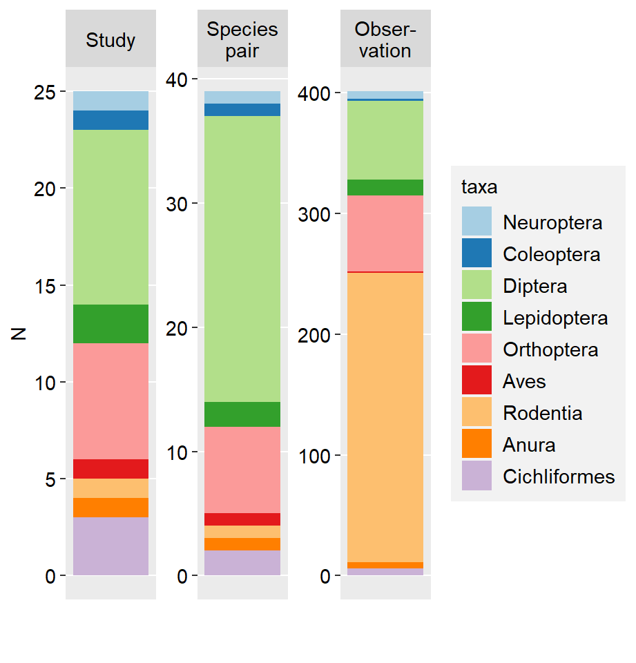

```r
## Plot ###
plot.sum <- ggplot(
  # Make tidy summary data
  summary %>%
  gather(key = metrics, value = N, -c(taxa)) %>%
  # Order metrics
  within(
    metrics <- ordered(
      metrics,
      levels = c("Study", "Species pair", "Obser- vation")
      )
    ),
  aes(x = "", y = N, fill = taxa)) +
  geom_bar(width = 1, stat = "identity") +
  scale_fill_brewer(palette = "Paired") +
  facet_wrap(
    scale = "free", "metrics",
    # strip text into two lines
    labeller = label_wrap_gen(width = 8)
    ) +
  xlab("") +
  stackedbartheme

#+++++++++++++++++#
# Combine figures
#+++++++++++++++++#
# plot.all <- plot.phylo + plot.sum
plot.sum
```

```r
# ggsave(plot.sum, file = "../Plot/Species_composition.svg", height = 3.4, width = 4.5)
```

**Figure 1a**

## Taxonomic distribution of species-level moderator status

Summarised distributions of categorical species-level moderators in each taxon (order).

```r
metavars <- c("Reciprocal", "Distribution", "Hetero.sex")

meta.unique <- original.dat %>%
  distinct_at("species.pair", .keep_all = TRUE) %>%
  mutate_at(metavars, as.factor)

meta.all.sp <- meta.unique %>%
  group_by(taxa) %>%
  summarise(Total = length(species.pair))

for (i in metavars) {

  bind_rows(
    # At each taxon
    meta.unique %>%
      group_by_("taxa", i) %>%
      summarise(species = length(species.pair))
    ,
    # All taxon
    meta.unique %>%
      group_by_(i) %>%
      summarise(species = length(unique(species.pair))) %>%
      mutate(taxa = "Total")
    ) %>%
    ungroup %>%
    spread(key = i, value = "species") %>%
    mutate_all(~replace(., is.na(.), 0)) %>% # replace NA by 0
    as.data.frame %>%
    # All species pair at each taxon: summing columns
    mutate(Total = rowSums(.[2:(1+nlevels(meta.unique[, i]))])) %>%
    # Calc % of level 2 (i.e. male hetero, ...)
    mutate('%' = round(.[3]/Total*100, 1)) %>%
    rename(!!paste0(levels(meta.unique[, i])[2], "%") := "%") %>%
    # Table output
    kable("html", digits = 3, caption = i) %>%
    kable_styling("striped", position = "left") %>%
    print()

}
```

Reciprocal

| taxa | Inviable | Viable | Total | Viable% |
| --- | --- | --- | --- | --- |
| Anura | 0 | 1 | 1 | 100.0 |
| Aves | 0 | 1 | 1 | 100.0 |
| Cichliformes | 1 | 1 | 2 | 50.0 |
| Coleoptera | 0 | 1 | 1 | 100.0 |
| Diptera | 11 | 12 | 23 | 52.2 |
| Lepidoptera | 1 | 1 | 2 | 50.0 |
| Neuroptera | 0 | 1 | 1 | 100.0 |
| Orthoptera | 2 | 5 | 7 | 71.4 |
| Rodentia | 1 | 0 | 1 | 0.0 |
| Total | 16 | 23 | 39 | 59.0 |

Distribution

| taxa | Allopatry | Overlap | Total | Overlap% |
| --- | --- | --- | --- | --- |
| Anura | 0 | 1 | 1 | 100.0 |
| Aves | 1 | 0 | 1 | 0.0 |
| Cichliformes | 1 | 1 | 2 | 50.0 |
| Coleoptera | 0 | 1 | 1 | 100.0 |
| Diptera | 19 | 4 | 23 | 17.4 |
| Lepidoptera | 0 | 2 | 2 | 100.0 |
| Neuroptera | 0 | 1 | 1 | 100.0 |
| Orthoptera | 3 | 4 | 7 | 57.1 |
| Rodentia | 1 | 0 | 1 | 0.0 |
| Total | 25 | 14 | 39 | 35.9 |

Hetero.sex

| taxa | Female | Male | <NA> | Total | Male% |
| --- | --- | --- | --- | --- | --- |
| Anura | 0 | 1 | 0 | 1 | 100.0 |
| Aves | 1 | 0 | 0 | 1 | 0.0 |
| Cichliformes | 0 | 0 | 2 | 0 |  |
| Coleoptera | 0 | 1 | 0 | 1 | 100.0 |
| Diptera | 0 | 23 | 0 | 23 | 100.0 |
| Lepidoptera | 2 | 0 | 0 | 2 | 0.0 |
| Neuroptera | 0 | 1 | 0 | 1 | 100.0 |
| Orthoptera | 0 | 7 | 0 | 7 | 100.0 |
| Rodentia | 0 | 1 | 0 | 1 | 100.0 |
| Total | 3 | 34 | 2 | 37 | 91.9 |

## Data used in meta-regression (all metadata available)

```r
full_join(
  # All species pair
  original.dat %>%
    select(c("taxa", "species.pair")) %>%
    distinct_all() %>%
    group_by(taxa) %>%
    summarise('All species' = length(species.pair)),
  # Species pair used in meta-regression
  original.dat %>%
    filter(!is.na(sex.determination), !is.na(Genet.divergence)) %>%
    select(c("taxa", "species.pair")) %>%
    distinct_all() %>%
    group_by(taxa) %>%
    summarise('Metadata available' = length(species.pair))
  ) %>%
  mutate_all(~replace(., is.na(.), 0)) %>% # replace NA by 0
  kable("html", caption = "Numbers of all species pairs, and species pairs used in meta-regression
") %>%
  kable_styling("striped", position = "left")
```

Numbers of all species pairs, and species pairs used in meta-regression

| taxa | All species | Metadata available |
| --- | --- | --- |
| Anura | 1 | 1 |
| Aves | 1 | 1 |
| Cichliformes | 2 | 0 |
| Coleoptera | 1 | 1 |
| Diptera | 23 | 23 |
| Lepidoptera | 2 | 2 |
| Neuroptera | 1 | 1 |
| Orthoptera | 7 | 4 |
| Rodentia | 1 | 1 |

Two fish and three orthoptera species-pairs were not used in meta-regression and Bayesian phylogenetic mixed models because of the lack of data for genetic distance or sex-determination system (fish, *Haplochromis burtoni* × *H. nubilus* and *Pundamilia nyererei* × *P. pundamilia*; orthoptera, *Chorthippus parallelus erythropus* × *C. parallelus parallelus*, *Gryllus armatus* × *G. rubens* and *Laupala kohalensis* × *L. paranigra*). We did not assign value of the heterogametic sex in cichlid fishes that undergo frequent evolutionary changes in sex-determination system [Yoshida et al. 2011](https://dx.plos.org/10.1371/journal.pgen.1002203).

## Allign parental species according to trait values

Currently, dataset is composed of  
‘species 1’ and ‘species 2,’ ordered alphabetically, and ‘hybrid12’ (sp1 mother & sp2 father) and ‘hybrid 21’ (sp2 mother & sp1 father)  
To investigate paternal effect in hybrids using difference in mean trait value between reciprocal cross, it’s better to allign species with larger trait value (*spLL<sub>M</sub>*) and smaller value (*spSS<sub>M</sub>*) in each traits. Name of hybrids will be changed according to change in names of parental species (*hybridLS<sub>M</sub>* & *hybridSL<sub>M</sub>*).

```r
#+++++++++++++++++++++++++++++++++++++++++++++++++#
# sp1 >= sp2 in phenotypic mean
#+++++++++++++++++++++++++++++++++++++++++++++++++#
# extract
sp1sp2.mean <- original.dat %>%
  filter(Mn.sp1 >= Mn.sp2) # filtering according to mean trait value of parentals
# change column name from sp1 or sp2 -> spL or spS
names(sp1sp2.mean) <- gsub("1", "L", names(sp1sp2.mean))
names(sp1sp2.mean) <- gsub("2", "S", names(sp1sp2.mean))

#+++++++++++++++++++++++++++++++++++++++++++++++++#
# sp1 < sp2 in phenotypic mean
#+++++++++++++++++++++++++++++++++++++++++++++++++#
# extract
sp2sp1.mean <- original.dat %>%
  filter(Mn.sp1 < Mn.sp2)
# change column name from sp1 or sp2 -> spS or spL
names(sp2sp1.mean) <- gsub("1", "S", names(sp2sp1.mean))
names(sp2sp1.mean) <- gsub("2", "L", names(sp2sp1.mean))

#+++++++++++++++++++++++++++++++++++++++++++++++++#
# combine dataset & sort by ES.ID
#+++++++++++++++++++++++++++++++++++++++++++++++++#
bind_rows(sp1sp2.mean, sp2sp1.mean) %>%
  arrange(ES.ID) %>%
  write.csv("../data/dat.mean.csv", quote=F,row.names = F)
```

Data set created here, `dat.mean.csv`, is used in calculating effect sizes for analyses investigating phenotypic mean and novelty in phenotypic means.

## Allign parental species according to phenotypic variation (CV)

To investigate paternal effect in hybrids using difference in coefficient of variation (CV) between reciprocal cross, it’s better to allign species with larger CV (*spLL<sub>V</sub>*) and smaller CV (*spSS<sub>V</sub>*) in each traits. Name of hybrids will be changed according to change in names of parental species (*hybridLS<sub>V</sub>* & *hybridSL<sub>V</sub>*).

```r
#+++++++++++++++++++++++++++++++++++++++++++++++++#
# sp1 >= sp2 in phenotypic variation (CV)
#+++++++++++++++++++++++++++++++++++++++++++++++++#
# extract
sp1sp2.var <- original.dat %>%
  filter(SD.sp1/Mn.sp1 >= SD.sp2/Mn.sp2) # filtering according to CV of parentals
# change column name from sp1 or sp2 -> spL or spS
names(sp1sp2.var) <- gsub("1", "L", names(sp1sp2.var))
names(sp1sp2.var) <- gsub("2", "S", names(sp1sp2.var))

#+++++++++++++++++++++++++++++++++++++++++++++++++#
# sp1 < sp2 in phenotypic variation (CV)
#+++++++++++++++++++++++++++++++++++++++++++++++++#
# extract
sp2sp1.var <- original.dat %>%
  filter(SD.sp1/Mn.sp1 < SD.sp2/Mn.sp2)
# change column name from sp1 or sp2 -> spS or spL
names(sp2sp1.var) <- gsub("1", "S", names(sp2sp1.var))
names(sp2sp1.var) <- gsub("2", "L", names(sp2sp1.var))

#+++++++++++++++++++++++++++++++++++++++++++++++++#
# combine dataset & sort by ES.ID
#+++++++++++++++++++++++++++++++++++++++++++++++++#
bind_rows(sp1sp2.var, sp2sp1.var) %>%
  arrange(ES.ID) %>%
  write.csv("../data/dat.CV.csv", quote=F,row.names = F)
```

Data set created here, `dat.CV.csv`, is used in calculating effect sizes for analyses investigating phenotypic variation and novelty in phenotypic variabilities.

## Simultaneously judge novel phenotype and variability expression

We categorised phenotypic novelty (novel or non-novel) and relative phenotypic variability (CV) compared to parents (smaller, intermediate, larger) at each trait.

```r
bind_rows(
  # Assess novel phenotype & variability expression in hyb12
  original.dat %>%
    drop_na(Mn.hyb12, SD.hyb12) %>%
    mutate(
      cross = "1x2",
      # Relative trait size
      relative.mean = ifelse(
        # Exceeding upper range
        Mn.hyb12 > Mn.sp1 & Mn.hyb12 > Mn.sp2,
        "Larger",
        ifelse(
          # Exceeding lower range
          Mn.hyb12 < Mn.sp1 & Mn.hyb12 < Mn.sp2,
          "Smaller",
          "Intermediate"
        )
      ),
      # Relative variability size
      relative.var = ifelse(
        # Exceeding upper range: 1
        SD.hyb12/Mn.hyb12 > SD.sp1/Mn.sp1 &
          SD.hyb12/Mn.hyb12 > SD.sp2/Mn.sp2,
        "Larger",
        ifelse(
          # Exceeding lower range: "Smaller"
          SD.hyb12/Mn.hyb12 < SD.sp1/Mn.sp1 &
            SD.hyb12/Mn.hyb12 < SD.sp2/Mn.sp2,
          "Smaller",
          "Intermediate"
        )
      )
    ),
  # Assess novel phenotype & variability expression in hyb12
  original.dat %>%
    drop_na(Mn.hyb21, SD.hyb21) %>%
    mutate(
      cross = "2x1",
      # Relative trait size
      relative.mean = ifelse(
        # Exceeding upper range: 1
        Mn.hyb21 > Mn.sp1 & Mn.hyb21 > Mn.sp2,
        "Larger",
        ifelse(
          # Exceeding lower range: "Smaller"
          Mn.hyb21 < Mn.sp1 & Mn.hyb21 < Mn.sp2,
          "Smaller",
          "Intermediate"
        )
      ) ,
      # Relative variability size
      relative.var = ifelse(
        # Exceeding upper range: 1
        SD.hyb21/Mn.hyb21 > SD.sp1/Mn.sp1 &
          SD.hyb21/Mn.hyb21 > SD.sp2/Mn.sp2,
        "Larger",
        ifelse(
          # Exceeding lower range: "Smaller"
          SD.hyb21/Mn.hyb21 < SD.sp1/Mn.sp1 &
            SD.hyb21/Mn.hyb21 < SD.sp2/Mn.sp2,
          "Smaller",
          "Intermediate"
        )
      )
    )
  ) %>%
  mutate(mean.novelty = ifelse(relative.mean == "Intermediate", "Nonnovel", "Novel")) %>%
  write.csv("../data/dat.novelty.csv", quote=F,row.names = F)
```

Data set created here, `dat.novelty.csv`, is used in investigating phenotypic variability of novel phenotype.

# Meta-analysis for phenotypic mean

We created data subset according to taxon (all taxon or insect only) and novelty in phenotypic means (all traits or non-novel traits - trait size of hybrids does not exceed size range of parents). We conduct identical analyses for full data and data subsets, and checked robustness of our results.

## Calculating effect sizes

To quantify phenotypic difference from *spSS<sub>M</sub>* to the other crosses, we calculated log response ratio (lnRR) from phenotypic mean of *spSS<sub>M</sub>* to those of the other crosses (*hybLS<sub>M</sub>* (*spLL* mother × *spSS* father), *hybSL<sub>M</sub>* (*spSS* mother × *spLL* father) and *spLL<sub>M</sub>*).  
Effecct size was calculated by using `escalc` function in `metafor` package

```r
# load phenotypic data
dat <- read.csv("../data/dat.mean.csv", head = TRUE)

# Order by taxon
dat$taxa <- ordered(
  dat$taxa,
  levels = c("Neuroptera", "Coleoptera", "Diptera", "Lepidoptera", "Orthoptera", "Aves", "Rodentia", "Anura", "Cichliformes")
  )

## Difference between hybrids and smaller species (spS) ###
mean.dif <- foreach(
  cr = c("hybLS", "hybSL", "spL"),
  .combine = `rbind`
  ) %do% {
    ## lnRR ###
    escalc(
      measure = "ROM",
      # N of hybrids
      n1i = dat[, paste("N", cr, sep = ".")],
      # N of parentals
      n2i = dat[, "N.spS"],
      # Mean of hybrids
      m1i = dat[, paste("Mn", cr, sep = ".")],
      # Mean of parentals
      m2i = dat[, "Mn.spS"],
      # SD of hybrids
      sd1i = dat[, paste("SD", cr, sep = ".")],
      # SD of parentals
      sd2i = dat[, "SD.spS"],
      data = dat
      ) %>%
      rename(lnRR.es = yi, lnRR.sv = vi) %>%
    # indicate type of hybrid
    mutate(cross = cr)
    } %>%
  drop_na(lnRR.sv) %>%
  arrange(ES.ID) %>%
  left_join(., dat)

# Dataset able to compare reciprocal crosses
write.csv(
  mean.dif %>%
    filter(Reciprocal == "Viable"),
  "../data/mean.ES.general.csv", row.names = F
  )
```

## Funnel plots

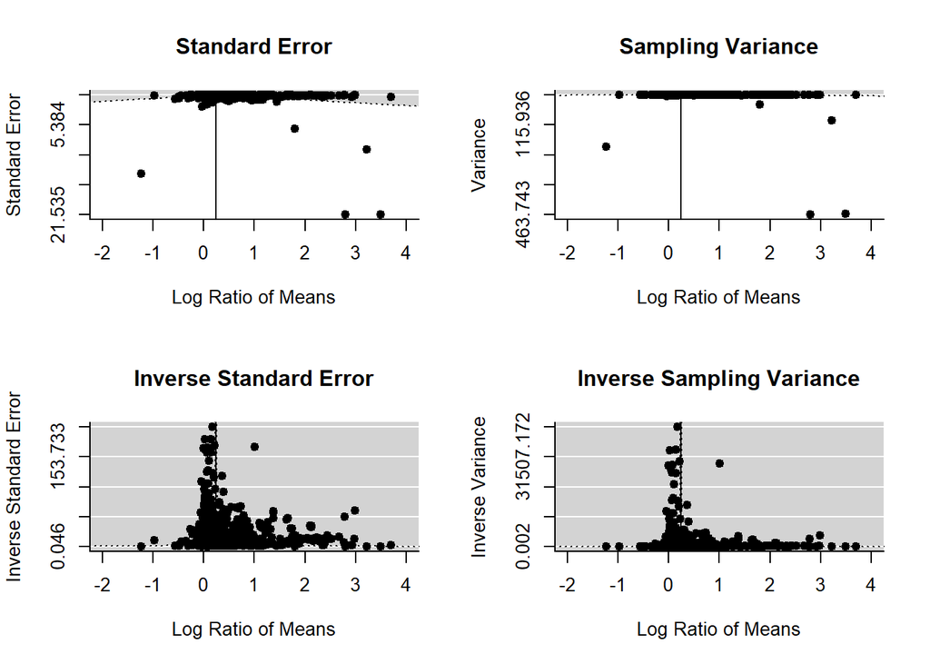

```r
res <- rma(
  yi = lnRR.es, vi = lnRR.sv,
  data = mean.dif, method="FE"
  )

## set up 2x2 array for plotting
par(mfrow=c(2,2))

## draw funnel plots
funnel(res, main="Standard Error", xlim = c(-2, 4))
funnel(res, yaxis="vi", main="Sampling Variance", xlim = c(-2, 4))
funnel(res, yaxis="seinv", main="Inverse Standard Error", xlim = c(-2, 4))
funnel(res, yaxis="vinv", main="Inverse Sampling Variance", xlim = c(-2, 4))
```

### Check data

Checked effect sizes with extremely high/low standard error (SE > 1.2 | 1/SE > 140) and confirmed that those data were correctly imported.

```r
outliers <- mean.dif %>%
  # vi (sampling variance)
  mutate(SE = sqrt(lnRR.sv)) %>%
  arrange(desc(SE)) %>%
  filter(SE > 1.2 | 1/SE > 140) %>%
  select(ES.ID, Study.name, SE, cross, Reciprocal, trait, Cross.ID) %>%
  mutate_if(is.numeric, round, 3)

outliers %>%
  kable("html", digits = 3, caption = "Effect sizes with extremely high/low standard error (SE > 1.2 | 1/SE > 140)") %>%
  kable_styling("striped", position = "left") %>%
  scroll_box(width = "100%", height = "500px")
```

Effect sizes with extremely high/low standard error (SE > 1.2 | 1/SE > 140)

| ES.ID | Study.name | SE | cross | Reciprocal | trait | Cross.ID |
| --- | --- | --- | --- | --- | --- | --- |
| ES320 | Musolf et al_2015 | 21.535 | spL | Inviable | Frequ Modulated Downsweep_FAC1_2 | musculus.3 |
| ES320 | Musolf et al_2015 | 21.470 | hybSL | Inviable | Frequ Modulated Downsweep_FAC1_2 | musculus.3 |
| ES253 | Musolf et al_2015 | 14.218 | hybLS | Inviable | Complex 2_FAC2_1 | musculus.3 |
| ES253 | Musolf et al_2015 | 9.883 | spL | Inviable | Complex 2_FAC2_1 | musculus.3 |
| ES147 | Musolf et al_2015 | 6.075 | spL | Inviable | U Shaped Inverted_FAC1_2 | musculus.1 |
| ES123 | Musolf et al_2015 | 2.073 | hybLS | Inviable | Complex 2_FAC2_1 | musculus.1 |
| ES367 | Suvanto et al_1994 | 1.761 | hybLS | Viable | inhbt_IPI | Drosophila_borealis_Drosophila_virilis |
| ES371 | Suvanto et al_1994 | 1.538 | spL | Inviable | inhbt_PL | Drosophila_montana_Drosophila_virilis |
| ES367 | Suvanto et al_1994 | 1.375 | hybSL | Viable | inhbt_IPI | Drosophila_borealis_Drosophila_virilis |
| ES125 | Musolf et al_2015 | 1.276 | spL | Inviable | Complex 2_FAC1_4 | musculus.1 |
| ES123 | Musolf et al_2015 | 1.231 | spL | Inviable | Complex 2_FAC2_1 | musculus.1 |
| ES388 | Tomaru&Oguma_1994 | 0.007 | hybSL | Inviable | IPI | Drosophila_triauraria_Drosophila_biauraria |
| ES389 | Tomaru&Oguma_1994 | 0.006 | spL | Viable | IPI | Drosophila_quadraria_Drosophila_biauraria |
| ES055 | Coyne.et.al_1991 | 0.006 | hybSL | Viable | Tibia length | pn_j_irX85 |
| ES036 | Coyne_1983 | 0.006 | spL | Inviable | WL | BGxMutant |
| ES039 | Coyne_1983 | 0.006 | hybLS | Viable | WL | BGxSPD(wildtype) |
| ES036 | Coyne_1983 | 0.006 | hybLS | Inviable | WL | BGxMutant |
| ES390 | Tomaru&Oguma_1994 | 0.006 | spL | Inviable | IPI | Drosophila_quadraria_Drosophila_subauraria |
| ES039 | Coyne_1983 | 0.006 | hybSL | Viable | WL | BGxSPD(wildtype) |
| ES039 | Coyne_1983 | 0.006 | spL | Viable | WL | BGxSPD(wildtype) |
| ES388 | Tomaru&Oguma_1994 | 0.006 | spL | Inviable | IPI | Drosophila_triauraria_Drosophila_biauraria |
| ES387 | Tomaru&Oguma_1994 | 0.005 | spL | Viable | IPI | Drosophila_triauraria_Drosophila_quadraria |
| ES391 | Tomaru&Oguma_1994 | 0.005 | spL | Viable | IPI | Drosophila_biauraria_Drosophila_subauraria |
| ES390 | Tomaru&Oguma_1994 | 0.005 | hybLS | Inviable | IPI | Drosophila_quadraria_Drosophila_subauraria |

Because those outliers did not affect meta-analytic model convergence, we did not exclude those data.

## Judging novelty in phenotypic means

We judged if hybrids exhibit larger or smaller trait size than both parents (see Fig. 3c)

```r
# load spLS files
dat <- read.csv("../data/dat.mean.csv", head = TRUE)

#+++++++++++++++++++++++++++++++++++++++++++++++++++++++#
# Difference between larger species (spL) and hybrids
#+++++++++++++++++++++++++++++++++++++++++++++++++++++++#

for (i in c("spL")) { # identify type of hybrids
  for (cr in c("hybLS", "hybSL")) { # identify type of parentals
    assign(
      paste(cr, i, sep = "_"),
        ## lnRR ###
        escalc(
          measure = "ROM",
          # N of hybrids
          n1i = dat[, paste("N", i, sep = ".")],
          # N of parentals
          n2i = dat[, paste("N", cr, sep = ".")],
          # Mean of hybrids
          m1i = dat[, paste("Mn", i, sep = ".")],
          # Mean of parentals
          m2i = dat[, paste("Mn", cr, sep = ".")],
          # SD of hybrids
          sd1i = dat[, paste("SD", i, sep = ".")],
          # SD of parentals
          sd2i = dat[, paste("SD", cr, sep = ".")],
          data = dat
          ) %>%
        rename(lnRR.es = yi, lnRR.sv = vi) %>%
        select(ES.ID, contains("lnRR")) %>%
        mutate(
          # direction of transgressve segregation - greater than parent
          direction = "+",
          # SE for logistic distribution, for the weighted binomial regression
          # SE = pi/sqrt(3*(n_e + n_c))
          SE = pi/sqrt(3*(
            dat[, paste("N", i, sep = ".")] + dat[, paste("N", cr, sep = ".")]
          ))
        )
    )
  }
}

#+++++++++++++++++++++++++++++++++++++++++++++++++++++++#
# Difference between hybrids and smaller species (spS)
#+++++++++++++++++++++++++++++++++++++++++++++++++++++++#

for (i in c("hybLS", "hybSL")) { # identify type of hybrids
  for (cr in c("spS")) { # identify type of parentals
    assign(
      paste(i, cr, sep = "_"),
        ## lnRR ###
        escalc(
          measure = "ROM",
          # N of hybrids
          n1i = dat[, paste("N", i, sep = ".")],
          # N of parentals
          n2i = dat[, paste("N", cr, sep = ".")],
          # Mean of hybrids
          m1i = dat[, paste("Mn", i, sep = ".")],
          # Mean of parentals
          m2i = dat[, paste("Mn", cr, sep = ".")],
          # SD of hybrids
          sd1i = dat[, paste("SD", i, sep = ".")],
          # SD of parentals
          sd2i = dat[, paste("SD", cr, sep = ".")],
          data = dat
          ) %>%
          rename(lnRR.es = yi, lnRR.sv = vi) %>%
        select(ES.ID, contains("lnRR")) %>%
        mutate(
          # direction of transgressve segregation - smaller than parent
          direction = "-",
          # SE for logistic distribution, for the weighted binomial regression
          # SE = pi/sqrt(3*(n_e + n_c))
          SE = pi/sqrt(3*(
            dat[, paste("N", i, sep = ".")] + dat[, paste("N", cr, sep = ".")]
          ))
        )
    )
  }
}

#+++++++++++++++++++++++++++++++++++++++++++++++++++++++#
# Data output
#+++++++++++++++++++++++++++++++++++++++++++++++++++++++#

bind_rows(
  ## Difference with mother species ###
  bind_rows(hybLS_spL, hybSL_spS) %>%
    mutate(parental = "Mother"),
  ## Difference with father species ###
  bind_rows(hybLS_spS, hybSL_spL) %>%
    mutate(parental = "Father")
  ) %>%
  drop_na(lnRR.sv) %>%
  left_join(., dat) %>%
  # Assign novel phenotype to 1, non-novel phenotype to 0 for each effect size
  mutate(Novelty = ifelse(lnRR.es < 0, 1, 0)) %>%
  ## Join with metadata ###
  left_join(
    ., read.xlsx("../data/original.data.xlsx", sheet = "Species.level.moderators")
    ) %>%
  mutate_at(vars(contains("divergence")), as.numeric) %>%
  mutate_at(vars(contains("divergence")), scale) %>%
  as.data.frame %>%
  select(-trait) %>%
  mutate_at("taxa", as.factor) %>%
  within(levels(Novelty) <- c("No", "Novel phenotypic means")) %>%
  within(
    taxa <- ordered(
      taxa,
      levels = c("Neuroptera", "Coleoptera", "Diptera", "Lepidoptera", "Orthoptera", "Aves", "Rodentia", "Anura", "Cichliformes")
      )
    ) %>%
  # Remove rows without any metadata
  drop_na(Hetero.sex, Pheno.divergence, trait.type, Genet.divergence) %>%
  # Insect or no
  mutate(
    insect = ifelse(taxa %in% c("Aves", "Rodentia", "Anura", "Cichliformes"), "no", "insect"),
  ) %>%
  write.csv("../data/mean.ES.Novelty.csv", row.names = F)
```

## Reload data & Prepare phylogenetic tree

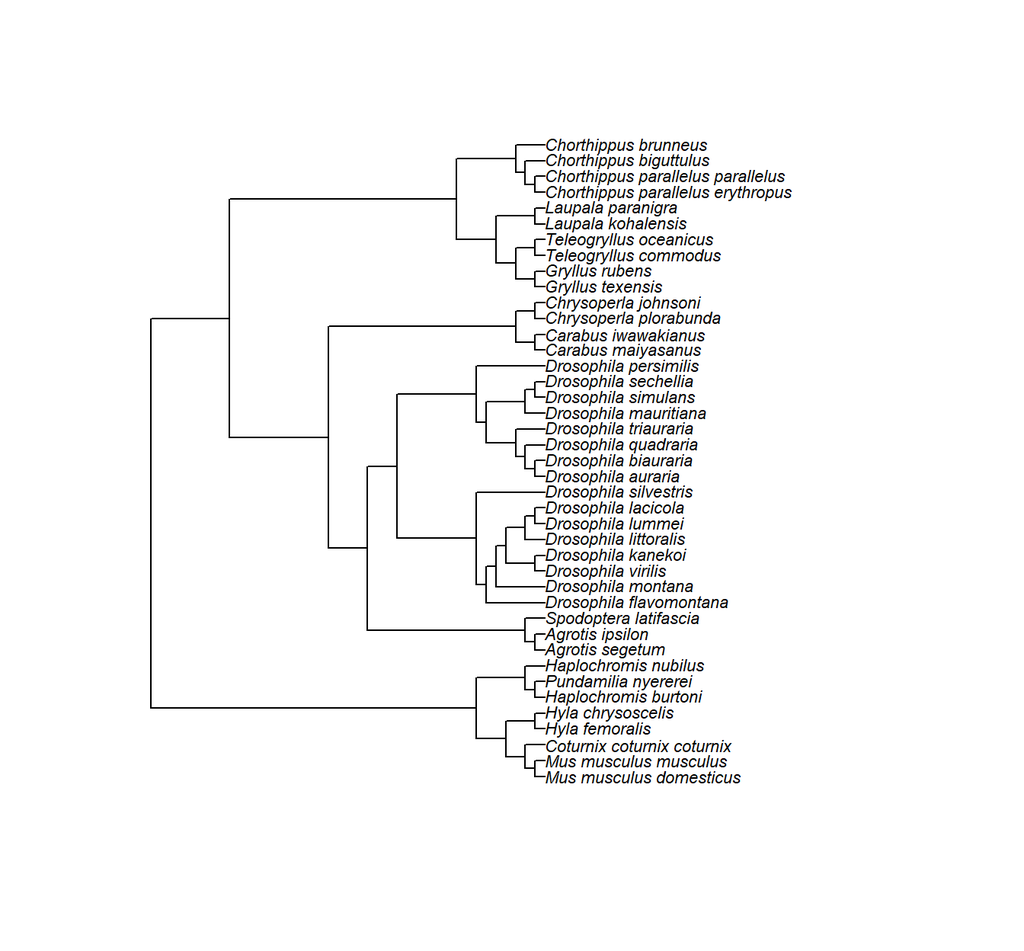

Figure S1. Phylogenetic tree used in meta-analysis for phenotypic mean, which was based on tree of the parental species with larger phenotypic mean

```r
# Load effect sizes
mean.dif <- read.csv("../data/mean.ES.general.csv", head = TRUE) %>%
  # indicate dataset including novel phenotype
  mutate(data.type = "Alltraits")

# All trait observation irrespective of phenotypic novelty
All <- read.csv("../data/mean.ES.Novelty.csv", head = TRUE) %>%
  filter(lnRR.es < 0) %>%
  distinct(ES.ID)

# Trait observation of non-novel phenotypes
Nonovel <- read.csv("../data/mean.ES.general.csv", head = TRUE) %>%
  filter(!(ES.ID %in% All$ES.ID)) %>%
  # indicate dataset without novel phenotype
  mutate(data.type = "Nonnoveltraits")

# combine dataset with/without novel phenotype
Novel.Nonnovel <- bind_rows(mean.dif, Nonovel) %>%
  mutate(metaunit =  str_c(data.type, cross, sep = "_"))%>%
  # Use observations with both reciprocal crosses
  drop_na(contains("Mn"), contains("SD")) %>%
  # Insect or no
  mutate(
    insect = ifelse(taxa %in% c("Cichliformes", "Anura", "Aves", "Rodentia"), "no", "insect"),
  )


#+++++++++++++++++++++++++++++++++++++++++++++++#
# Phylogeny
#+++++++++++++++++++++++++++++++++++++++++++++++#

# # matching names from open tree taxonomy
# taxa <- tnrs_match_names(
#   names = levels(mean.dif$spL.name) %>%
#     str_replace_all("_", " "),
#   context_name = "Animals"
#   )
#
# # which names return more than 1 match?
# inspect(taxa, ott_id = taxa$ott_id[taxa$number_matches != 1])
#
# # fixing names with more than 1 match
# taxa[taxa$number_matches != 1, ] <-
#   inspect(taxa, ott_id = taxa$ott_id[taxa$number_matches != 1])[1, ]
#
# tree <- tol_induced_subtree(ott_ids = taxa$ott_id)
# tree$tip.label %<>%
#   strip_ott_ids(remove_underscores=TRUE)
#
# print("Original tree from OTL")
# plot(tree, no.margin=TRUE)
#
# # randomly solve non-binary phylogeny
# set.seed(6)
# bin.tree <- multi2di(tree, random = T)
# print("Randomly solved phylogeny")
# plot(bin.tree)
#
# # correlation matrix to fit to the model
# bin.tree$tip.label <- bin.tree$tip.label %>%
#   as.factor()
#
# levels(bin.tree$tip.label) <- levels(mean.dif$spL.name) # making sure names match
# bin.tree$tip.label <- as.character(bin.tree$tip.label) # converting names back to character
#
# write.tree(bin.tree, file= "../data/phylo.mean.tre")

# compute branch lengths of tree
phylo_branch <- read.tree(file = "../data/phylo.mean.tre") %>%
  compute.brlen(bin.tree, method = "Grafen", power = 1)

# saving phylogeneic matrix
phylo_cor <- vcv(phylo_branch, cor = T)

# Note one of the tips is called "Lates calcarifer (estimated)"
phylo_branch$node.label <- NULL

# Plot tree
plot.phylo(phylo_branch, cex = 0.7)
```

Phylogenetic tree created based on taxonomic tree on [Open Tree of Life](https://tree.opentreeoflife.org/opentree/argus/opentree12.3@ott93302). Non-binary tree was randomly solved. We used packages `rotl`, `ape` and `phytools` on R.

## Dominance in phenotypic means

Compare midparent and hybrids by comparing difference from *spSS<sub>M</sub>* phenotypic mean to midparent-value $\frac{spLL_M+spSS_M}{2}$ and to hybrids’ phenotypic mean.

- lnRR of midparent to *spSS<sub>M</sub>*: $\ln\frac{spLL_M+spSS_M}{2spSS_M}$
- lnRR of hybrids to *spSS<sub>M</sub>*: $\ln\frac{hybrid}{spSS_M}$

As the variance of $\ln\frac{spLL_M+spSS_M}{2spSS_M}$, we use the variance of $\ln\frac{spLL_M}{spSS_M}$ for simplicity

We statistically compared those effect sizes through the formal meta-regression by using `rma.mv` function of R package `metafor`

All meta-analytic models included following Random effects estimates:

- `Study.ID`: Primary studies. Denoted as **Study**
- `Cross.ID`: Parental strain used in the crossing. Discriminate intraspecific populations. Denoted as **crossed strain**
- `spL.name`: Phylogeny of parental species (*spLL<sub>M</sub>*). Denoted as **species with phylogeny**

```r
#++++++++++++++++++++++++++++++++++++++++++++++++++++#
# Calculate midparent
#++++++++++++++++++++++++++++++++++++++++++++++++++++#
midparent <- Novel.Nonnovel %>%
  # Divide mean by 2 in spL whereas hybrids are constant
  mutate(
    lnRR.midparent.es =
      ifelse(
        cross == "spL",
        log(((Mn.spL + Mn.spS)/2)/Mn.spS), lnRR.es
        )
    # Divide variance by 4 in spL whereas hybrids are constant
    ) %>%
  mutate_at("cross", as.factor) %>%
  within(levels(cross) <- c("hybLS", "hybSL", "midparent"))


#+++++++++++++++++++++++++++++++++++++++++++++++++++#
# Compare midparent and hybrids by meta-regresson
#+++++++++++++++++++++++++++++++++++++++++++++++++++#
for (tr in c("Alltraits", "Nonnoveltraits")) {
  for (taxon in c("alltaxon", "insect")) {

    if (taxon == "alltaxon") {
      dat <- midparent %>%
        filter(data.type == tr)
    } else {
      dat <- midparent %>%
        filter(data.type == tr, insect == taxon)
    }

    # ## phylogenetic random regresson comparing with midparent ###
    # midparent.compare <- rma.mv(
    #   yi = lnRR.midparent.es,
    #   V = lnRR.sv,
    #   data = dat,
    #   method = "REML",
    #   random = list(~1 | spL.name, ~1 | Study.ID, ~1 | Cross.ID, ~1 | ES.ID),
    #   R = list(spL.name = phylo_cor),
    #   mods = ~ relevel(cross, ref = "midparent")
    #   )
    # ## Save model ###
    # saveRDS(
    #   midparent.compare,
    #   file = paste("../Analysis/Mean.midparent.compare", tr, taxon, "obj", sep = ".")
    #   )

    ## Load model ###
    midparent.compare <- readRDS(
      paste("../Analysis/Mean.midparent.compare", tr, taxon, "obj", sep = ".")
      )
    assign(
      paste("Dominance", tr, taxon, sep = "."),
      midparent.compare %>%
        get_reg() %>%
        # Show dataset name
        within(Dataset <- c(paste(tr, taxon), rep("", length(.$Estimate)-1))) %>%
        # Rename fixed effects
        within('Fixed effects' <- c("", "midparent (intrcpt)", "hybLS", "hybSL")) %>%
        # Difference of each cross from midparent in %
        mutate('Comparison with midparent' = c(
          rep("", 2),
          paste(
            round(
            100*(exp(midparent.compare$beta[1]+midparent.compare$beta[2])            -exp(midparent.compare$beta[1])), # hybrid LS
            2),
            "% larger"
            ),
          paste(
            round(
            100*(exp(midparent.compare$beta[1]+midparent.compare$beta[3])-exp(midparent.compare$beta[1])), # hybrid SL
            2),
            "% larger"
            )
          ))
      )

    # ## Meta-analysis for midparent to plot band ###
    # midparent.random <- rma.mv(
    #   yi = lnRR.midparent.es,
    #   V = lnRR.sv,
    #   data = dat %>% filter(cross == "midparent"),
    #   method = "REML",
    #   random = list(~1 | spL.name, ~1 | Study.ID, ~1 | Cross.ID, ~1 | ES.ID),
    #   R = list(spL.name = phylo_cor)
    #   )
    # ## Save model ###
    # saveRDS(
    #   midparent.random,
    #   file = paste("../Analysis/Mean.midparent", tr, taxon, "obj", sep = ".")
    #   )

  }
}

bind_rows(
  Dominance.Alltraits.alltaxon, Dominance.Nonnoveltraits.alltaxon,
  Dominance.Alltraits.insect, Dominance.Nonnoveltraits.insect
  ) %>%
  kable("html", digits = 3, caption = "Table S3. Results of meta-analysis investigating dominance in phenotypic means using full dataset or data subsets") %>%
  kable_styling("striped", position = "left") %>%
  scroll_box(width = "100%", height = "500px")
```

Table S3. Results of meta-analysis investigating dominance in phenotypic means using full dataset or data subsets

Dataset

Fixed effects

Estimate

LowerCI

UpperCI

I2[total]

%I2[species with phylogeny]

%I2[study]

%I2[crossed strain]

%I2[residual]

P

significance

Comparison with midparent

Alltraits alltaxon

99.7%

38.8%

1.1%

0%

59.8%

midparent (intrcpt)

0.578

0.266

0.890

<0.001

hybLS

-0.073

-0.079

-0.067

<0.001

-12.53 % larger

hybSL

-0.100

-0.106

-0.093

<0.001

-16.9 % larger

Nonnoveltraits alltaxon

99.7%

34.9%

1.3%

0%

63.5%

midparent (intrcpt)

0.677

0.370

0.984

<0.001

hybLS

-0.142

-0.149

-0.134

<0.001

-26 % larger

hybSL

-0.189

-0.196

-0.181

<0.001

-33.84 % larger

Alltraits insect

99.6%

0%

10%

0%

89.6%

midparent (intrcpt)

0.396

0.306

0.486

<0.001

hybLS

-0.073

-0.079

-0.066

<0.001

-10.42 % larger

hybSL

-0.100

-0.106

-0.094

<0.001

-14.15 % larger

Nonnoveltraits insect

99.5%

0%

9.1%

0%

90.4%

midparent (intrcpt)

0.494

0.395

0.594

<0.001

hybLS

-0.142

-0.150

-0.134

<0.001

-21.69 % larger

hybSL

-0.190

-0.198

-0.182

<0.001

-28.36 % larger

## Univarate meta-analysis for each cross

Quantify and visualise overall trend of phenotypic mean of hybrids compared to parents  
Meta-analysis was repeated for subset data - including only non-novel phenotypes, only insects, and non-novel phenotypes in insects  
Meta-analysis was conducted by using `rma.mv` function in `metafor` package

*Confidential interval : thick line

*Prediction interval : thin line

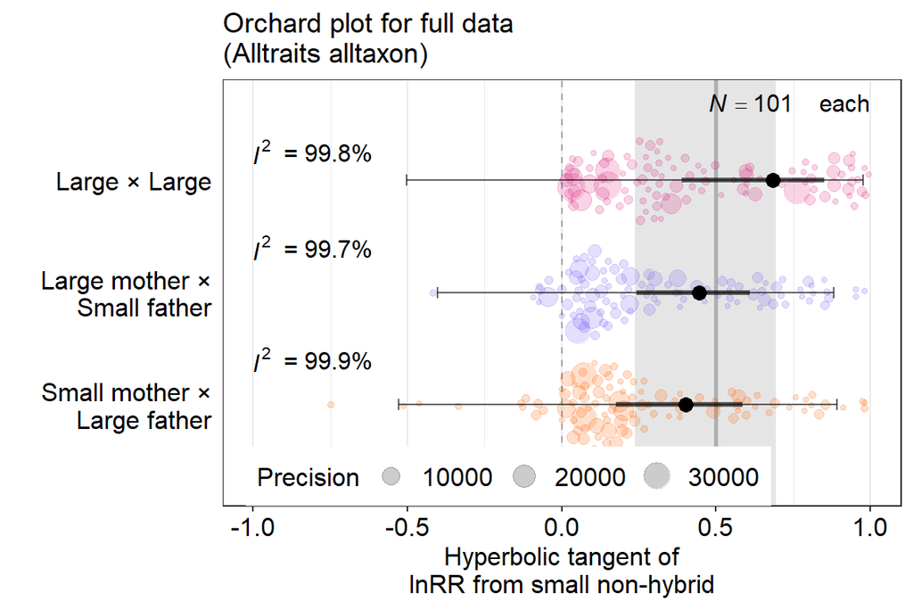

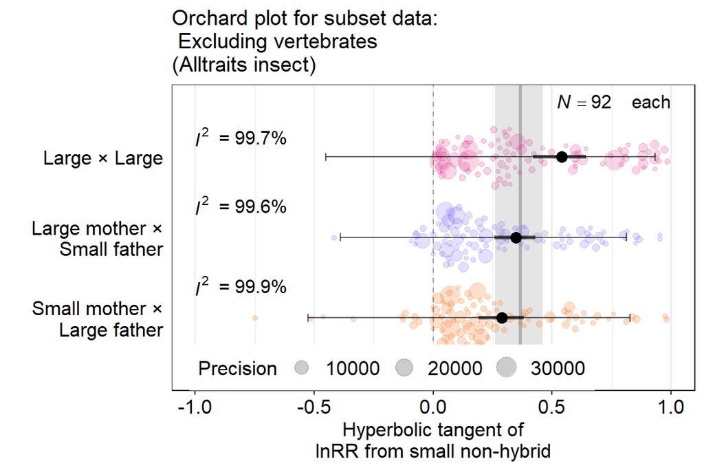

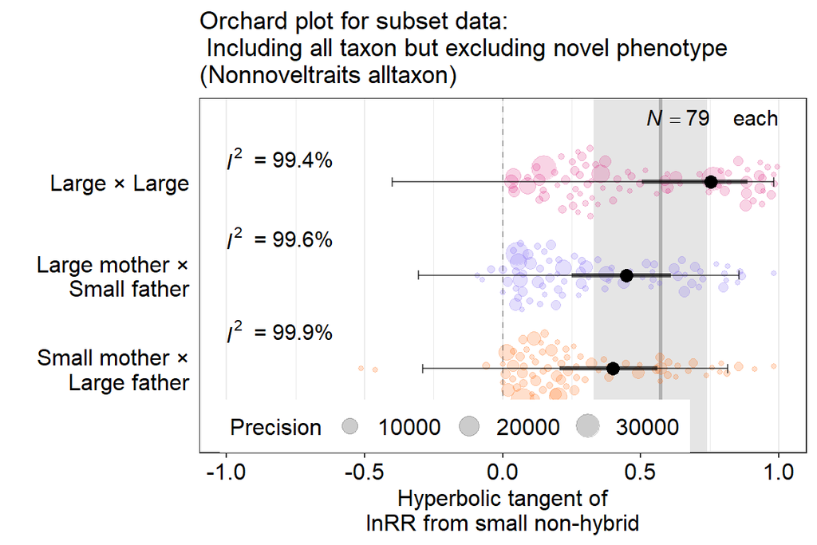

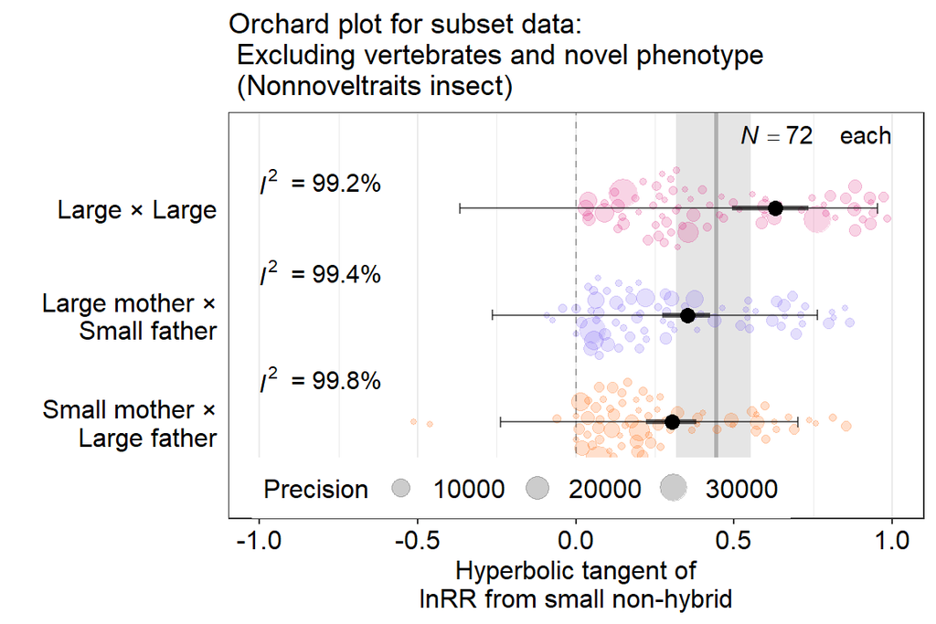

```r
cap <- data.frame(
  Description = c(
    "Orchard plot for full data \n(Alltraits alltaxon)",
    "Orchard plot for subset data:\n Excluding vertebrates \n(Alltraits insect)",
    "Orchard plot for subset data:\n Including all taxon but excluding novel phenotype \n(Nonnoveltraits alltaxon)",
    "Orchard plot for subset data:\n Excluding vertebrates and novel phenotype\n (Nonnoveltraits insect)"
    )
  ) %>%
  mutate_all(as.character)
row.names(cap) <- c("Alltraits.alltaxon", "Alltraits.insect", "Nonnoveltraits.alltaxon", "Nonnoveltraits.insect")

for (tr in c("Alltraits", "Nonnoveltraits")) {
  for (taxon in c("alltaxon", "insect")) {

    if (taxon == "alltaxon") {
      dat.plot <- Novel.Nonnovel %>%
        filter(data.type == tr)
    } else {
      dat.plot <- Novel.Nonnovel %>%
        filter(data.type == tr, insect == taxon)
    }

    res.ma <- foreach(
      cr = c("spL", "hybLS", "hybSL"), .combine = `rbind`
      ) %do% {

      # # Phylogenetic random meta-analysis
      # phyl.random <- rma.mv(
      #   yi = lnRR.es, V = lnRR.sv,
      #   data = dat.plot %>%
      #     filter(cross == cr),
      #   method = "REML",
      #   random = list(
      #     ~1 | spL.name, ~1 | Study.ID, ~1 | Cross.ID, ~1 | ES.ID
      #     ),
      #   R = list(spL.name = phylo_cor)
      #   )
      # saveRDS(phyl.random,
      #   file = paste("../Analysis/Mean.meta", tr, taxon, cr, "obj", sep = "."))

      # creating summary table of results
      readRDS(
        paste("../Analysis/Mean.meta", tr, taxon, cr, "obj", sep = ".")
        ) %>%
          get_pred() %>%
          as.data.frame() %>%
          mutate(
            N = length(dat$ES.ID),
            # I2 = I2(phyl.random)["I2_total"] %>% round(3),
            cross = cr # indicate cross (spL, hybLS, hybSL)
            ) %>%
        as.data.frame() %>%
        within('Dataset' <- c(paste(tr, taxon), "", "")) %>%  # dataset name in first row
        return()
        }

    # Rename crossing names
    res.ma$cross <- c("Large × Large", "Large mother ×\nSmall father", "Small mother ×\nLarge father")
    dat.plot$cross <- factor(dat.plot$cross, levels = c("spL", "hybLS", "hybSL"))
    levels(dat.plot$cross) <- c("Large × Large", "Large mother ×\nSmall father", "Small mother ×\nLarge father")
    # Bind result of all crosses at each dataset
    assign(paste("res.ma", tr, taxon, sep = "."), res.ma)

    ## Midparent estimate & CI ###
    midparent.ma.2 <- readRDS(
      paste("../Analysis/Mean.midparent", tr, taxon, "obj", sep = ".")
      ) %>%
      # Prediction interval of midparent
      get_pred() %>%
      as.data.frame()

    # creating a forest plot
    plot.metamean <- ggplot(data = res.ma, aes(x = tanh(Estimate), y = cross)) +
      scale_y_discrete(
        limits = c("Small mother ×\nLarge father", "Large mother ×\nSmall father", "Large × Large"),
        expand = c(0.05, 0.8)
        ) +
      scale_x_continuous(limits = c(-1, 1), breaks = seq(-1, 1, by = 0.5)) +
      ## Midparent CI ###
      geom_rect(
        aes(
          xmin = tanh(midparent.ma.2$LowerCI),
          xmax = tanh(midparent.ma.2$UpperCI),
          ymin = -Inf, ymax = Inf
          ),
        fill="Grey 90"
        ) +
      ## Midparent estimate ###
      geom_vline(
        xintercept = tanh(midparent.ma.2$Estimate), colour = "grey20",
        alpha = 0.3, size = 1
        ) +
      ## Orchard plot ###
      geom_quasirandom(
        data = dat.plot,
        aes(x = tanh(lnRR.es), y = cross, size = 1/lnRR.sv, color = cross),
        alpha = 0.2, groupOnX = FALSE
        ) +
      scale_color_manual(values = c("#DC267F", "#785EF0", "#FE6100")) +
      # Delete legend for colors
      guides(fill = "none", colour = "none") +
      # Confidential interval : thicker line
      geom_errorbarh(
        aes(xmin = tanh(LowerCI), xmax = tanh(UpperCI)),
        height = 0, size = 1.2, alpha = 0.6
        ) +
      # Prediction interval : thinner line
      geom_errorbarh(
        aes(xmin = tanh(lowerPR), xmax = tanh(upperPR)),
        height = 0.1, size = 0.5, alpha = 0.6
        ) +
      geom_vline(xintercept = 0, linetype = 2, colour = "black", alpha = 0.3) +
      ## Estimate ###
      geom_point(size = 3, shape = 21, fill = "black") +
      ## I^2 ###
      annotate(
        "text", x = -1, y = c(1.41, 2.41, 3.26),
        label = "italic(I^2)",
        parse = TRUE, hjust = "left", size = 4
      ) +
      annotate(
        "text", x = -0.9, y = c(1.4, 2.4, 3.25),
        label = paste("=", res.ma$I2), hjust = "left", size = 4
      ) +
      ## N ###
      annotate(
        "text", x = 0.75, y = 3.7,
        label = paste("italic(N)==", length(dat.plot$ES.ID)/3),
        parse = TRUE, hjust = "right", size = 4
      ) +
      annotate(
        "text", x = 1, y = 3.7,
        label = "each", hjust = "right", size = 4
      ) +
      # Labels
      labs(
        y = "",
        x = "Hyperbolic tangent of\nlnRR from small non-hybrid",
        size = "Precision"
      ) +
      orchardtheme

    if (taxon == "alltaxon") {
      assign(paste0("orchardplot_lnRR_", tr), plot.metamean)
    }

    print(
      plot.metamean +
        ggtitle(cap[paste(tr, taxon,sep="."),])
      )

    # ggsave(plot = plot.metamean, file = paste("../Analysis/mean.general.metamean", tr, taxon, "svg", sep = "."),
    #   height = 4, width = 5
    #   )
  }
}
```

```r
bind_rows(
  res.ma.Alltraits.alltaxon, res.ma.Nonnoveltraits.alltaxon,
  res.ma.Alltraits.insect, res.ma.Nonnoveltraits.insect
  ) %>%
  as.data.frame() %>%
  select("Dataset", "cross", "Estimate", contains("erCI"), contains("PR"), "P", "significance", "N", contains("I2")) %>%
  # mutate_at(vars('Estimate':'%I2[residual]'), as.numeric) %>%
  # select(Dataset, cross, Estimate, UpperCI, LowerCI, contains("PR"), contains("I2")) %>%
  kable("html", digits = 3, caption = "Meta-analyses results of full dataset and data subsets") %>%
  kable_styling("striped", position = "left") %>%
  scroll_box(width = "100%", height = "500px")
```

Meta-analyses results of full dataset and data subsets

Dataset

cross

Estimate

LowerCI

UpperCI

lowerPR

upperPR

P

significance

N

I2[total]

%I2[species with phylogeny]

%I2[study]

%I2[crossed strain]

%I2[residual]

Alltraits alltaxon

Large × Large

0.837

0.411

1.263

-0.552

2.226

<0.001

216

99.9%

28.2%

7.3%

0%

64.4%

Alltraits alltaxon

Large mother × Small father

0.477

0.246

0.708

-0.428

1.383

<0.001

216

99.7%

16.8%

2.2%

0%

80.7%

Alltraits alltaxon

Small mother × Large father

0.425

0.178

0.672

-0.587

1.437

<0.001

216

99.8%

14.9%

2.5%

0%

82.4%

Nonnoveltraits alltaxon

Large × Large

0.983

0.555

1.411

-0.425

2.391

<0.001

216

99.9%

24.5%

16.1%

0%

59.3%

Nonnoveltraits alltaxon

Large mother × Small father

0.482

0.257

0.708

-0.316

1.280

<0.001

216

99.6%

21%

0%

0%

78.6%

Nonnoveltraits alltaxon

Small mother × Large father

0.421

0.210

0.633

-0.299

1.142

<0.001

216

99.4%

22.3%

4.2%

0%

73%

Alltraits insect

Large × Large

0.604

0.446

0.762

-0.486

1.693

<0.001

216

99.9%

0%

12.3%

0%

87.6%

Alltraits insect

Large mother × Small father

0.362

0.265

0.460

-0.411

1.135

<0.001

216

99.6%

0%

3.8%

0%

95.9%

Alltraits insect

Small mother × Large father

0.298

0.193

0.402

-0.583

1.178

<0.001

216

99.7%

0%

2.1%

0%

97.6%

Nonnoveltraits insect

Large × Large

0.741

0.541

0.940

-0.384

1.866

<0.001

216

99.8%

0%

23.3%

0%

76.6%

Nonnoveltraits insect

Large mother × Small father

0.367

0.280

0.455

-0.271

1.005

<0.001

216

99.4%

0%

2%

0%

97.4%

Nonnoveltraits insect

Small mother × Large father

0.313

0.225

0.401

-0.243

0.869

<0.001

216

99.2%

0%

9.4%

0%

89.8%

## Crossing direction effect in phenotypic means

We statistically compared lnRR from *spSS<sub>M</sub>* to the other crosses through the formal meta-regression by using `rma.mv` function of R package `metafor`.

Here we asked if lnRR of *hybSL<sub>M</sub>* was smaller/larger than that of *hybLS<sub>M</sub>*

If $\ln\frac{hybridLS_M}{spSS_M}>\ln\frac{hybridSL_M}{spSS_M}$, *hybridLS<sub>M</sub>* has larger phenotypic mean than *hybridSL<sub>M</sub>* …maternal inheritance

```r
for (tr in c("Alltraits", "Nonnoveltraits")) {
  for (taxon in c("alltaxon", "insect")) {

    if (taxon == "alltaxon") {
      dat <- Novel.Nonnovel %>%
        filter(data.type == tr)
    } else {
      dat <- Novel.Nonnovel %>%
        filter(data.type == tr, insect == taxon)
    }

    # #+++++++++++++++++++++++++++++++++++++++++++++#
    # # phylogenetic random regresson (ANOVA)
    # #+++++++++++++++++++++++++++++++++++++++++++++#
    # # Regress by lnRR of phenotypic difference between parentals
    # phyl.random.spL <- rma.mv(
    #   yi = lnRR.es, V = lnRR.sv,
    #   data = dat, method = "REML",
    #   random = list(~1 | spL.name, ~1 | Study.ID, ~1 | Cross.ID, ~1 | ES.ID),
    #   R = list(spL.name = phylo_cor),
    #   mods = ~ relevel(cross, ref = "spL")
    #   )
    # phyl.random.hybLS <- rma.mv(
    #   yi = lnRR.es, V = lnRR.sv,
    #   data = dat, method = "REML",
    #   random = list(~1 | spL.name, ~1 | Study.ID, ~1 | Cross.ID, ~1 | ES.ID),
    #   R = list(spL.name = phylo_cor),
    #   mods = ~ cross
    #   )
    # # Save model ###
    # saveRDS(
    #   phyl.random.spL,
    #   file = paste("../Analysis/Mean.compare.from.spL", tr, taxon, "obj", sep = ".")
    #   )
    # saveRDS(
    #   phyl.random.hybLS,
    #   file = paste("../Analysis/Mean.compare.from.hybLS", tr, taxon, "obj", sep = ".")
    #   )

    phyl.random.hybLS <- readRDS(
      paste("../Analysis/Mean.compare.from.hybLS", tr, taxon, "obj", sep = ".")
      )

    assign(
      paste("Reciprocal", tr, taxon, sep = "."),
      phyl.random.hybLS %>%
        get_reg() %>%
        # Show dataset name
        within(Dataset <- c(paste(tr, taxon), rep("", length(.$Estimate)-1))) %>%
        # Rename fixed effects
        within('Fixed effects' <- c("", "hybLS (intrcpt)", "hybSL", "spLL")) %>%
        # Difference of each cross from midparent in %
        mutate('Comparison with hybridLS' = c(
          rep("", 2),
          paste(
            round(
              (exp(phyl.random.hybLS$beta[1]+phyl.random.hybLS$beta[2]) -
                 exp(phyl.random.hybLS$beta[1])
               )*100,
              2),
            "% larger"
            ),
          ""
          )
        )
      )
  }
}

bind_rows(
  Reciprocal.Alltraits.alltaxon, Reciprocal.Nonnoveltraits.alltaxon,
  Reciprocal.Alltraits.insect, Reciprocal.Nonnoveltraits.insect
  ) %>%
  kable("html", digits = 3, caption = "Table S4. Results of meta-analysis investigating crossing direction effects in phenotypic means using full dataset or data subsets") %>%
  kable_styling("striped", position = "left") %>%
  scroll_box(width = "100%", height = "500px")
```

Table S4. Results of meta-analysis investigating crossing direction effects in phenotypic means using full dataset or data subsets

Dataset

Fixed effects

Estimate

LowerCI

UpperCI

I2[total]

%I2[species with phylogeny]

%I2[study]

%I2[crossed strain]

%I2[residual]

P

significance

Comparison with hybridLS

Alltraits alltaxon

99.8%

39.1%

2.9%

0%

57.9%

hybLS (intrcpt)

0.566

0.193

0.939

0.003

hybSL

-0.028

-0.035

-0.022

<0.001

-4.94 % larger

spLL

0.240

0.233

0.246

<0.001

Nonnoveltraits alltaxon

99.8%

35.7%

2.2%

0%

61.9%

hybLS (intrcpt)

0.589

0.223

0.954

0.002

hybSL

-0.049

-0.057

-0.041

<0.001

-8.67 % larger

spLL

0.368

0.360

0.376

<0.001

Alltraits insect

99.7%

0%

11.9%

0%

87.8%

hybLS (intrcpt)

0.349

0.239

0.460

<0.001

hybSL

-0.029

-0.036

-0.022

<0.001

-4.08 % larger

spLL

0.239

0.233

0.245

<0.001

Nonnoveltraits insect

99.6%

0%

9.7%

0%

89.9%

hybLS (intrcpt)

0.365

0.246

0.484

<0.001

hybSL

-0.051

-0.059

-0.043

<0.001

-7.12 % larger

spLL

0.368

0.361

0.376

<0.001

# Meta-analysis for phenotypic variation (coefficient of variation - CV)

We created data subset according to taxon (all taxon or insect only) and novelty in phenotypic variabilities (all traits or non-novel traits - trait variability [in terms of coefficient of variation] of hybrids does not exceed size range of parents). We conduct identical analyses for full data and data subsets, and checked robustness of our results.

## Effect size calculation

We quantified relative phenotypic variability of hybrids and the parent with large variability (*spLL<sub>V</sub>*) to the parent with small variability (*spSS<sub>V</sub>*), by using [lnCVR](https://besjournals.onlinelibrary.wiley.com/doi/full/10.1111/2041-210X.12309) (Nakagawa et al. 2015). We controlled mean-variance relationship by using Coefficient of Variation (CV) as the proxy of phenotypic variability.  
Effecct size was calculated by using `escalc` function in `metafor` package

```r
# load spLS files
dat <- read.csv("../data/dat.CV.csv", head = TRUE)

# Order by taxon
dat$taxa <- ordered(
  dat$taxa,
  levels = c("Neuroptera", "Coleoptera", "Diptera", "Lepidoptera", "Orthoptera", "Aves", "Rodentia", "Anura", "Cichliformes")
  )

var.dif <- foreach(
  cr = c("hybLS", "hybSL", "spL"),
  .combine = `rbind`
  ) %do% {
    escalc(
      measure = "CVR",
      # N of hybrids
      n1i = dat[, paste("N", cr, sep = ".")],
      # N of parentals
      n2i = dat[, "N.spS"],
      # Mean of hybrids
      m1i = dat[, paste("Mn", cr, sep = ".")],
      # Mean of parentals
      m2i = dat[, "Mn.spS"],
      # SD of hybrids
      sd1i = dat[, paste("SD", cr, sep = ".")],
      # SD of parentals
      sd2i = dat[, "SD.spS"],
      data = dat
      ) %>%
    rename(lnCVR.es = yi, lnCVR.sv = vi) %>%
    mutate(cross = cr)
  } %>%
  drop_na(lnCVR.es) %>%
  arrange(ES.ID) %>%
  left_join(., dat)
```

## Funnel plots

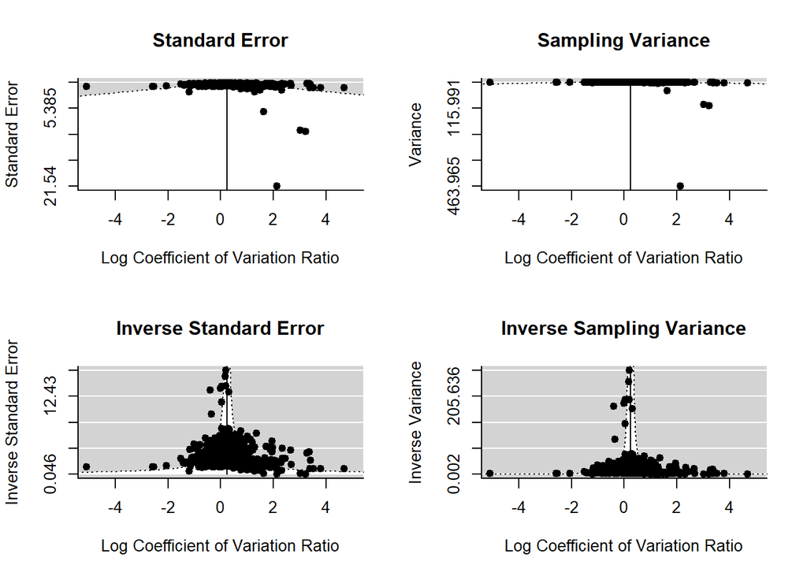

```r
res <- rma(yi = lnCVR.es, vi = lnCVR.sv, data = var.dif, method="FE")

## set up 2x2 array for plotting
par(mfrow=c(2,2))
## draw funnel plots
funnel(res, main="Standard Error", xlim = c(-5, 5))
funnel(res, yaxis="vi", main="Sampling Variance", xlim = c(-5, 5))
funnel(res, yaxis="seinv", main="Inverse Standard Error", xlim = c(-5, 5))
funnel(res, yaxis="vinv", main="Inverse Sampling Variance", xlim = c(-5, 5))
```

## Check data

Checked effect sizes with extremely high/low standard error (SE > 1.2 | 1/SE > 8.5) and confirmed that those data were correctly imported.

```r
outliers <- var.dif %>%
  # vi (sampling variance)
  mutate(SE = sqrt(lnCVR.sv)) %>%
  arrange(desc(SE)) %>%
  filter(SE > 1.2 | 1/SE > 8.5) %>%
  select(ES.ID, Study.name, SE, cross, Reciprocal, trait, Cross.ID) %>%
  mutate_if(is.numeric, round, 3)

outliers %>%
  kable("html", digits = 3, caption = "Effect sizes with extremely high/low standard error (SE > 1.2 | 1/SE > 140)") %>%
  kable_styling("striped", position = "left") %>%
  scroll_box(width = "100%", height = "500px")
```

Effect sizes with extremely high/low standard error (SE > 1.2 | 1/SE > 140)

| ES.ID | Study.name | SE | cross | Reciprocal | trait | Cross.ID |
| --- | --- | --- | --- | --- | --- | --- |
| ES320 | Musolf et al_2015 | 21.540 | spL | Inviable | Frequ Modulated Downsweep_FAC1_2 | musculus.3 |
| ES253 | Musolf et al_2015 | 10.257 | hybSL | Inviable | Complex 2_FAC2_1 | musculus.3 |
| ES253 | Musolf et al_2015 | 9.917 | spL | Inviable | Complex 2_FAC2_1 | musculus.3 |
| ES147 | Musolf et al_2015 | 6.096 | spL | Inviable | U Shaped Inverted_FAC1_2 | musculus.1 |
| ES123 | Musolf et al_2015 | 1.974 | hybSL | Inviable | Complex 2_FAC2_1 | musculus.1 |
| ES320 | Musolf et al_2015 | 1.933 | hybLS | Inviable | Frequ Modulated Downsweep_FAC1_2 | musculus.3 |
| ES367 | Suvanto et al_1994 | 1.656 | hybSL | Viable | inhbt_IPI | Drosophila_borealis_Drosophila_virilis |
| ES371 | Suvanto et al_1994 | 1.617 | spL | Inviable | inhbt_PL | Drosophila_montana_Drosophila_virilis |
| ES125 | Musolf et al_2015 | 1.376 | spL | Inviable | Complex 2_FAC1_4 | musculus.1 |
| ES123 | Musolf et al_2015 | 1.334 | spL | Inviable | Complex 2_FAC2_1 | musculus.1 |
| ES254 | Musolf et al_2015 | 1.265 | spL | Inviable | Complex 2_FAC1_3 | musculus.3 |
| ES246 | Musolf et al_2015 | 1.216 | spL | Inviable | Complex 2_bandwcentre | musculus.3 |
| ES367 | Suvanto et al_1994 | 1.205 | spL | Viable | inhbt_IPI | Drosophila_borealis_Drosophila_virilis |
| ES388 | Tomaru&Oguma_1994 | 0.104 | hybLS | Inviable | IPI | Drosophila_triauraria_Drosophila_biauraria |
| ES041 | Coyne_1985 | 0.087 | hybSL | Viable | Sex comb tooth number | BGxOxnard |
| ES387 | Tomaru&Oguma_1994 | 0.076 | spL | Viable | IPI | Drosophila_triauraria_Drosophila_quadraria |
| ES390 | Tomaru&Oguma_1994 | 0.075 | hybLS | Inviable | IPI | Drosophila_quadraria_Drosophila_subauraria |
| ES390 | Tomaru&Oguma_1994 | 0.073 | spL | Inviable | IPI | Drosophila_quadraria_Drosophila_subauraria |
| ES041 | Coyne_1985 | 0.071 | spL | Viable | Sex comb tooth number | BGxOxnard |
| ES041 | Coyne_1985 | 0.071 | hybLS | Viable | Sex comb tooth number | BGxOxnard |
| ES389 | Tomaru&Oguma_1994 | 0.071 | spL | Viable | IPI | Drosophila_quadraria_Drosophila_biauraria |
| ES388 | Tomaru&Oguma_1994 | 0.064 | spL | Inviable | IPI | Drosophila_triauraria_Drosophila_biauraria |
| ES391 | Tomaru&Oguma_1994 | 0.060 | spL | Viable | IPI | Drosophila_biauraria_Drosophila_subauraria |

```r
var.dif.2 <- var.dif %>%
  filter(!ES.ID %in% unique(outliers$ES.ID))
write.csv(var.dif.2, "../data/variation.ES.general.csv", row.names = F)
```

Because they inhibit meta-analytic model convergence, we excluded these outliers from the formal meta-analysis dataset, but not from novel variability dataset.

## Funnel plots again

Funnel plots after outliers excluded

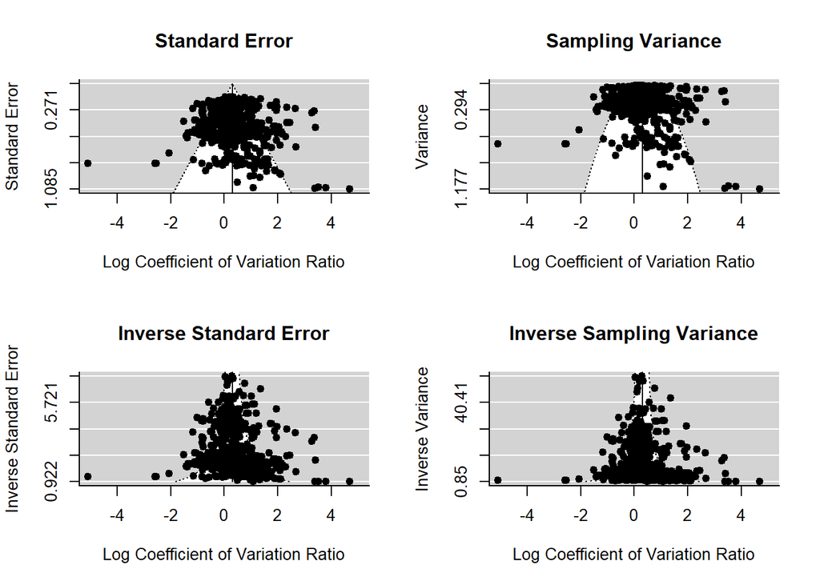

```r
res <- rma(yi = lnCVR.es, vi = lnCVR.sv, data = var.dif.2, method="FE")
## set up 2x2 array for plotting
par(mfrow=c(2,2))
## draw funnel plots
funnel(res, main="Standard Error", xlim = c(-5, 5))
funnel(res, yaxis="vi", main="Sampling Variance", xlim = c(-5, 5))
funnel(res, yaxis="seinv", main="Inverse Standard Error", xlim = c(-5, 5))
funnel(res, yaxis="vinv", main="Inverse Sampling Variance", xlim = c(-5, 5))
```

## Jugding novelty in phenotypic variabilities (using CV)

We judged if hybrids have larger or smaller CV in trait size than both parents (see Fig. 3c)

```r
# load spLS files
dat <- read.csv("../data/dat.CV.csv", head = TRUE)

#+++++++++++++++++++++++++++++++++++++++++++++++++++++++#
# Difference between larger species (spL) and hybrids
#+++++++++++++++++++++++++++++++++++++++++++++++++++++++#

for (i in c("spL")) { # identify type of hybrids
  for (cr in c("hybLS", "hybSL")) { # identify type of parentals
    assign(
      paste(cr, i, sep = "_"),
        escalc(
          measure = "CVR",
          # N of hybrids
          n1i = dat[, paste("N", i, sep = ".")],
          # N of parentals
          n2i = dat[, paste("N", cr, sep = ".")],
          # Mean of hybrids
          m1i = dat[, paste("Mn", i, sep = ".")],
          # Mean of parentals
          m2i = dat[, paste("Mn", cr, sep = ".")],
          # SD of hybrids
          sd1i = dat[, paste("SD", i, sep = ".")],
          # SD of parentals
          sd2i = dat[, paste("SD", cr, sep = ".")],
          data = dat
          ) %>%
          select(ES.ID, yi, vi) %>%
          rename("lnCVR.es" = "yi", "lnCVR.sv" = "vi") %>%
      mutate(
        # direction of transgressve segregation - greater than parent
        direction = "+",
        # SE for logistic distribution, for the weighted binomial regression
        # SE = pi/sqrt(3*(n_e + n_c))
        SE = pi/sqrt(3*(
          dat[, paste("N", i, sep = ".")] + dat[, paste("N", cr, sep = ".")]
        ))
      )
    )
  }
}

#+++++++++++++++++++++++++++++++++++++++++++++++++++++++#
# Difference between hybrids and smaller species (spS)
#+++++++++++++++++++++++++++++++++++++++++++++++++++++++#

for (i in c("hybLS", "hybSL")) { # identify type of hybrids
  for (cr in c("spS")) { # identify type of parentals
    assign(
      paste(i, cr, sep = "_"),
        escalc(
          measure = "CVR",
          # N of hybrids
          n1i = dat[, paste("N", i, sep = ".")],
          # N of parentals
          n2i = dat[, paste("N", cr, sep = ".")],
          # Mean of hybrids
          m1i = dat[, paste("Mn", i, sep = ".")],
          # Mean of parentals
          m2i = dat[, paste("Mn", cr, sep = ".")],
          # SD of hybrids
          sd1i = dat[, paste("SD", i, sep = ".")],
          # SD of parentals
          sd2i = dat[, paste("SD", cr, sep = ".")],
          data = dat
          ) %>%
          select(ES.ID, yi, vi) %>%
          rename("lnCVR.es" = "yi", "lnCVR.sv" = "vi") %>%
      mutate(
        # direction of transgressve segregation - smaller than parent
        direction = "-",
        # SE for logistic distribution, for the weighted binomial regression
        # SE = pi/sqrt(3*(n_e + n_c))
        SE = pi/sqrt(3*(
          dat[, paste("N", i, sep = ".")] + dat[, paste("N", cr, sep = ".")]
        ))
      )
    )
  }
}


#+++++++++++++++++++++++++++++++++++++++++++++++++++++++#
# Data output
#+++++++++++++++++++++++++++++++++++++++++++++++++++++++#

bind_rows(
  ## Difference with mother species ###
  bind_rows(hybLS_spL, hybSL_spS) %>%
    mutate(parental = "Mother"),
  ## Difference with father species ###
  bind_rows(hybLS_spS, hybSL_spL) %>%
    mutate(parental = "Father")
  ) %>%
  drop_na(lnCVR.es) %>%
  left_join(., dat) %>%
  # Assign novel variability to 1, non-novel variability to 0 for each effect size
  mutate(Novelty = ifelse(lnCVR.es < 0, 1, 0)) %>%
  ## Join with metadata ###
  left_join(
    .,
    read.xlsx(
      "../data/original.data.xlsx", sheet = "Species.level.moderators"
      )
    ) %>%
  mutate_at(vars(contains("divergence")), as.numeric) %>%
  mutate_at(vars(contains("divergence")), scale) %>%
  as.data.frame %>%
  select(-trait) %>%
  drop_na(Hetero.sex, trait.type, Genet.divergence) %>%
  # order taxon
  within(
    taxa <- ordered(
      taxa,
      levels = c("Neuroptera", "Coleoptera", "Diptera", "Lepidoptera", "Orthoptera", "Aves", "Rodentia", "Anura", "Cichliformes")
      )
    ) %>%
  mutate_if(is.character, as.factor) %>%
  # Insect or no
  mutate(
    insect = ifelse(taxa %in% c("Aves", "Rodentia", "Anura", "Cichliformes"), "no", "insect"),
  ) %>%
  write.csv("../data/variation.ES.Novelty.csv", row.names = F)
```

## Reload data & Prepare phylogenetic tree

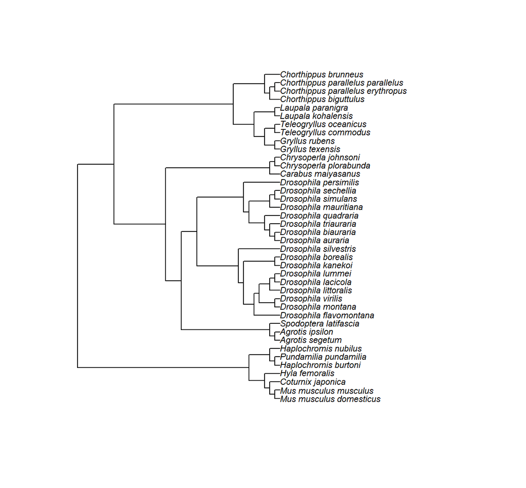

Figure S2. Phylogenetic tree used in meta-analysis for phenotypic variability (coefficient of variation, CV), which was based on tree of the parental species with larger CV in trait size

```r
# Load effect sizes
var.dif <- read.csv("../data/variation.ES.general.csv", head = TRUE)%>%
  # indicate dataset including novel variability
  mutate(data.type = "Alltraits")

# Observations with novel variability
All <- read.csv("../data/variation.ES.novelty.csv", head = TRUE) %>%
  filter(lnCVR.es < 0) %>%
  distinct(ES.ID)
# Effect sizes with non-novel variability
Nonovel <- read.csv("../data/variation.ES.general.csv", head = TRUE) %>%
  filter(!ES.ID %in% unique(All$ES.ID)) %>%
  # indicate dataset without novel variability
  mutate(data.type = "Nonnoveltraits")

# combine dataset with/without novel variability
Novel.Nonnovel <- bind_rows(var.dif, Nonovel) %>%
  mutate(metaunit =  str_c(data.type, cross, sep = "_")) %>%
  # Use observations with both reciprocal crosses
  drop_na(contains("Mn"), contains("SD")) %>%
  # Insect or no
  mutate(
    insect = ifelse(taxa %in% c("Cichliformes", "Anura", "Aves", "Rodentia"), "no", "insect"),
  )

#+++++++++++++++++++++++++++++++#
# Phylogeny
#+++++++++++++++++++++++++++++++#

# # matching names from open tree taxonomy
# taxa <- tnrs_match_names(
#   names = levels(var.dif$spL.name) %>%
#     str_replace_all("_", " "),
#   context_name = "Animals"
#   )
#
# # Create tree
# tree <- tol_induced_subtree(ott_ids = taxa$ott_id)
# tree$tip.label %<>%
#   strip_ott_ids # remove OTT IDs from tip labels
# # randomly solve non-binary phylogeny
# set.seed(6)
# bin.tree <- multi2di(tree, random = T)
#
# # Fix names of tip labels
# bin.tree$tip.label %<>% str_replace_all("Dryophytes", "Hyla")
# # Indicate mismatch between tip labels & dataset species names
# setdiff(levels(as.factor(bin.tree$tip.label)), levels(var.dif$spL.name))
# setdiff(levels(var.dif$spL.name), levels(as.factor(bin.tree$tip.label)))

# write.tree(bin.tree, file= "../data/phylo.variation.tre")

# compute branch lengths of tree
phylo_branch <- read.tree(file = "../data/phylo.variation.tre") %>%
  compute.brlen(bin.tree, method = "Grafen", power = 1)

# saving phylogeneic matrix
phylo_cor <- vcv(phylo_branch, cor = T)

# Note one of the tips is called "Lates calcarifer (estimated)"
phylo_branch$node.label <- NULL

# Plot tree
plot.phylo(phylo_branch, cex = 0.7)
```

## Dominance in coefficient of variation (CV)

We compared midparent-value of phenotypic variability (CV) and hybrids’ phenotypic variability by calculating log ratio of phenotypic variability (lnCVR) of midparent-value and hybrids to *spSS<sub>V</sub>*.

lnCVR of midparent-value to *spSS<sub>V</sub>* was, following $lnCVR=\ln{\frac{CV_E}{CV_C}}+\frac{1}{2(N_E-1)}-\frac{1}{2(N_C-1)}$ , calculated as
$$\ln\frac{CV_{spLL_V}+CV_{spSS_V}}{2}-\ln{CV_{spSS_V}} + \frac{1}{N_{spLL_V}+N_{spSS_V}-2}-\frac{1}{2(N_{spSS_V} - 1)}$$
It’s sampling variance was substitute by that of *spLL<sub>V</sub>*

We statistically compared those effect sizes through the formal meta-regression by using `rma.mv` function of R package `metafor`

All meta-analytic models included following Random effects estimates:

- `Study.ID`: Primary studies. Denoted as **Study**
- `Cross.ID`: Parental strain used in the crossing. Discriminate intraspecific populations. Denoted as **crossed strain**
- `spL.name`: Phylogeny of parental species (*spLL<sub>M</sub>*). Denoted as **species with phylogeny**

```r
#+++++++++++++++++++++++++++++++++++++++++++#
# Calculate midparent
#+++++++++++++++++++++++++++++++++++++++++++#
midparent <- Novel.Nonnovel %>%
  # Divide mean by 2 in spL whereas hybrids are constant
   mutate(
     CV.spL = SD.spL/Mn.spL,
     CV.spS = SD.spS/Mn.spS
     ) %>%
   mutate(
     lnCVR.midparent.es =
       ifelse(
         cross == "spL",
         # log(CVe/CVc)
         log((CV.spL + CV.spS)/2) - log(CV.spS) +
           # 1/2(Ne-1) - 1/2(Nc-1)
           1/(N.spL + N.spS -2) - 1/(2*N.spS - 2),
         lnCVR.es
         )
     # Divide variance by 4 in spL whereas hybrids are constant
     ) %>%
   mutate_at("cross", as.factor) %>%
   within(levels(cross) <- c("hybLS", "hybSL", "midparent"))


#+++++++++++++++++++++++++++++++++++++++++++++++++++#
# Compare midparent and hybrids by meta-regresson
#+++++++++++++++++++++++++++++++++++++++++++++++++++#

for (tr in c("Alltraits", "Nonnoveltraits")) {
  for (taxon in c("alltaxon", "insect")) {

    # Filtering taxon (all taxon or insects)
    if (taxon == "alltaxon") {
      dat <- midparent %>%
        filter(data.type == tr)
    } else {
      dat <- midparent %>%
        filter(data.type == tr, insect == taxon)
    }

    # #+++++++++++++++++++++++++++++++++++++++++++++++++++++++++++++++++#
    # # Estimate meta-analytic mean of midparent of phenotypic variation
    # #+++++++++++++++++++++++++++++++++++++++++++++++++++++++++++++++++#
    # midparent.compare <- rma.mv(
    #   yi = lnCVR.midparent.es, V = lnCVR.sv,
    #   data = dat,
    #   method = "REML",
    #   random = list(~1 | spL.name, ~1 | Study.ID, ~1 | Cross.ID, ~1 | ES.ID),
    #   R = list(spL.name = phylo_cor),
    #   mods = ~ relevel(cross, ref = "midparent")
    #   )
    # ## Save model ###
    # saveRDS(
    #   midparent.compare,
    #   file = paste("../Analysis/Variation.midparent.compare", tr, taxon, "obj", sep = ".")
    #   )

    ## Load model ###
    midparent.compare <- readRDS(paste("../Analysis/Variation.midparent.compare", tr, taxon, "obj", sep = "."))

    assign(
      paste("Dominance", tr, taxon, sep = "."),
      get_reg(midparent.compare) %>%
        # Show dataset name
        within(Dataset <- c(paste(tr, taxon), rep("", length(.$Estimate)-1))) %>%
        # Rename fixed effects
        within('Fixed effects' <- c("", "midparent (intrcpt)", "hybLS", "hybSL")) %>%
        # Difference of each cross from midparent in %
        mutate('Comparison with midparent' = c(
          rep("", 2),
          # Difference hybLS - midparent
          paste(
            round(
            100*(exp(midparent.compare$beta[1]+midparent.compare$beta[2])            -exp(midparent.compare$beta[1])), # hybrid LS
            2),
            "% larger"
            ),
              # beta[1] : midparent
              # beta[2] : hybLS
              # beta[3] : hybSL
          # Difference hybSL - midparent
          paste(
            round(
            100*(exp(midparent.compare$beta[1]+midparent.compare$beta[3])-exp(midparent.compare$beta[1])), # hybrid SL
            2),
            "% larger"
            )
          ))
      )

    # #++++++++++++++++++++++++++++++++++++++++++++++#
    # # Meta-analysis for midparent to plot band
    # #++++++++++++++++++++++++++++++++++++++++++++++#
    #
    # # Phylogenetic random meta-analysis
    # midparent.random <- rma.mv(
    #   yi = lnCVR.midparent.es,
    #   V = lnCVR.sv,
    #   data = dat %>%
    #     filter(cross == "midparent"),
    #   method = "REML",
    #   random = list(~1 | spL.name, ~1 | Study.ID, ~1 | Cross.ID, ~1 | ES.ID),
    #   R = list(spL.name = phylo_cor)
    #   )
    # ## Save model ###
    # saveRDS(
    #   midparent.random,
    #   file = paste("../Analysis/Variation.midparent", tr, taxon, "obj", sep = ".")
    #   )

  }
}

bind_rows(
  Dominance.Alltraits.alltaxon, Dominance.Nonnoveltraits.alltaxon,
  Dominance.Alltraits.insect, Dominance.Nonnoveltraits.insect
  ) %>%
  kable("html", digits = 3, caption = "Table S5. Results of meta-analysis investigating dominance in phenotypic variabilities using full dataset or data subsets") %>%
  kable_styling("striped", position = "left") %>%
  scroll_box(width = "100%", height = "500px")
```

Table S5. Results of meta-analysis investigating dominance in phenotypic variabilities using full dataset or data subsets

Dataset

Fixed effects

Estimate

LowerCI

UpperCI

I2[total]

%I2[species with phylogeny]

%I2[study]

%I2[crossed strain]

%I2[residual]

P

significance

Comparison with midparent

Alltraits alltaxon

75.6%

19.5%

11.4%

0%

44.7%

midparent (intrcpt)

0.381

0.079

0.682

0.013

hybLS

-0.020

-0.098

0.058

0.61

-2.94 % larger

hybSL

-0.091

-0.170

-0.013

0.022

-12.77 % larger

Nonnoveltraits alltaxon

69.9%

14.4%

21%

0%

34.5%

midparent (intrcpt)

0.589

0.275

0.902

<0.001

hybLS

-0.146

-0.257

-0.035

0.01

-24.49 % larger

hybSL

-0.144

-0.254

-0.033

0.011

-24.13 % larger

Alltraits insect

67.8%

0.1%

15.3%

0%

52.4%

midparent (intrcpt)

0.261

0.118

0.404

<0.001

hybLS

-0.016

-0.096

0.064

0.695

-2.06 % larger

hybSL

-0.113

-0.193

-0.032

0.006

-13.82 % larger

Nonnoveltraits insect

56.9%

0%

24.4%

0%

32.5%

midparent (intrcpt)

0.452

0.259

0.645

<0.001

hybLS

-0.144

-0.258

-0.030

0.013

-21.11 % larger

hybSL

-0.173

-0.287

-0.059

0.003

-24.94 % larger

## Univarate meta-analysis for each cross

Quantify and visualise overall trend of phenotypic variability (CV) of hybrids compared to parents  
Meta-analysis was repeated for subset data - including only non-novel phenotypes, only insects, and non-novel phenotypes in insects  
Meta-analysis was conducted by using `rma.mv` function in `metafor` package

- Confidential interval : thick line
- Prediction interval : thin line

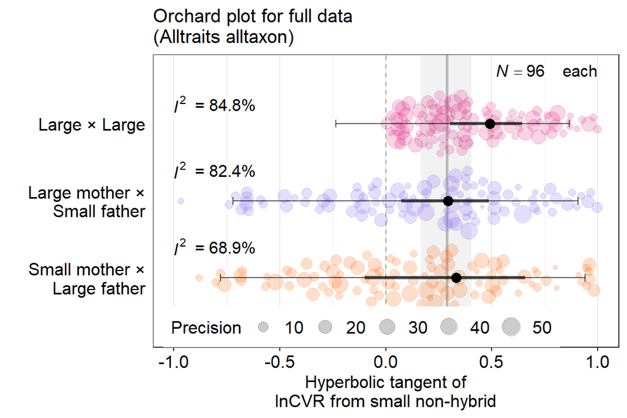

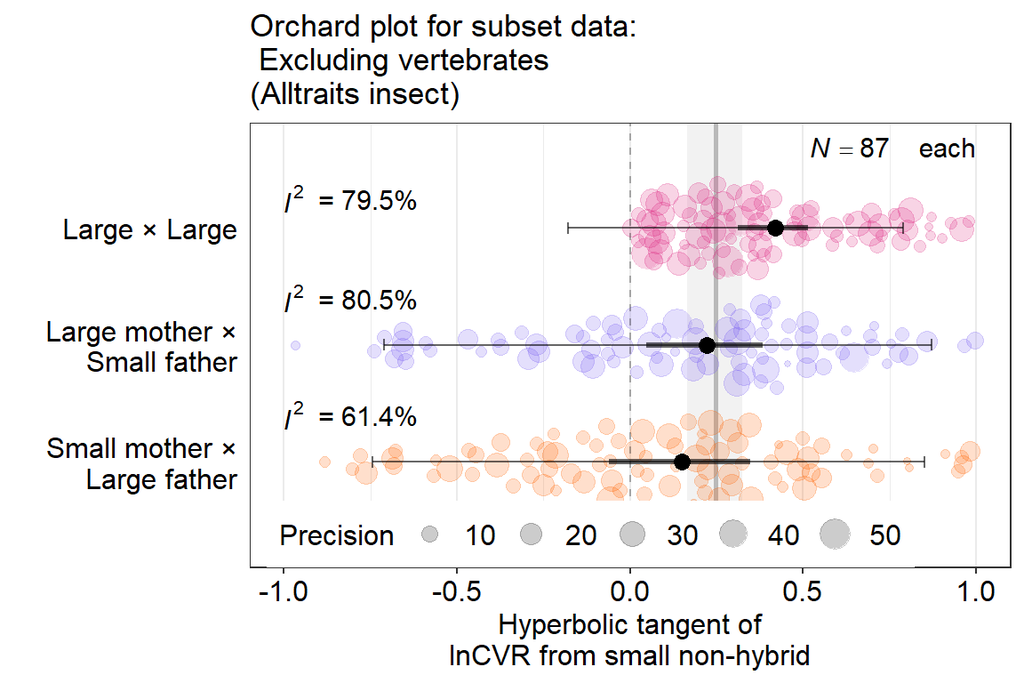

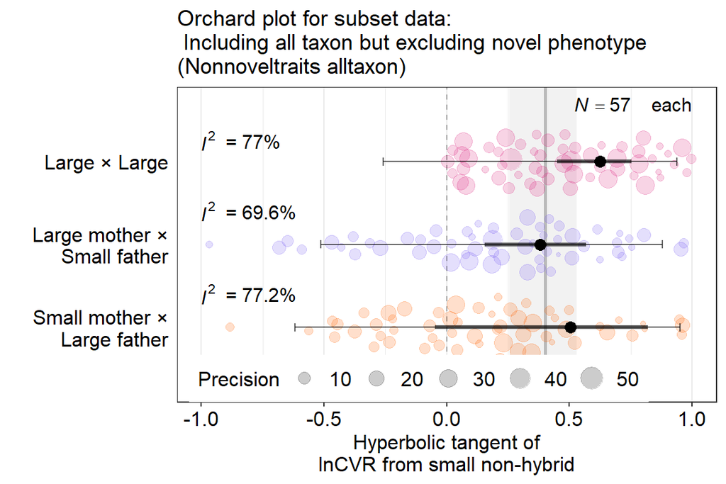

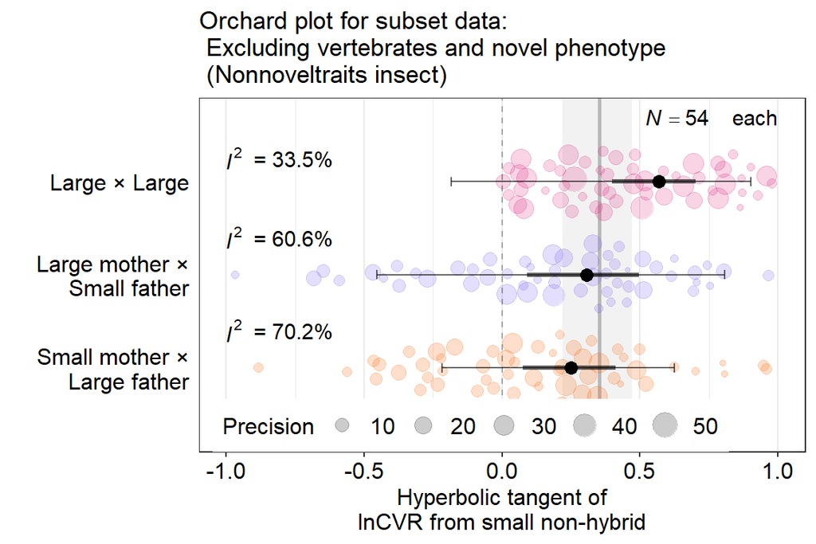

```r
for (tr in c("Alltraits", "Nonnoveltraits")) {
  for (taxon in c("alltaxon", "insect")) {

    if (taxon == "alltaxon") {
      dat.plot <- Novel.Nonnovel %>%
        filter(data.type == tr)
    } else {
      dat.plot <- Novel.Nonnovel %>%
        filter(data.type == tr, insect == taxon)
    }

    res.ma <- foreach(
      cr = c("spL", "hybLS", "hybSL"), .combine = `rbind`
      ) %do% {

      # # Phylogenetic random meta-analysis
      # phyl.random <- rma.mv(
      #   yi = lnCVR.es, V = lnCVR.sv,
      #   data = dat.plot %>%
      #     filter(cross == cr),
      #   method = "REML",
      #   random = list(~1 | spL.name, ~1 | Study.ID, ~1 | Cross.ID, ~1 | ES.ID),
      #   R = list(spL.name = phylo_cor)
      #   )
      # saveRDS(phyl.random,
      #   file = paste("../Analysis/Variation.meta", tr, taxon, cr, "obj", sep = "."))

      # creating summary table of results
      readRDS(
        paste("../Analysis/Variation.meta", tr, taxon, cr, "obj", sep = ".")
        ) %>%
          get_pred() %>%
          as.data.frame() %>%
          mutate(
            N = length(dat$ES.ID),
            # I2 = I2(phyl.random)["I2_total"] %>% round(3),
            cross = cr # indicate cross (spL, hybLS, hybSL)
            ) %>%
        as.data.frame() %>%
        within('Dataset' <- c(paste(tr, taxon), "", "")) %>%  # dataset name in first row
        return()
      }

    # Rename crossing names
    res.ma$cross <- c("Large × Large", "Large mother ×\nSmall father", "Small mother ×\nLarge father")
    dat.plot$cross <- factor(dat.plot$cross, levels = c("spL", "hybLS", "hybSL"))
    levels(dat.plot$cross) <- c("Large × Large", "Large mother ×\nSmall father", "Small mother ×\nLarge father")

    assign(paste("res.ma", tr, taxon, sep = "."), res.ma)

    ## Midparent estimate & CI ###
    midparent.ma.2 <- readRDS(
      paste("../Analysis/Variation.midparent", tr, taxon, "obj", sep = ".")
      ) %>%
      # Prediction interval of midparent
      get_pred() %>%
      as.data.frame()

    # creating a forest plot
    plot.metamean <- ggplot(data = res.ma, aes(x = tanh(Estimate), y = cross)) +
      scale_y_discrete(
        limits = c("Small mother ×\nLarge father", "Large mother ×\nSmall father", "Large × Large"),
        expand = c(0.05, 0.8)
      ) +
      ## Midparent CI ###
      geom_rect(
        aes(
          xmin = tanh(midparent.ma.2$LowerCI),
          xmax = tanh(midparent.ma.2$UpperCI),
          ymin = -Inf, ymax = Inf
          ),
        fill="Grey 95", inherit.aes = FALSE
        ) +
      ## Midparent estimate ###
      geom_vline(
        xintercept = tanh(midparent.ma.2$Estimate), colour = "grey20",
        alpha = 0.3, size = 1
        ) +
      ## Orchard plot ###
      geom_quasirandom(
        data = dat.plot %>%
          filter(data.type == tr),
        aes(x = tanh(lnCVR.es), y = cross, size = 1/lnCVR.sv, color = cross),
        alpha = 0.2, groupOnX = FALSE
        ) +
      scale_color_manual(values = c("#DC267F", "#785EF0", "#FE6100")) +
      # Delete legend for colors
      guides(fill = "none", colour = "none") +
      ## Confidential interval ###
      geom_errorbarh(
        aes(xmin = tanh(LowerCI), xmax = tanh(UpperCI)),
        height = 0, size = 1.2, alpha = 0.6
        ) +
      ## Prediction interval ###
      geom_errorbarh(
        aes(xmin = tanh(lowerPR), xmax = tanh(upperPR)),
        height = 0.1, size = 0.5, alpha = 0.6
        ) +
      geom_vline(xintercept = 0, linetype = 2, colour = "black", alpha = 0.3) +
      ## Estimate ###
      geom_point(size = 3, shape = 21, fill = "black") +
      ## I^2 ###
      annotate(
        "text", x = -1, y = c(1.41, 2.41, 3.26),
        label = "italic(I^2)",
        parse = TRUE, hjust = "left", size = 4
      ) +
      annotate(
        "text", x = -0.9, y = c(1.4, 2.4, 3.25),
        label = paste("=", res.ma$I2), hjust = "left", size = 4
      ) +
      ## N ###
      annotate(
        "text", x = 0.75, y = 3.7,
        label = paste("italic(N)==", length(dat.plot$ES.ID)/3),
        parse = TRUE, hjust = "right", size = 4
      ) +
      annotate(
        "text", x = 1, y = 3.7,
        label = "each", hjust = "right", size = 4
      ) +
      # Labels
      labs(
        y = "",
        x = "Hyperbolic tangent of\nlnCVR from small non-hybrid",
        size = "Precision"
      ) +
      orchardtheme

    if (taxon == "alltaxon") {
      assign(paste0("orchardplot_lnCVR_", tr), plot.metamean)
    }

    print(
      plot.metamean +
        ggtitle(cap[paste(tr, taxon,sep="."),])
    )

    # ggsave(
    #   plot = plot.metamean,
    #   file = paste("../Analysis/variation.general.metamean", tr, taxon, "svg", sep = "."),
    #   height = 4, width = 5
    # )
  }
}
```

```r
bind_rows(
  res.ma.Alltraits.alltaxon, res.ma.Nonnoveltraits.alltaxon,
  res.ma.Alltraits.insect, res.ma.Nonnoveltraits.insect
  ) %>%
  as.data.frame() %>%
    select("Dataset", "cross", "Estimate", contains("erCI"), contains("PR"), "P", "significance", "N", contains("I2")) %>%
  kable("html", digits = 3, caption = "Meta-analyses results of full dataset and data subsets") %>%
  kable_styling("striped", position = "left") %>%
  scroll_box(width = "100%", height = "500px")
```

Meta-analyses results of full dataset and data subsets

Dataset

cross

Estimate

LowerCI

UpperCI

lowerPR

upperPR

P

significance

N

I2[total]

%I2[species with phylogeny]

%I2[study]

%I2[crossed strain]

%I2[residual]

Alltraits alltaxon

Large × Large

0.538

0.314

0.763

-0.240

1.317

<0.001

162

68.9%

12.7%

12.1%

0%

44.1%

Alltraits alltaxon

Large mother × Small father

0.302

0.073

0.531

-0.913

1.516

0.01

162

82.4%

3.2%

10.8%

0%

68.4%

Alltraits alltaxon

Small mother × Large father

0.345

-0.101

0.790

-1.048

1.738

0.129

162

84.8%

24.5%

18.4%

0%

41.8%

Nonnoveltraits alltaxon

Large × Large

0.734

0.485

0.983

-0.265

1.733

<0.001

162

77.2%

0%

29.1%

0%

48.1%

Nonnoveltraits alltaxon

Large mother × Small father

0.402

0.157

0.646

-0.567

1.371

0.001

162

69.6%

0%

24%

0%

45.7%

Nonnoveltraits alltaxon

Small mother × Large father

0.556

-0.049

1.161

-0.722

1.834

0.072

162

77%

66.9%

0%

0%

10.2%

Alltraits insect

Large × Large

0.446

0.322

0.570

-0.181

1.073

<0.001

162

61.4%

0%

14.2%

0%

47.3%

Alltraits insect

Large mother × Small father

0.226

0.048

0.403

-0.892

1.343

0.013

162

80.5%

0%

8.9%

0%

71.6%

Alltraits insect

Small mother × Large father

0.151

-0.061

0.362

-0.957

1.259

0.162

162

79.5%

0%

23.3%

0%

56.2%

Nonnoveltraits insect

Large × Large

0.647

0.424

0.870

-0.185

1.479

<0.001

162

70.2%

0%

24.3%

0%

45.9%

Nonnoveltraits insect

Large mother × Small father

0.317

0.091

0.543

-0.488

1.122

0.006

162

60.6%

0%

22.1%

0%

38.5%

Nonnoveltraits insect

Small mother × Large father

0.256

0.076

0.437

-0.222

0.735

0.005

162

33.5%

0%

21%

11%

1.5%

## Crossing direction effect in phenotypic variability (CV)

We statistically compared lnCVR from *spSS<sub>M</sub>* to the other crosses through the formal meta-regression by using `rma.mv` function of R package `metafor`.  
Here we asked if lnCVR of *hybSL<sub>V</sub>* was smaller/larger than that of *hybLS<sub>V</sub>*. Smaller lnCVR of *hybSL<sub>V</sub>* indicates maternal inheritance in phenotypic variability

```r
for (tr in c("Alltraits", "Nonnoveltraits")) {
  for (taxon in c("alltaxon", "insect")) {

    if (taxon == "alltaxon") {
      dat <- Novel.Nonnovel %>%
        filter(data.type == tr)
    } else {
      dat <- Novel.Nonnovel %>%
        filter(data.type == tr, insect == taxon)
    }

  #++++++++++++++++++++++++++++++++++++++++++++++#
  # phylogenetic random regresson (ANOVA)
  #++++++++++++++++++++++++++++++++++++++++++++++#

  # # Regress by lnCVR of phenotypic difference between parentals
  # phyl.random.spL <- rma.mv(
  #   yi = lnCVR.es, V = lnCVR.sv,
  #   data = dat, method = "REML",
  #   random = list(~1 | spL.name, ~1 | Study.ID, ~1 | Cross.ID, ~1 | ES.ID),
  #   R = list(spL.name = phylo_cor),
  #   mods = ~ relevel(cross, ref = "spL")
  #   )
  # phyl.random.hybLS <- rma.mv(
  #   yi = lnCVR.es, V = lnCVR.sv,
  #   data = dat, method = "REML",
  #   random = list(~1 | spL.name, ~1 | Study.ID, ~1 | Cross.ID, ~1 | ES.ID),
  #   R = list(spL.name = phylo_cor),
  #   mods = ~ cross
  #   )
  # # Save model ###
  # saveRDS(
  #   phyl.random.spL,
  #   file = paste("../Analysis/Variation.compare.from.spL", tr, taxon, "obj", sep = ".")
  #   )
  # saveRDS(
  #   phyl.random.hybLS,
  #   file = paste("../Analysis/Variation.compare.from.hybLS", tr, taxon, "obj", sep = ".")
  #   )

    phyl.random.hybLS <- readRDS(
      paste("../Analysis/Variation.compare.from.hybLS", tr, taxon, "obj", sep = ".")
      )

  assign(
    paste("Reciprocal", tr, taxon, sep = "."),
    phyl.random.hybLS %>%
      get_reg() %>%
      # Show dataset name
      within(Dataset <- c(paste(tr, taxon), rep("", length(.$Estimate)-1))) %>%
      # Rename fixed effects
      within('Fixed effects' <- c("", "hybLS (intrcpt)", "hybSL", "spLL")) %>%
      # Difference of each cross from midparent in %
      mutate('Comparison with hybridLS' = c(
        rep("", 2),
        paste(
          round(
            (exp(phyl.random.hybLS$beta[1]+phyl.random.hybLS$beta[2]) - exp(phyl.random.hybLS$beta[1]))*100,
            2),
          "% larger"
          ),
        ""
        )
      )
    )
  }
}

bind_rows(
  Reciprocal.Alltraits.alltaxon, Reciprocal.Nonnoveltraits.alltaxon,
  Reciprocal.Alltraits.insect, Reciprocal.Nonnoveltraits.insect
  ) %>%
  kable("html", digits = 3, caption = "Table S6. Results of meta-analysis investigating cross direction effect in phenotypic variabilities using full dataset or data subsets") %>%
  kable_styling("striped", position = "left") %>%
  scroll_box(width = "100%", height = "500px")
```

Table S6. Results of meta-analysis investigating cross direction effect in phenotypic variabilities using full dataset or data subsets

Dataset

Fixed effects

Estimate

LowerCI

UpperCI

I2[total]

%I2[species with phylogeny]

%I2[study]

%I2[crossed strain]

%I2[residual]

P

significance

Comparison with hybridLS

Alltraits alltaxon

78.2%

20.1%

9.6%

0%

48.5%

hybLS (intrcpt)

0.377

0.055

0.700

0.022

hybSL

-0.074

-0.155

0.006

0.07

-10.44 % larger

spLL

0.190

0.112

0.268

<0.001

Nonnoveltraits alltaxon

73.8%

10.2%

23%

0%

40.6%

hybLS (intrcpt)

0.451

0.136

0.766

0.005

hybSL

-0.002

-0.118

0.114

0.973

-0.31 % larger

spLL

0.362

0.251

0.474

<0.001

Alltraits insect

72.1%

0.8%

14.2%

0%

57.1%

hybLS (intrcpt)

0.258

0.095

0.420

0.002

hybSL

-0.100

-0.183

-0.016

0.019

-12.26 % larger

spLL

0.178

0.098

0.258

<0.001

Nonnoveltraits insect

65.2%

0%

24.7%

0%

40.5%

hybLS (intrcpt)

0.329

0.107

0.550

0.004

hybSL

-0.032

-0.153

0.088

0.598

-4.42 % larger

spLL

0.354

0.240

0.468

<0.001

# Novelty in phenotypic means

## Frequency

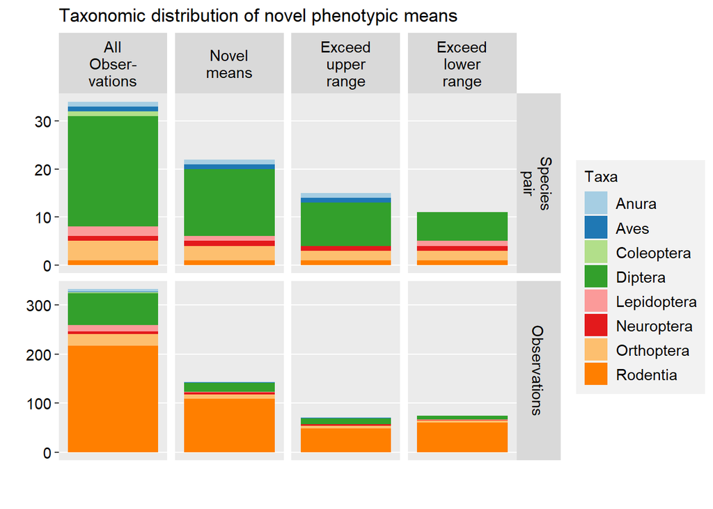

```r
dat.full <- read.csv("../data/mean.ES.Novelty.csv", head = TRUE)

## N of novel phenotype in each taxa and each direction ###
summary <- bind_rows(
  # All observations
  dat.full %>%
    group_by(taxa) %>%
    summarise(
      'Species pair' = length(unique(species.pair)),
      Observations = length(unique(ES.ID)),
      Study = length(unique(Study.ID))
      ) %>%
    mutate(direction = "All Observations")
  ,
  # novel phenotype for any direction
  dat.full %>%
    filter(Novelty == "1") %>%
    group_by(taxa) %>%
    summarise(
      'Species pair' = length(unique(species.pair)),
      Observations = length(unique(ES.ID)),
      Study = length(unique(Study.ID))
      ) %>%
    mutate(direction = "Novel means")
  ,
  # novel phenotype for each direction
  dat.full %>%
    filter(Novelty == "1") %>%
    group_by(taxa, direction) %>%
    summarise(
      'Species pair' = length(unique(species.pair)),
      Observations = length(unique(ES.ID)),
      Study = length(unique(Study.ID))
      )
  ) %>%
  # Assign 0 for non-novel phenotype
  replace(., is.na(.), "0") %>%
  # Make tidy data
  gather(key = metrics, value = N, -c(taxa, direction)) %>%
  # Order factors
  mutate_at(vars("metrics", "direction"), as.factor) %>%
  filter(metrics != "Study")

# Order taxon
summary$metrics <- ordered(summary$metrics, levels = c("Study", "Species pair", "Observations"))
# Order novel phenotype category
summary$direction <- ordered(summary$direction, levels = c("All Observations", "Novel means", "+", "-"))
# Change names of TS category to more intuitive name
levels(summary$direction) <- c("All Observations", "Novel means", "Exceed upper range", "Exceed lower range")

## Plot ###
plot <- ggplot(
  # rename levels of factors to wrap label text
  summary %>%
    within(levels(direction) <- c("All Obser- vations", "Novel means", "Exceed upper range", "Exceed lower range")) %>%
    within(levels(metrics) <- c("Study", "Species pair", "Observations")),
  aes(x = "", y = N, fill = taxa)) +
  geom_bar(width = 1, stat = "identity") +
  scale_fill_brewer(palette = "Paired") +
  facet_grid(
    scale = "free", metrics ~ direction,
    # strip text into two lines
    labeller = label_wrap_gen(width = 10)
    ) +
  labs(x = "", y = "", fill = "Taxa") +
  stackedbartheme
plot +
  ggtitle("Taxonomic distribution of novel phenotypic means")
```

```r
# ggsave(plot, file = "../Plot/part_novelmeanfrequency.svg", height = 3.5, width = 5.2)

## Total number of observations and percentage ###
summary %>%
  group_by(direction, metrics) %>%
  # Count number of observaitons and species pairs
  summarise(sum(N)) %>%
  spread(key = metrics, value = "sum(N)") %>%
  as.data.frame() %>%
  # Calculate percentage
  mutate(
    'Species pair %' = .[, "Species pair"]/.[1, "Species pair"]*100,
    'Observaton %' = Observations/.[1, "Observations"]*100
  ) %>%
  mutate_at(vars(contains("percent")), round, 2) %>%
  kable("html", digits = 3, caption = "Summary of the novel phenotypic means frequency") %>%
  kable_styling("striped", position = "left")
```

Summary of the novel phenotypic means frequency

| direction | Species pair | Observations | Species pair % | Observaton % |
| --- | --- | --- | --- | --- |
| All Observations | 34 | 332 | 100.000 | 100.000 |
| Novel means | 22 | 143 | 64.706 | 43.072 |
| Exceed upper range | 15 | 71 | 44.118 | 21.386 |
| Exceed lower range | 11 | 74 | 32.353 | 22.289 |

## Factors affecting phenotypic novelty

We checked robustness of results by conducting identical analysis for `insect` subset data (removing vertebrate data).

Model, which was ran using `MCMCglmm` function, included following Random effects estimates:

- `Study.ID`: Primary studies
- `Cross.ID`: Parental strain used in the crossing. Discriminate intraspecific populations
- `spL.name`: Phylogeny of parental species (*spLL<sub>M</sub>*)
- `SE.units`: Sampling variance of effect size

The moderators were categorised into 3 subsets: main effects (labelled as `novelty in phenotypic means`), interaction terms with compared parental species (spLL vs. spSS, labelled as `exceed upper range`; mother species vs. father, labelled as `exceed mother`).

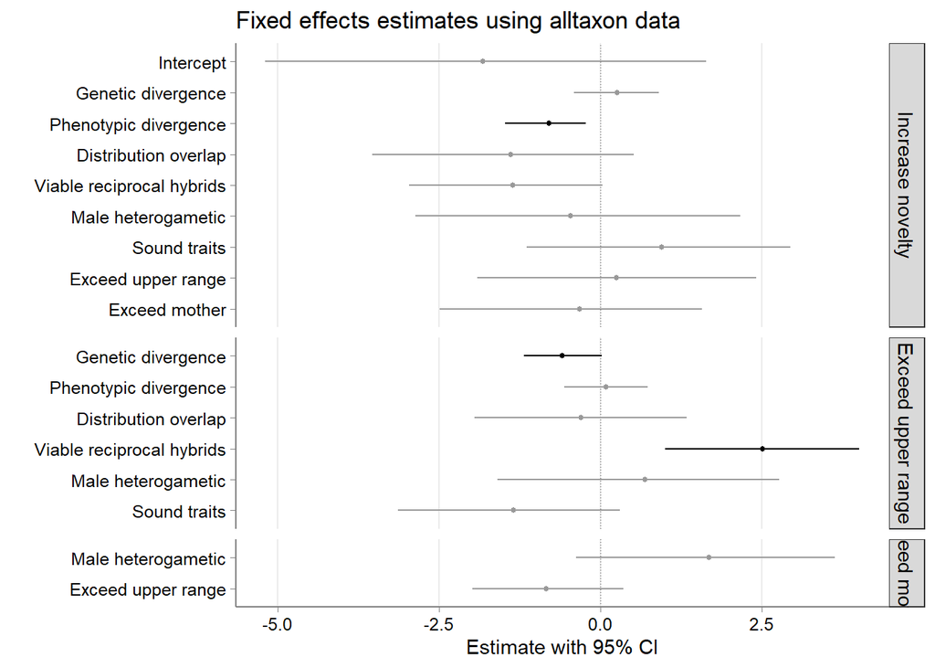

```r
# Correcting estimate of binomial regression
c2 <- (16 * sqrt(3)/(15 * pi))^2


#++++++++++++++++++++++++++++++++++#
# Phylogenetic tree for mcmcglmm
#++++++++++++++++++++++++++++++++++#
# compute branch lengths of tree
phylo_branch <- read.tree(file = "../data/phylo.mean.tre") %>%
  compute.brlen(method = "Grafen", power = 1)

# saving phylogeneic matrix
phylo_cor <- vcv(phylo_branch, cor = T)

# generating inverse phylogenetic matrix for MCMCglmm
phylo_branch$node.label <- NULL
phylo_MCMC <- MCMCglmm::inverseA(phylo_branch, nodes = "ALL", scale = TRUE)$Ainv

# Caption
cap <- data.frame(
  desc = c(
    "Table S7. Fixed effects estimates of Bayesian logistic model investigating factors affecting novelty in phenotypic means. Data of all taxon was used",
    "Fixed effects estimates: insect subset data"
    )
  ) %>%
  mutate_all(as.character)
row.names(cap) <- c("alltaxon", "insect")

for (taxon in c("alltaxon", "insect")) {

  if (taxon == "alltaxon") {
    dat <- dat.full
  } else {
    dat <- dat.full %>%
      filter(insect == taxon)
  }

  # ## Setting prior to logistic regression ###
  # prior <- list(
  #   B=list(
  #     mu = rep(0, 17), # N of coefficient. (level -1) for categorical factors, 1 for continuous factors, 1 for intercept
  #     V = gelman.prior(~
  #       parental*Hetero.sex +
  #       parental*direction +
  #       direction*Genet.divergence + direction*Pheno.divergence +
  #       direction*Hetero.sex +
  #       direction*trait.type +
  #       direction*Distribution + direction*Reciprocal,
  #     data = dat, # formula and data
  #     scale=sqrt(pi^2/3+1))), # error distribution of logistic regression
  #   R=list(V=1,fix=1),
  #   G = list(
  #     G1 = list(V = 1, nu = 1, alpha.mu = 0, alpha.V = 1000),
  #     G2 = list(V = 1, nu = 1, alpha.mu = 0, alpha.V = 1000),
  #     G3 = list(V = 1, nu = 1, alpha.mu = 0, alpha.V = 1000),
  #     G4 = list(V = 1, nu = 1, alpha.mu = 0, alpha.V = 1000)
  #     )
  #   )
  # ## Phylogenetic binomial regression ###
  # phylmix <-MCMCglmm(
  #   fixed = Novelty ~
  #     parental*Hetero.sex + parental*direction +
  #     direction*Genet.divergence + direction*Pheno.divergence +
  #     direction*Hetero.sex + direction*trait.type +
  #     direction*Distribution + direction*Reciprocal,
  #   # idh(SE):units | weight by SE of effect size
  #   random = ~ Study.ID + Cross.ID + spL.name + idh(SE):units,
  #   family = "categorical",
  #   verbose = FALSE,
  #   ginverse = list(spL.name = phylo_MCMC),
  #   prior = prior,
  #   data = dat,
  #   nitt = 60000,  # Increase the number of iterations, default is 13000
  #   burnin = 5000  # Increase the number of burnin, default is 3000
  # )
  # phylmix$Sol <- phylmix$Sol/sqrt(1+c2)
  # ## Save model ###
  # saveRDS(phylmix, file = paste("../Analysis/Mean.novelty.allfactors", taxon, "obj", sep = "."))

  #+++++++++++++++++++++++#
  # Grouping variables
  #+++++++++++++++++++++++#
  # Load model
  phylmix <- readRDS(paste("../Analysis/Mean.novelty.allfactors", taxon, "obj", sep = "."))

  sum <- get_fixed.MCMCglmm(summary(phylmix)$solutions) %>%
      ## Grouping Factors ###
      mutate(
        Group =
          ifelse(str_detect(Factors, "direction.:"),
                 "Exceed upper range",
                 ifelse(str_detect(Factors, "parentalMother:"),
                        "Exceed mother",
                        ifelse(Factors == "Hetero.sexMale:direction+",
                               "Exceed upper range",
                               "Increase novelty"
                               )
                        )
                 )
      ) %>%
      mutate_at("Group", as.factor) %>%
      within(Group <- ordered(Group, c("Increase novelty", "Exceed upper range", "Exceed mother"))) %>%
      ## Change factor names ###
      within(
        Factors <- str_remove_all(
          Factors, "direction.:"
          ) %>%
          str_remove_all(., "parentalMother:") %>%
          str_remove_all(., ":direction.")
        ) %>%
      within(
        Factors <- factor(
          Factors, ordered = TRUE,
          levels = c("parentalMother", "direction+", "trait.typesound", "Hetero.sexMale", "ReciprocalViable", "DistributionOverlap", "Pheno.divergence",  "Genet.divergence",  "(Intercept)")
          )
        )
  levels(sum$Factors) <- c("Exceed mother", "Exceed upper range", "Sound traits", "Male heterogametic", "Viable reciprocal hybrids", "Distribution overlap", "Phenotypic divergence", "Genetic divergence", "Intercept")

  ## Plot ###
  metaplot <- ggplot(sum, aes(x = post.mean, y = Factors)) +
    # Vertical line
    geom_vline(
      xintercept = 0, size = 0.2,
      colour = "grey30", linetype = "dotted"
      ) +
    # CI
    geom_errorbarh(
      aes(
        xmin = sum[, 'l-95% CI'], xmax = sum[, 'u-95% CI'],
        colour=significance
        ),
      height = .0001
      ) +
    # Color of plots and errorbars
    scale_colour_manual(values = c("grey60", "black")) +
    geom_point(size = 1, aes(colour = significance)) +
    scale_fill_manual(values = c("grey60", "black")) +
    # Title
    ggtitle(paste("Fixed effects estimates using", taxon, "data")) +
    ylab("") + xlab("Estimate with 95% CI") +
    # Combine different plots for main Factors and interactions
    facet_grid(
      Group~., scales = "free", space = "free",
      labeller = label_wrap_gen(width = 20)
      ) +
    # Themes
    foresttheme
print(metaplot)

  # ggsave(
  #     plot = metaplot,
  #     file = paste("../Analysis/mean.novelty.result", taxon, "svg", sep = "."),
  #     height = 4.7, width = 4.0
  #     )

  #+++++++++++++++++++++++++#
  # Fixed effects output
  #+++++++++++++++++++++++++#
  sum %>%
    select(Group, Factors, Estimates, '95% credible interval', P, significance) %>%
    kable("html", caption = cap[taxon,]) %>%
    kable_styling("striped", position = "left") %>%
    scroll_box(width = "100%", height = "500px") %>%
    print()

  #+++++++++++++++++++++++++++#
  # Random effects output
  #+++++++++++++++++++++++++++#
  # transformation for varaince
  get_random.MCMCglmm(summary(phylmix$VCV/(1+c2))) %>%
    kable("html", digits = 2,
          caption = paste("Random effects estimates: ", taxon, "data", " ")
          ) %>%
    kable_styling("striped", position = "left") %>%
    print()

}
```

Table S7. Fixed effects estimates of Bayesian logistic model investigating factors affecting novelty in phenotypic means. Data of all taxon was used

Group

Factors

Estimates

95% credible interval

P

significance

Increase novelty

Intercept

-1.82

-5.19 – 1.64

0.269

Increase novelty

Exceed mother

-0.33

-2.49 – 1.57

0.743

Increase novelty

Male heterogametic

-0.46

-2.87 – 2.16

0.717

Increase novelty

Exceed upper range

0.25

-1.9 – 2.41

0.833

Increase novelty

Genetic divergence

0.26

-0.41 – 0.9

0.42

Increase novelty

Phenotypic divergence

-0.80

-1.48 – -0.23

< 0.001

Increase novelty

Sound traits

0.94

-1.14 – 2.94

0.357

Increase novelty

Distribution overlap

-1.39

-3.54 – 0.52

0.138

Increase novelty

Viable reciprocal hybrids

-1.36

-2.97 – 0.04

0.064

Exceed mother

Male heterogametic

1.68

-0.38 – 3.63

0.104

Exceed mother

Exceed upper range

-0.84

-1.99 – 0.35

0.156

Exceed upper range

Genetic divergence

-0.59

-1.19 – 0.02

0.041

Exceed upper range

Phenotypic divergence

0.08

-0.57 – 0.74

0.79

Exceed upper range

Male heterogametic

0.69

-1.6 – 2.77

0.532

Exceed upper range

Sound traits

-1.35

-3.14 – 0.3

0.116

Exceed upper range

Distribution overlap

-0.30

-1.95 – 1.33

0.715

Exceed upper range

Viable reciprocal hybrids

2.51

1.01 – 4.01

< 0.001

Random effects estimates: alltaxon data

| Random effects | Estimates | 95% credible interval |
| --- | --- | --- |
| Study.ID | 1.37 | 0–6.03 |
| Cross.ID | 0.42 | 0–2.53 |
| spL.name | 4.16 | 0–26.95 |
| SE.units | 15.59 | 0.07–84.7 |
| units | 0.74 | 0.74–0.74 |

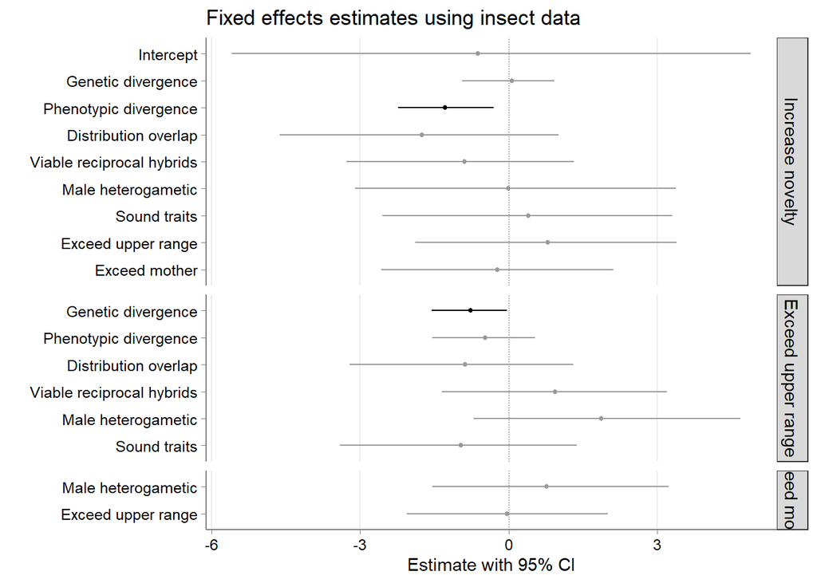

Fixed effects estimates: insect subset data

Group

Factors

Estimates

95% credible interval

P

significance

Increase novelty

Intercept

-0.62

-5.59 – 4.89

0.800

Increase novelty

Exceed mother

-0.23

-2.57 – 2.11

0.845

Increase novelty

Male heterogametic

-0.01

-3.11 – 3.38

0.996

Increase novelty

Exceed upper range

0.79

-1.88 – 3.39

0.560

Increase novelty

Genetic divergence

0.06

-0.94 – 0.92

0.851

Increase novelty

Phenotypic divergence

-1.28

-2.23 – -0.3

0.004

Increase novelty

Sound traits

0.39

-2.55 – 3.3

0.773

Increase novelty

Distribution overlap

-1.76

-4.63 – 1.01

0.223

Increase novelty

Viable reciprocal hybrids

-0.90

-3.27 – 1.32

0.435

Exceed mother

Male heterogametic

0.76

-1.55 – 3.24

0.531

Exceed mother

Exceed upper range

-0.03

-2.06 – 2.01

0.943

Exceed upper range

Genetic divergence

-0.77

-1.55 – -0.03

0.042

Exceed upper range

Phenotypic divergence

-0.47

-1.54 – 0.54

0.369

Exceed upper range

Male heterogametic

1.88

-0.7 – 4.68

0.160

Exceed upper range

Sound traits

-0.97

-3.41 – 1.38

0.416

Exceed upper range

Distribution overlap

-0.89

-3.21 – 1.31

0.433

Exceed upper range

Viable reciprocal hybrids

0.94

-1.35 – 3.2

0.403

Random effects estimates: insect data

| Random effects | Estimates | 95% credible interval |
| --- | --- | --- |
| Study.ID | 5.97 | 0–31.8 |
| Cross.ID | 2.84 | 0–16.35 |
| spL.name | 30.36 | 0.18–119.64 |
| SE.units | 112.29 | 0.49–336.88 |
| units | 0.74 | 0.74–0.74 |

While one of significant moderators (`Reciprocal hybrids`) become no longer significant in `insect` subset data, effects are qualitatively the same in sign.

## Effects of significant moderators

To visually interpret the impacts of significant moderators, we additionally conducted simpler models for each significant factor. As moderators, we included the focal factors, the compared parental species – spLL or spSS, and the interaction between them. Response variables and random effects of simper models were identical to full models.

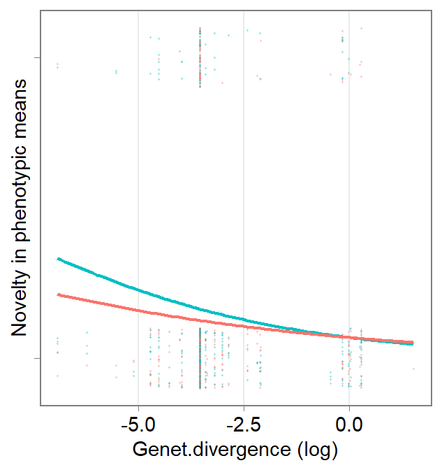

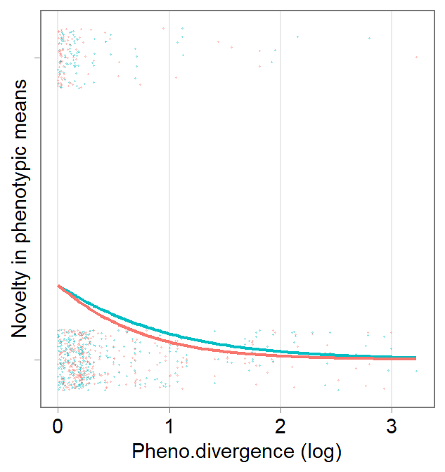

```r
# +++++++++++++++++++++++++++++++++++++++++++#
# To set raw metadata in X axis, reload raw metadata and combine to novelty dataset
# +++++++++++++++++++++++++++++++++++++++++++#
rawdat <- dat.full %>%
  select(-Pheno.divergence, -Genet.divergence) %>%
  # lnRR between parental species as phenotypic distance
  mutate(Pheno.divergence = log(Mn.spL/Mn.spS)) %>%
  left_join(
    .,
    read.xlsx("../data/original.data.xlsx", sheet = "Species.level.moderators") %>%
      select(Cross.ID, Genet.divergence)
    ) %>%
  # Natural log of genetic distance
  mutate_at("Genet.divergence", log) %>%
  mutate_at("direction", as.factor)

# +++++++++++++++++++++++++++++++++++++++++++#
# Regression: Genetic distance
# +++++++++++++++++++++++++++++++++++++++++++#

# ## Setting prior to logistic regression ###
# prior <- list(
#   B=list(
#     mu = rep(0, 3), # N of coefficient. (level -1) for categorical factors, 1 for continuous factors, 1 for intercept
#     V = gelman.prior(~ direction:Genet.divergence + Genet.divergence,
#     data = rawdat, # formula and data
#     scale=sqrt(pi^2/3+1))), # error distribution of logistic regression
#   R=list(V=1,fix=1),
#   G = list(
#     G1 = list(V = 1, nu = 1, alpha.mu = 0, alpha.V = 1000),
#     G2 = list(V = 1, nu = 1, alpha.mu = 0, alpha.V = 1000),
#     G3 = list(V = 1, nu = 1, alpha.mu = 0, alpha.V = 1000),
#     G4 = list(V = 1, nu = 1, alpha.mu = 0, alpha.V = 1000)
#     )
#   )
# ## Phylogenetic binomial regression ###
# phylmix <-MCMCglmm(
#   fixed = Novelty ~ direction:Genet.divergence + Genet.divergence,
#   # idh(SE):units | weight by SE of effect size
#   random = ~ Study.ID + Cross.ID + spL.name + idh(SE):units,
#   family = "categorical",
#   verbose = FALSE,
#   ginverse = list(spL.name = phylo_MCMC),
#   prior = prior,
#   data = rawdat,
#   nitt = 60000,  # Increase the number of iterations, default is 13000
#   burnin = 5000  # Increase the number of burnin, default is 3000
# )
# phylmix$Sol <- phylmix$Sol/sqrt(1+c2)
# ## Save model ###
# saveRDS(phylmix, file ="../Analysis/Mean.novelty.Genet.divergence.obj")

# +++++++++++++++++++++++++++++++++++++++++++#
# Regression: Phenotypic divergence
# +++++++++++++++++++++++++++++++++++++++++++#
# ## Setting prior to logistic regression ###
# prior <- list(
#   B=list(
#     mu = rep(0, 3), # N of coefficient. (level -1) for categorical factors, 1 for continuous factors, 1 for intercept
#     V = gelman.prior(~ direction:Pheno.divergence + Pheno.divergence,
#     data = rawdat, # formula and data
#     scale=sqrt(pi^2/3+1))), # error distribution of logistic regression
#   R=list(V=1,fix=1),
#   G = list(
#     G1 = list(V = 1, nu = 1, alpha.mu = 0, alpha.V = 1000),
#     G2 = list(V = 1, nu = 1, alpha.mu = 0, alpha.V = 1000),
#     G3 = list(V = 1, nu = 1, alpha.mu = 0, alpha.V = 1000),
#     G4 = list(V = 1, nu = 1, alpha.mu = 0, alpha.V = 1000)
#     )
#   )
# ## Phylogenetic binomial regression ###
# phylmix <-MCMCglmm(
#   fixed = Novelty ~ direction:Pheno.divergence + Pheno.divergence,
#   # idh(SE):units | weight by SE of effect size
#   random = ~ Study.ID + Cross.ID + spL.name + idh(SE):units,
#   family = "categorical",
#   verbose = FALSE,
#   ginverse = list(spL.name = phylo_MCMC),
#   prior = prior,
#   data = rawdat,
#   nitt = 60000,  # Increase the number of iterations, default is 13000
#   burnin = 5000  # Increase the number of burnin, default is 3000
# )
# phylmix$Sol <- phylmix$Sol/sqrt(1+c2)
# ## Save model ###
# saveRDS(phylmix, file ="../Analysis/Mean.novelty.Pheno.divergence.obj")

#++++++++++++++++++++++++++++++++++++++++++++++++++#
# Plot
#++++++++++++++++++++++++++++++++++++++++++++++++++#
for (i in c("Genet.divergence", "Pheno.divergence")) {

  ## Load model ###
  phylmix <- readRDS(
    paste("../Analysis/Mean.novelty",i, "obj", sep = ".")
    )
  reg <- summary(phylmix$Sol)$statistics %>%
      as.data.frame()

  ## Plot ###
  plot <- ggplot(rawdat, aes(x = rawdat[,i], y = rawdat[, "Novelty"])) +
    geom_jitter(
      height = 0.1, width = 0, aes(color = direction), alpha = 0.3, size = 0.2
      ) +
    # novelty for larger mean
    stat_function(
      aes(color = "+"), size = 0.8,
      fun = function(x)
        1/(1 + exp(-(reg[1,1] + x*(reg[2,1]+reg[3,1]))))
      ) +
    # novelty for smaller mean
    stat_function(
      aes(color = "-"), size = 0.8,
      fun = function(x)
        1/(1 + exp(-(reg[1,1] + x*reg[2,1])))
      ) +
    ylab("Novelty in phenotypic means") +
    xlab(paste(i, "(log)")) +
    scale_fill_brewer(palette = "Set2") +
    scale_y_continuous(breaks=seq(0,1)) +
    regressiontheme
  print(plot)
  # ggsave(
  #   plot = plot + theme(axis.title  = element_blank()),
  #   file = paste("../Plot/part_novelmeanscontinuous", i, "svg", sep = "."),
  #   height = 1.7, width = 1.6
  #   )

}
```

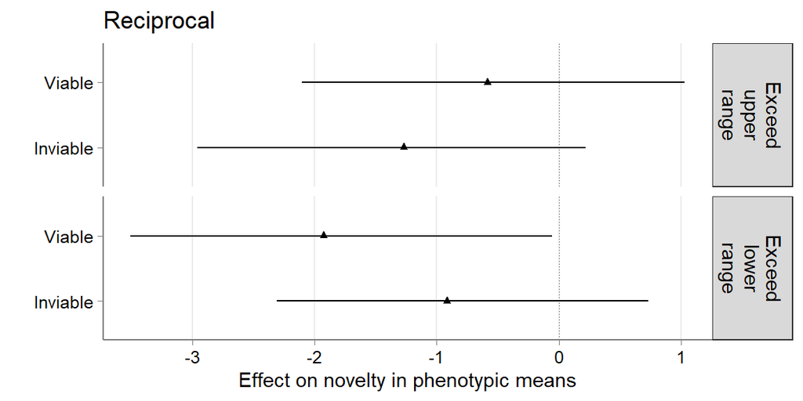

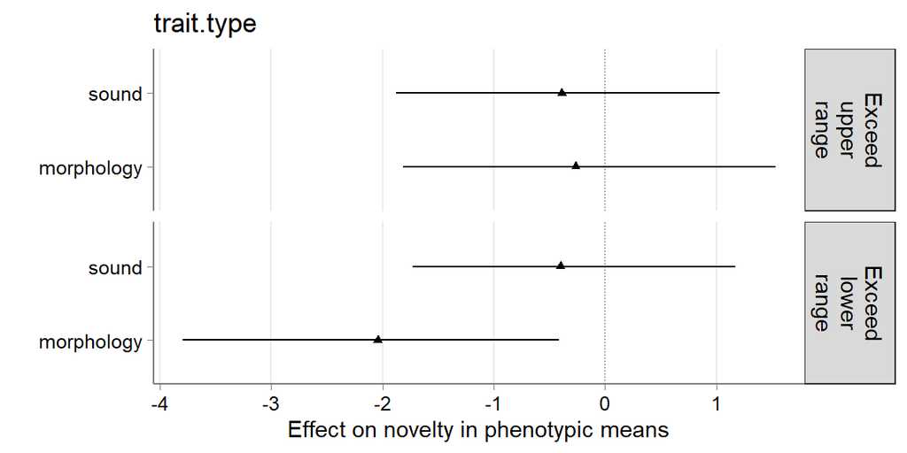

```r
for (i in c("Reciprocal", "trait.type")) {

    # Make new categorical data combining direction of TS and target categorical factor
    dat %<>%
      mutate(interaction = str_c(direction, .[, i], sep = "_"))

    # ## Setting prior to logistic regression ###
    # prior <- list(
    #   B=list(
    #     mu = rep(0, 4), # N of coefficient. (level -1) for categorical factors, 1 for continuous factors, 1 for intercept
    #     V = gelman.prior(~ interaction, # + trait.direction
    #     data = dat, # formula and data
    #     scale=sqrt(pi^2/3+1))), # error distribution of logistic regression
    #   R=list(V=1,fix=1),
    #   # Replicating same G for the number of random effects (here, 4)
    #   G = list(
    #     G1 = list(V = 1, nu = 1, alpha.mu = 0, alpha.V = 1000),
    #     G2 = list(V = 1, nu = 1, alpha.mu = 0, alpha.V = 1000),
    #     G3 = list(V = 1, nu = 1, alpha.mu = 0, alpha.V = 1000),
    #     G4 = list(V = 1, nu = 1, alpha.mu = 0, alpha.V = 1000)
    #     )
    #   )
    #
    # phylmix <-MCMCglmm(
    #   fixed = Novelty ~  interaction -1, # + trait.direction
    #   family = "categorical",
    #   # idh(SE):units | weight by SE of effect size
    #   random = ~ Study.ID + Cross.ID + spL.name + idh(SE):units,
    #   verbose = FALSE,
    #   ginverse = list(spL.name = phylo_MCMC),
    #   prior = prior,
    #   data = dat
    # )
    # # Correct model result
    # phylmix$Sol <- phylmix$Sol/sqrt(1+c2)
    # ## Save model ###
    # saveRDS(
    #   phylmix,
    #   file =
    #     paste("../Analysis/Mean.novelty", i, "alltaxon.obj", sep = ".")
    #     )

  #++++++++++++++++++++++++++++++++++++++#
  # ing interaction terms
  #++++++++++++++++++++++++++++++++++++++#
  phylmix <- readRDS(
    paste("../Analysis/Mean.novelty", i, "alltaxon.obj", sep = ".")
    )

  sum <- summary(phylmix)$solutions %>%
    as.data.frame() %>%
    rownames_to_column(var = "factors") %>%
    mutate(
      # Impact on exceeding upper or lower range
      direction =
        ifelse(str_detect(factors, "interaction\\+"),
               "Exceed upper range",
               "Exceed lower range"
               ) %>%
        as.factor
      ) %>%
    within(direction <- ordered(direction, c("Exceed upper range", "Exceed lower range"))) %>%
    ## Change factor names ###
    within(
      factors <- str_remove_all(factors, "interaction._")
      )

    #++++++++++++++++++++++++++++++++++++++#
    # Plot
    #++++++++++++++++++++++++++++++++++++++#
    categoricalplot <- ggplot(sum, aes(x = post.mean, y = factors)) +
      # Vertical line
      geom_vline(
        xintercept = 0, size = 0.3,
        colour = "grey30", linetype = "dotted"
        ) +
      # CI
      geom_errorbarh(
        aes(xmin = sum[, 'l-95% CI'], xmax = sum[, 'u-95% CI']),
        height = .0001
        ) +
      geom_point(size = 1.3, shape = 17) +
      # Title
      ylab("") + xlab("Effect on novelty in phenotypic means") +
      ggtitle(i) +
      # Combine different plots for main factors and interactions
      facet_grid(
        direction ~., scales = "free", drop = TRUE,
        labeller = label_wrap_gen(width = 11)
        ) +
      foresttheme
    print(categoricalplot)

    # ggsave(
    #     plot = categoricalplot + theme(axis.text.y = element_blank()),
    #     file = paste("../Analysis/Mean.TS.categorical", i,taxon, "svg", sep = "."),
    #     height = 1.8, width = 2.5
    #     )

}
```

# Novelty in phenotypic variabilities (using CV)

## Frequency

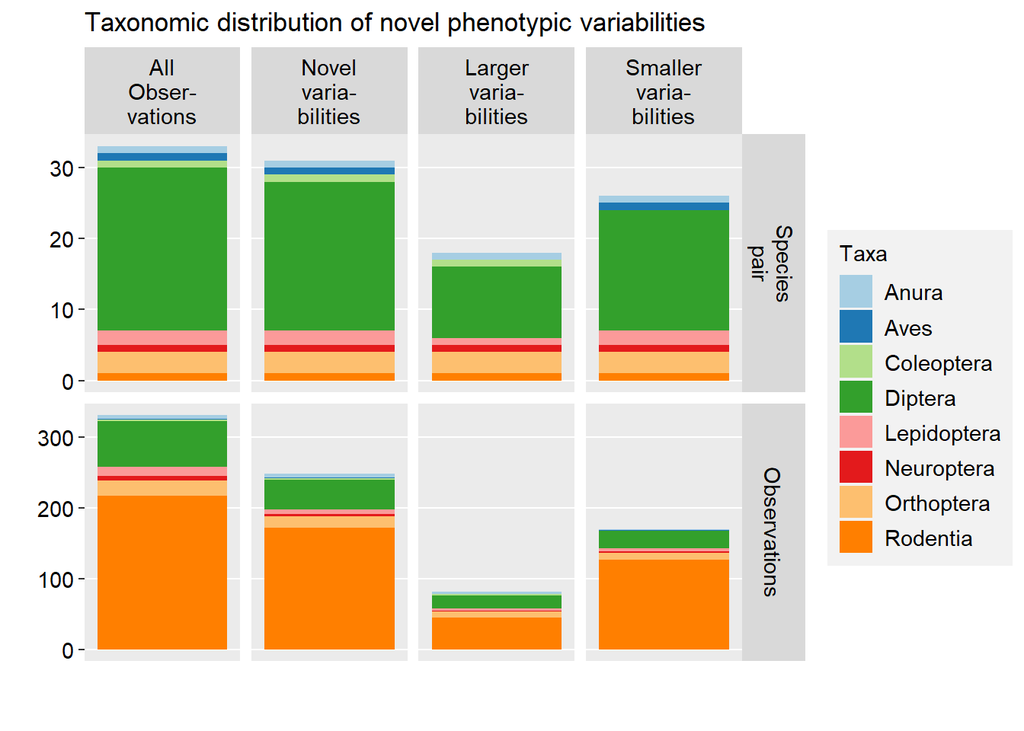

```r
dat.full <- read.csv("../data/variation.ES.Novelty.csv", head = TRUE)

## N of TS in each taxa and each direction ###
summary <- bind_rows(
  # All observations
  dat.full %>%
    group_by(taxa) %>%
    summarise(
      'Species pair' = length(unique(species.pair)),
      Observations = length(unique(ES.ID)),
      Study = length(unique(Study.ID))
      ) %>%
    mutate(direction = "All Observations")
  ,
  # TS for any direction
  dat.full %>%
    filter(Novelty == "1") %>%
    group_by(taxa) %>%
    summarise(
      'Species pair' = length(unique(species.pair)),
      Observations = length(unique(ES.ID)),
      Study = length(unique(Study.ID))
      ) %>%
    mutate(direction = "Increase novelty")
  ,
  # TS for each direction
  dat.full %>%
    filter(Novelty == "1") %>%
    group_by(taxa, direction) %>%
    summarise(
      'Species pair' = length(unique(species.pair)),
      Observations = length(unique(ES.ID)),
      Study = length(unique(Study.ID))
      )
  ) %>%
  # Assign 0 for no observation of TS
  replace(., is.na(.), "0") %>%
  # Make tidy data
  gather(key = metrics, value = N, -c(taxa, direction)) %>%
  # Order factors
  mutate_at(vars("metrics", "direction"), as.factor) %>%
  filter(metrics != "Study")

# Order taxon
summary$metrics <- ordered(summary$metrics, levels = c("Study", "Species pair", "Observations"))
# Order TS category
summary$direction <- ordered(summary$direction, levels = c("All Observations", "Increase novelty", "+", "-"))
# Change names of TS category to more intuitive name
levels(summary$direction) <- c("All Observations", "Increase novelty", "Larger variabilities", "Smaller variabilities")

## Plot ###
plot <- ggplot(
  # rename levels of factors to wrap label text
  summary %>%
    within(levels(direction) <- c("All Obser- vations", "Novel varia- bilities", "Larger varia- bilities", "Smaller varia- bilities")) %>%
    within(levels(metrics) <- c("Study", "Species pair", "Observations")),
  aes(x = "", y = N, fill = taxa)) +
  geom_bar(width = 1, stat = "identity") +
  scale_fill_brewer(palette = "Paired") +
  facet_grid(
    scale = "free", metrics ~ direction,
    # strip text into two lines
    labeller = label_wrap_gen(width = 10)
    ) +
  labs(x = "", y = "", fill = "Taxa") +
  stackedbartheme
plot +
  ggtitle("Taxonomic distribution of novel phenotypic variabilities")
```

```r
# ggsave(plot, file = "../Plot/part_novelvarfrequency.svg", height = 3.5, width = 5.2)

## Total number of observations and percentage ###
summary %>%
  group_by(direction, metrics) %>%
  # Count number of observaitons and species pairs
  summarise(sum(N)) %>%
  spread(key = metrics, value = "sum(N)") %>%
  as.data.frame() %>%
  # Calculate percentage
  mutate(
    'Species pair %' = .[, "Species pair"]/.[1, "Species pair"]*100,
    'Observaton %' = Observations/.[1, "Observations"]*100
  ) %>%
  mutate_at(vars(contains("percent")), round, 2) %>%
  kable("html", digits = 3, caption = "Summary of the novel phenotypic variabilities frequency") %>%
  kable_styling("striped", position = "left")
```

Summary of the novel phenotypic variabilities frequency

| direction | Species pair | Observations | Species pair % | Observaton % |
| --- | --- | --- | --- | --- |
| All Observations | 33 | 331 | 100.000 | 100.000 |
| Increase novelty | 31 | 248 | 93.939 | 74.924 |
| Larger variabilities | 18 | 82 | 54.545 | 24.773 |
| Smaller variabilities | 26 | 170 | 78.788 | 51.360 |

## Factors affecting novelty in phenotypic variability

We checked robustness of results by conducting identical analysis for `insect` subset data (removing vertebrate data).

Model, which was ran using `MCMCglmm` function, included following Random effects estimates:

- `Study.ID`: Primary studies
- `Cross.ID`: Parental strain used in the crossing. Discriminate intraspecific populations
- `spL.name`: Phylogeny of parental species (*spLL<sub>V</sub>*)
- `SE.units`: Sampling variance of effect size

The moderators were categorised into 3 subsets: main effects (labelled as `novelty in phenotypic variabilities`), interaction terms with compared parental species (spLL vs. spSS, labelled as `exceed upper range`; mother species vs. father, labelled as `exceed mother`).

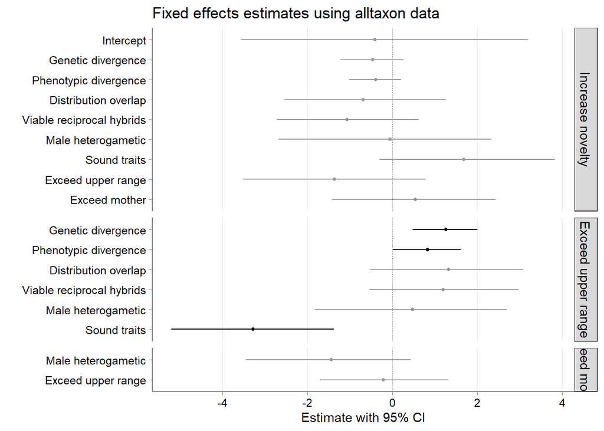

```r
#++++++++++++++++++++++++++++++++++#
# Phylogenetic tree for mcmcglmm
#++++++++++++++++++++++++++++++++++#

# compute branch lengths of tree
phylo_branch <- read.tree(file = "../data/phylo.variation.tre") %>%
  compute.brlen(method = "Grafen", power = 1)

# saving phylogeneic matrix
phylo_cor <- vcv(phylo_branch, cor = T)

# generating inverse phylogenetic matrix for MCMCglmm
phylo_branch$node.label <- NULL
phylo_MCMC <- MCMCglmm::inverseA(phylo_branch, nodes = "ALL", scale = TRUE)$Ainv


#+++++++++++++++++++++++++++++++++++++#
# Phylogenetic comparative analysis
#+++++++++++++++++++++++++++++++++++++#

# Caption
cap <- data.frame(
  desc = c(
    "Table S8. Fixed effects estimates of Bayesian logistic model investigating factors affecting novelty in phenotypic variabilities. Data of all taxon was used",
    "Fixed effects estimates: insect subset data"
    )
  ) %>%
  mutate_all(as.character)
row.names(cap) <- c("alltaxon", "insect")

for (taxon in c("alltaxon", "insect")) {

  if (taxon == "alltaxon") {
    dat <- dat.full
  } else {
    dat <- dat.full %>%
      filter(insect == taxon)
  }

  # ## Setting prior to logistic regression ###
  # prior <- list(
  #   B=list(
  #     mu = rep(0, 17), # N of coefficient. (level -1) for categorical factors, 1 for continuous factors, 1 for intercept
  #     V = gelman.prior(~
  #     parental*Hetero.sex + parental*direction +
  #     direction*Genet.divergence + direction*Pheno.divergence +
  #     direction*Hetero.sex + direction*trait.type +
  #     direction*Distribution + direction*Reciprocal,
  #     data = dat, # formula and data
  #     scale=sqrt(pi^2/3+1))), # error distribution of logistic regression
  #   R=list(V=1,fix=1),
  #   # Replicating same G for the number of random effects (here, 4)
  #   G = list(
  #     G1 = list(V = 1, nu = 1, alpha.mu = 0, alpha.V = 1000),
  #     G2 = list(V = 1, nu = 1, alpha.mu = 0, alpha.V = 1000),
  #     G3 = list(V = 1, nu = 1, alpha.mu = 0, alpha.V = 1000),
  #     G4 = list(V = 1, nu = 1, alpha.mu = 0, alpha.V = 1000)
  #     )
  #   )
  # ## Phylogenetic binomial regression ###
  # phylmix <-MCMCglmm(
  #   fixed = Novelty ~
  #     parental*Hetero.sex + parental*direction +
  #     direction*Genet.divergence + direction*Pheno.divergence +
  #     direction*Hetero.sex + direction*trait.type +
  #     direction*Distribution + direction*Reciprocal,
  #   family = "categorical",
  #   # idh(SE):units | weight by SE of effect size
  #   random = ~ Study.ID + Cross.ID + spL.name + idh(SE):units,
  #   verbose = FALSE,
  #   ginverse = list(spL.name = phylo_MCMC),
  #   prior = prior,
  #   data = dat,
  #   nitt = 60000,  # Increase the number of iterations, default is 13000
  #   burnin = 5000  # Increase the number of burnin, default is 3000
  # )
  # ## Correcting estimate ###
  # phylmix$Sol <- phylmix$Sol/sqrt(1+c2)
  # ## Save model ###
  # saveRDS(
  #   phylmix,
  #   file = paste("../Analysis/Variation.novelty.allfactors", taxon, "obj", sep = ".")
  #   )

  ## Load model ###
  phylmix <- readRDS(file = paste("../Analysis/Variation.novelty.allfactors", taxon, "obj", sep = "."))

  sum <- get_fixed.MCMCglmm(summary(phylmix)$solutions) %>%
    ## ing Factors ###
    mutate(
      Group =
        ifelse(str_detect(Factors, "direction.:"),
               "Exceed upper range",
               ifelse(str_detect(Factors, "parentalMother:"),
                      "Exceed mother",
                      ifelse(Factors == "Hetero.sexMale:direction+",
                             "Exceed upper range",
                             "Increase novelty"
                             )
                      )
               )
    ) %>%
    mutate_at("Group", as.factor) %>%
    within(Group <- ordered(Group, c("Increase novelty", "Exceed upper range", "Exceed mother"))) %>%
    ## Change factor names ###
    within(
      Factors <- str_remove_all(
        Factors, "direction.:"
        ) %>%
        str_remove_all(., "parentalMother:") %>%
        str_remove_all(., ":direction.")
      ) %>%
    within(
      Factors <- factor(
        Factors, ordered = TRUE,
        levels = c("parentalMother", "direction+", "trait.typesound", "Hetero.sexMale", "ReciprocalViable", "DistributionOverlap", "Pheno.divergence",  "Genet.divergence",  "(Intercept)")
        )
      )
  levels(sum$Factors) <- c("Exceed mother", "Exceed upper range", "Sound traits", "Male heterogametic", "Viable reciprocal hybrids", "Distribution overlap", "Phenotypic divergence", "Genetic divergence", "Intercept")

  ## Plot ###
  metaplot <- ggplot(sum, aes(x = post.mean, y = Factors)) +
    # Vertical line
    geom_vline(
      xintercept = 0, size = 0.2,
      colour = "grey30", linetype = "dotted"
      ) +
    # CI
    geom_errorbarh(
      aes(
        xmin = sum[, 'l-95% CI'], xmax = sum[, 'u-95% CI'],
        colour=significance
        ),
      height = .0001
      ) +
    # Color of plots and errorbars
    scale_colour_manual(values = c("grey60", "black")) +
    geom_point(size = 1, aes(colour = significance)) +
    scale_fill_manual(values = c("grey60", "black")) +
    # Title
    ggtitle(paste("Fixed effects estimates using", taxon, "data")) +
    ylab("") + xlab("Estimate with 95% CI") +
    # Combine different plots for main Factors and interactions
    facet_grid(
      Group~., scales = "free", space = "free",
      labeller = label_wrap_gen(width = 20)
      ) +
    # Themes
    foresttheme
  print(metaplot)

  # ggsave(
  #     plot = metaplot,
  #     file = paste("../Analysis/variation.TS.result", taxon, "svg", sep = "."),
  #     height = 4.7, width = 4.0
  #     )

  #+++++++++++++++++++++++++#
  # Fixed effects output
  #+++++++++++++++++++++++++#
  sum %>%
    select(Group, Factors, Estimates, '95% credible interval', P, significance) %>%
    kable("html", caption = cap[taxon,]) %>%
    kable_styling("striped", position = "left") %>%
    scroll_box(width = "100%", height = "500px") %>%
    print()

  #+++++++++++++++++++++++++++#
  # Random effects output
  #+++++++++++++++++++++++++++#
  # transformation for varaince
  get_random.MCMCglmm(summary(phylmix$VCV/(1+c2))) %>%
    kable("html", digits = 2,
          caption = paste("Random effects estimates: ", taxon, "data", " ")
          ) %>%
    kable_styling("striped", position = "left") %>%
    print()

}
```

Table S8. Fixed effects estimates of Bayesian logistic model investigating factors affecting novelty in phenotypic variabilities. Data of all taxon was used

Group

Factors

Estimates

95% credible interval

P

significance

Increase novelty

Intercept

-0.41

-3.57 – 3.2

0.769

Increase novelty

Exceed mother

0.54

-1.43 – 2.43

0.588

Increase novelty

Male heterogametic

-0.06

-2.68 – 2.33

0.961

Increase novelty

Exceed upper range

-1.36

-3.52 – 0.78

0.21

Increase novelty

Genetic divergence

-0.47

-1.23 – 0.26

0.22

Increase novelty

Phenotypic divergence

-0.39

-1.02 – 0.2

0.208

Increase novelty

Sound traits

1.68

-0.31 – 3.83

0.109

Increase novelty

Distribution overlap

-0.69

-2.55 – 1.26

0.464

Increase novelty

Viable reciprocal hybrids

-1.07

-2.72 – 0.62

0.203

Exceed mother

Male heterogametic

-1.44

-3.45 – 0.43

0.142

Exceed mother

Exceed upper range

-0.22

-1.7 – 1.33

0.79

Exceed upper range

Genetic divergence

1.25

0.47 – 2

< 0.001

Exceed upper range

Phenotypic divergence

0.83

0.01 – 1.61

0.036

Exceed upper range

Male heterogametic

0.47

-1.84 – 2.7

0.678

Exceed upper range

Sound traits

-3.29

-5.21 – -1.38

< 0.001

Exceed upper range

Distribution overlap

1.32

-0.53 – 3.08

0.151

Exceed upper range

Viable reciprocal hybrids

1.19

-0.55 – 2.98

0.177

Random effects estimates: alltaxon data

| Random effects | Estimates | 95% credible interval |
| --- | --- | --- |
| Study.ID | 2.07 | 0.02–7.41 |
| Cross.ID | 0.53 | 0–2.78 |
| spL.name | 2.54 | 0–13.9 |
| SE.units | 92.08 | 37.22–172.67 |
| units | 0.74 | 0.74–0.74 |

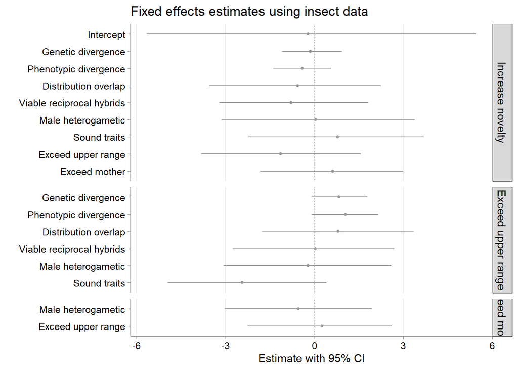

Fixed effects estimates: insect subset data

| Group | Factors | Estimates | 95% credible interval | P | significance |
| --- | --- | --- | --- | --- | --- |
| Increase novelty | Intercept | -0.22 | -5.65 – 5.45 | 0.912 |  |
| Increase novelty | Exceed mother | 0.62 | -1.83 – 3 | 0.627 |  |
| Increase novelty | Male heterogametic | 0.04 | -3.13 – 3.38 | 0.965 |  |
| Increase novelty | Exceed upper range | -1.14 | -3.82 – 1.56 | 0.403 |  |
| Increase novelty | Genetic divergence | -0.14 | -1.09 – 0.93 | 0.777 |  |
| Increase novelty | Phenotypic divergence | -0.41 | -1.39 – 0.57 | 0.408 |  |
| Increase novelty | Sound traits | 0.78 | -2.25 – 3.69 | 0.586 |  |
| Increase novelty | Distribution overlap | -0.57 | -3.54 – 2.24 | 0.695 |  |
| Increase novelty | Viable reciprocal hybrids | -0.78 | -3.2 – 1.82 | 0.527 |  |
| Exceed mother | Male heterogametic | -0.55 | -3.03 – 1.94 | 0.677 |  |
| Exceed mother | Exceed upper range | 0.25 | -2.25 – 2.62 | 0.842 |  |
| Exceed upper range | Genetic divergence | 0.83 | -0.1 – 1.78 | 0.085 |  |
| Exceed upper range | Phenotypic divergence | 1.04 | -0.1 – 2.15 | 0.067 |  |
| Exceed upper range | Male heterogametic | -0.21 | -3.07 – 2.59 | 0.896 |  |
| Exceed upper range | Sound traits | -2.45 | -4.95 – 0.41 | 0.079 |  |
| Exceed upper range | Distribution overlap | 0.79 | -1.78 – 3.36 | 0.544 |  |
| Exceed upper range | Viable reciprocal hybrids | 0.03 | -2.76 – 2.69 | 0.975 |  |

Random effects estimates: insect data

| Random effects | Estimates | 95% credible interval |
| --- | --- | --- |
| Study.ID | 13.88 | 0.36–51.78 |
| Cross.ID | 1.68 | 0–8.89 |
| spL.name | 18.74 | 0.08–74.21 |
| SE.units | 565.34 | 123.22–1224.95 |
| units | 0.74 | 0.74–0.74 |

While significant moderators become no longer significant in `insect` subset data, effects are qualitatively the same in sign.

## Effects of significant moderators

To visually interpret the impacts of significant moderators, we additionally conducted simpler models for each significant factor. As moderators, we included the focal factors, the compared parental species – spLL or spSS, and the interaction between them. Response variables and random effects of simper models were identical to full models.

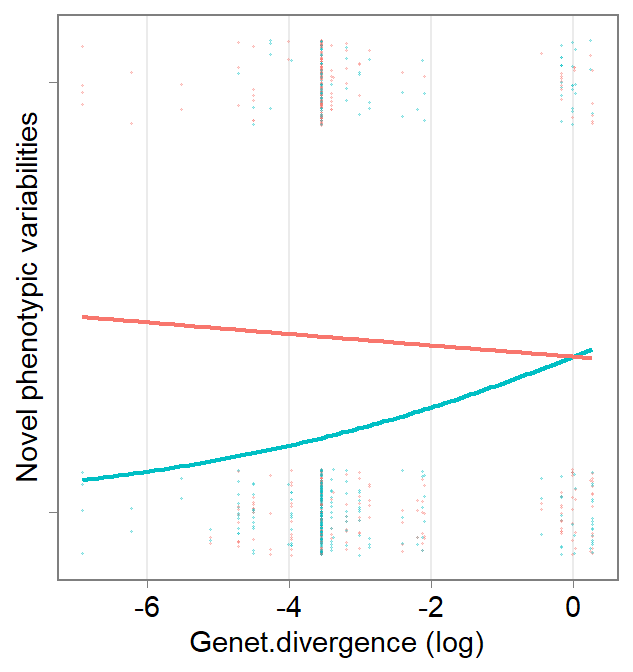

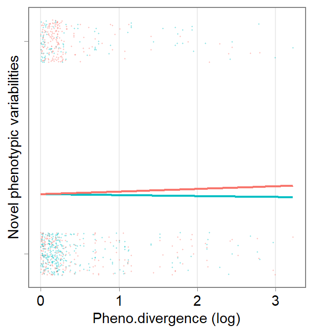

```r
# +++++++++++++++++++++++++++++++++++++++++++#
# To set raw metadata in X axis, reload raw metadata and combine to transgression dataset
# +++++++++++++++++++++++++++++++++++++++++++#
rawdat <- dat.full %>%
  select(-Pheno.divergence, -Genet.divergence) %>%
  # lnRR between parental species as phenotypic distance
  mutate(Pheno.divergence = abs(log(Mn.spL/Mn.spS))) %>%
  left_join(
    .,
    read.xlsx("../data/original.data.xlsx", sheet = "Species.level.moderators") %>%
      select(Cross.ID, Genet.divergence)
    ) %>%
  # Natural log of genetic distance
  mutate_at("Genet.divergence", log)

# # +++++++++++++++++++++++++++++++++++++++++++#
# # Regression: Genetic distance
# # +++++++++++++++++++++++++++++++++++++++++++#
#
# ## Setting prior to logistic regression ###
# prior <- list(
#   B=list(
#     mu = rep(0, 3), # N of coefficient. (level -1) for categorical factors, 1 for continuous factors, 1 for intercept
#     V = gelman.prior(~ direction:Genet.divergence + Genet.divergence,
#     data = rawdat, # formula and data
#     scale=sqrt(pi^2/3+1))), # error distribution of logistic regression
#   R=list(V=1,fix=1),
#   G = list(
#     G1 = list(V = 1, nu = 1, alpha.mu = 0, alpha.V = 1000),
#     G2 = list(V = 1, nu = 1, alpha.mu = 0, alpha.V = 1000),
#     G3 = list(V = 1, nu = 1, alpha.mu = 0, alpha.V = 1000),
#     G4 = list(V = 1, nu = 1, alpha.mu = 0, alpha.V = 1000)
#     )
#   )
# ## Phylogenetic binomial regression ###
# phylmix <-MCMCglmm(
#   fixed = Novelty ~ direction:Genet.divergence + Genet.divergence,
#   # idh(SE):units | weight by SE of effect size
#   random = ~ Study.ID + Cross.ID + spL.name + idh(SE):units,
#   family = "categorical",
#   verbose = FALSE,
#   ginverse = list(spL.name = phylo_MCMC),
#   prior = prior,
#   data = rawdat,
#   nitt = 60000,  # Increase the number of iterations, default is 13000
#   burnin = 5000  # Increase the number of burnin, default is 3000
# )
# phylmix$Sol <- phylmix$Sol/sqrt(1+c2)
# ## Save model ###
# saveRDS(phylmix, file ="../Analysis/Variation.novelty.Genet.divergence.obj")
#
# # +++++++++++++++++++++++++++++++++++++++++++#
# # Regression: Phenotypic divergence
# # +++++++++++++++++++++++++++++++++++++++++++#
#
# ## Setting prior to logistic regression ###
# prior <- list(
#   B=list(
#     mu = rep(0, 3), # N of coefficient. (level -1) for categorical factors, 1 for continuous factors, 1 for intercept
#     V = gelman.prior(~ direction:Pheno.divergence + Pheno.divergence,
#     data = rawdat, # formula and data
#     scale=sqrt(pi^2/3+1))), # error distribution of logistic regression
#   R=list(V=1,fix=1),
#   G = list(
#     G1 = list(V = 1, nu = 1, alpha.mu = 0, alpha.V = 1000),
#     G2 = list(V = 1, nu = 1, alpha.mu = 0, alpha.V = 1000),
#     G3 = list(V = 1, nu = 1, alpha.mu = 0, alpha.V = 1000),
#     G4 = list(V = 1, nu = 1, alpha.mu = 0, alpha.V = 1000)
#     )
#   )
# ## Phylogenetic binomial regression ###
# phylmix <-MCMCglmm(
#   fixed = Novelty ~ direction:Pheno.divergence + Pheno.divergence,
#   # idh(SE):units | weight by SE of effect size
#   random = ~ Study.ID + Cross.ID + spL.name + idh(SE):units,
#   family = "categorical",
#   verbose = FALSE,
#   ginverse = list(spL.name = phylo_MCMC),
#   prior = prior,
#   data = rawdat,
#   nitt = 60000,  # Increase the number of iterations, default is 13000
#   burnin = 5000  # Increase the number of burnin, default is 3000
# )
# phylmix$Sol <- phylmix$Sol/sqrt(1+c2)
# ## Save model ###
# saveRDS(phylmix, file ="../Analysis/Variation.novelty.Pheno.divergence.obj")

#++++++++++++++++++++++++++++++++++++++++++++++++++#
# Plot
#++++++++++++++++++++++++++++++++++++++++++++++++++#

for (i in c("Genet.divergence", "Pheno.divergence")) {

  ## Load model ###
  phylmix <- readRDS(
    paste("../Analysis/Variation.novelty",i, "obj", sep = ".")
    )
  reg <- summary(phylmix$Sol)$statistics %>%
      as.data.frame()

  ## Plot ###
  plot <- ggplot(rawdat, aes(x = rawdat[,i], y = rawdat[, "Novelty"])) +
    geom_jitter(
      height = 0.1, width = 0, aes(color = direction), alpha = 0.3, size = 0.2
      ) +
    # Larger variabilities
    stat_function(
      aes(color = "+"), size = 0.8,
      fun = function(x)
        1/(1 + exp(-(reg[1,1] + x*(reg[2,1]+reg[3,1]))))
      ) +
    # Smaller variabilities
    stat_function(
      aes(color = "-"), size = 0.8,
      fun = function(x)
        1/(1 + exp(-(reg[1,1] + x*reg[2,1])))
      ) +
    ylab("Novel phenotypic variabilities") +
    xlab(paste(i, "(log)")) +
    scale_fill_brewer(palette = "Set2") +
    scale_y_continuous(breaks=seq(0,1)) +
    regressiontheme

  print(plot)
  # ggsave(
  #   plot = plot + theme(axis.title  = element_blank()),
  #   file = paste("../Plot/part_novelvarscontinuous", i, "svg", sep = "."),
  #   height = 1.7, width = 1.6
  # )

}
```

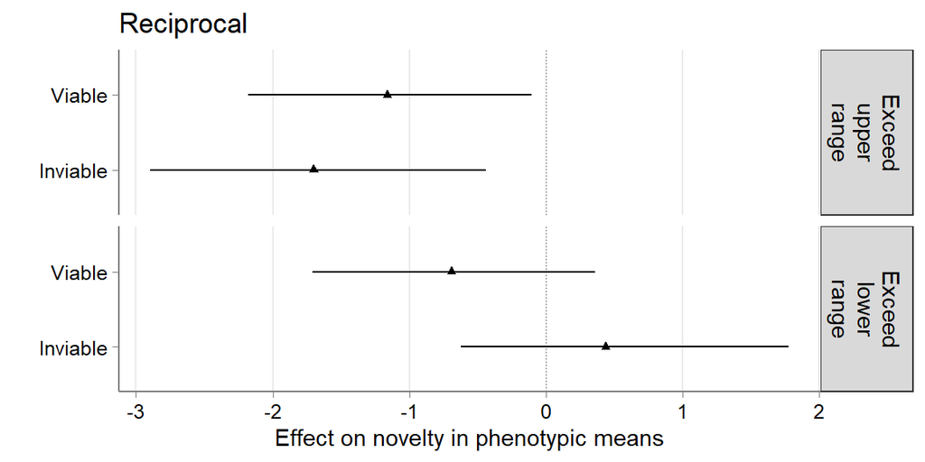

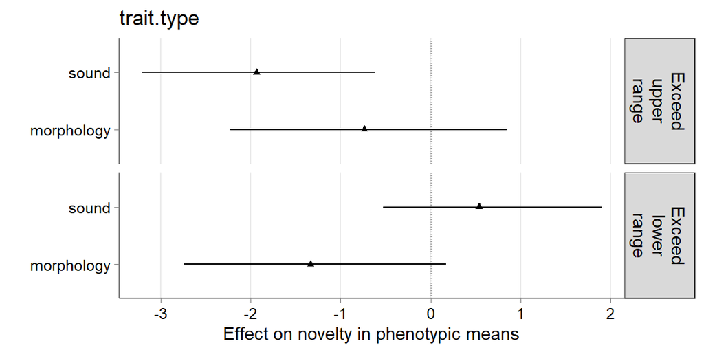

```r
for (i in c("Reciprocal", "trait.type")) {

  # Make new categorical data combining direction of TS and target categorical factor
  dat %<>%
    mutate(interaction = str_c(direction, .[, i], sep = "_"))

  # ## Setting prior to logistic regression ###
  # prior <- list(
  #   B=list(
  #     mu = rep(0, 4), # N of coefficient. (level -1) for categorical factors, 1 for continuous factors, 1 for intercept
  #     V = gelman.prior(~ interaction,
  #     data = dat, # formula and data
  #     scale=sqrt(pi^2/3+1))), # error distribution of logistic regression
  #   R=list(V=1,fix=1),
  #   # Replicating same G for the number of random effects (here, 4)
  #   G = list(
  #     G1 = list(V = 1, nu = 1, alpha.mu = 0, alpha.V = 1000),
  #     G2 = list(V = 1, nu = 1, alpha.mu = 0, alpha.V = 1000),
  #     G3 = list(V = 1, nu = 1, alpha.mu = 0, alpha.V = 1000),
  #     G4 = list(V = 1, nu = 1, alpha.mu = 0, alpha.V = 1000)
  #     )
  #   )
  # ## Run model ###
  # phylmix <-MCMCglmm(
  #   fixed = Novelty ~  interaction -1, # + trait.direction
  #   family = "categorical",
  #   # idh(SE):units | weight by SE of effect size
  #   random = ~ Study.ID + Cross.ID + spL.name + idh(SE):units,
  #   verbose = FALSE,
  #   ginverse = list(spL.name = phylo_MCMC),
  #   prior = prior,
  #   data = dat
  # )
  # # Correcting estimate
  # phylmix$Sol <- phylmix$Sol/sqrt(1+c2)
  # ## Save model ###
  # saveRDS(
  #   phylmix,
  #   file =
  #     paste("../Analysis/Variation.novelty", i, "alltaxon.obj", sep = ".")
  #     )

  #++++++++++++++++++++++++++++++++++++++#
  # Grouping interaction terms
  #++++++++++++++++++++++++++++++++++++++#
  phylmix <- readRDS(
    paste("../Analysis/Variation.novelty", i, "alltaxon.obj", sep = ".")
    )

  sum <- summary(phylmix)$solutions %>%
    as.data.frame() %>%
    rownames_to_column(var = "factors") %>%
    mutate(
      # Impact on exceeding upper or lower range
      direction =
        ifelse(str_detect(factors, "interaction\\+"),
               "Exceed upper range",
               "Exceed lower range"
               ) %>%
        as.factor
      ) %>%
    within(direction <- ordered(direction, c("Exceed upper range", "Exceed lower range"))) %>%
    ## Change factor names ###
    within(
      factors <- str_remove_all(factors, "interaction._")
      )

    #++++++++++++++++++++++++++++++++++++++#
    # Plot
    #++++++++++++++++++++++++++++++++++++++#
    categoricalplot <- ggplot(sum, aes(x = post.mean, y = factors)) +
      # Vertical line
      geom_vline(
        xintercept = 0, size = 0.3,
        colour = "grey30", linetype = "dotted"
        ) +
      # CI
      geom_errorbarh(
        aes(xmin = sum[, 'l-95% CI'], xmax = sum[, 'u-95% CI']),
        height = .0001
        ) +
      geom_point(size = 1.3, shape = 17) +
      # Title
      ylab("") + xlab("Effect on novelty in phenotypic means") +
      ggtitle(i) +
      # Combine different plots for main factors and interactions
      facet_grid(
        direction ~., scales = "free", drop = TRUE,
        labeller = label_wrap_gen(width = 11)
        ) +
      foresttheme
    print(categoricalplot)

  # ggsave(
  #     plot = categoricalplot + theme(axis.text.y = element_blank()),
  #     file =
  #       paste("../Analysis/Variation.novelty.categorical", i,taxon, "svg", sep = "."),
  #     height = 1.8, width = 2.5
  #     )

}
```

# Phenotypic variability of novel phenotype

## Dataset summary

Relative variability indicates F1 hybrids’ phenotypic variability size (CV) compared to those of parents.

- Smaller: Smaller variabilities than of both parents
- Intermediate: intermediate between parents’ variability
- Larger: Larger variabilities than of both parents

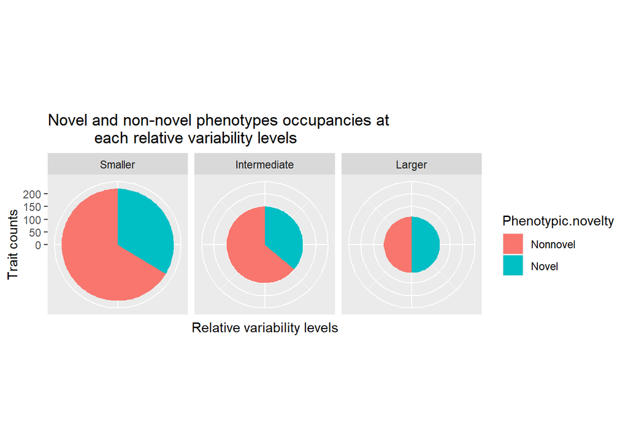

```r
dat <- read.csv("../data/dat.novelty.csv", head = TRUE) %>%
  mutate_at(vars("mean.novelty", "relative.var"), as.factor) %>%
  within(
    relative.var <-
      ordered(relative.var, levels = c("Smaller", "Intermediate", "Larger")),
    mean.novelty <-
      ordered(mean.novelty, levels = c("Nonnovel", "Novel"))
  )

dat.relat.var <- dat %>%
  group_by(mean.novelty, relative.var) %>%
  summarise('N (Trait observation)' = length(ES.ID)) %>%
  spread(key = mean.novelty, value = 'N (Trait observation)') %>%
  as.data.frame() %>%
  mutate(
    "Nonnovel phenotype (% trait obs)" =
      Nonnovel/sum(Nonnovel)*100,
    "Novel phenotype (% trait obs)" =
      Novel/sum(Novel)*100,
    Trait.count = Nonnovel + Novel # N of traits at each variability levels
  ) %>%
  rename('Relative.variability' = 'relative.var')

ggplot(
  dat.relat.var %>%
    dplyr::select(-contains("trait obs"), -Trait.count) %>%
    pivot_longer(
      col = -Relative.variability,
      names_to = "Phenotypic.novelty",
      values_to = "Count"
      ) %>%
    left_join(dat.relat.var) %>%
    as.data.frame %>%
    mutate_at("Phenotypic.novelty", as.factor),
  aes(
    y = Count,
    x = Trait.count/2,  # ensure each pie chart is "left-aligned"
    width = Trait.count, # sample size (N of traits at each variability levels)
    fill = Phenotypic.novelty
    )
  ) +
  geom_bar(position="fill", stat = "identity") +
  facet_grid(~ Relative.variability) +
  # Pie chart
  coord_polar("y") +
  ggtitle("Novel and non-novel phenotypes occupancies at
          each relative variability levels") +
  xlab("Trait counts") + ylab("Relative variability levels") +
  theme(axis.text.x = element_blank())
```

```r
dat.relat.var %>%
  rename(
  'Nonnovel.phenotype (N)' = 'Nonnovel',
  'Novel.phenotype (N)' = 'Novel'
  ) %>%
  kable("html", digits = 1, caption = "Dataset summary") %>%
  kable_styling("striped", position = "left")
```

Dataset summary

| Relative.variability | Nonnovel.phenotype (N) | Novel.phenotype (N) | Nonnovel phenotype (% trait obs) | Novel phenotype (% trait obs) | Trait.count |
| --- | --- | --- | --- | --- | --- |
| Smaller | 146 | 74 | 49.2 | 40.4 | 220 |
| Intermediate | 96 | 54 | 32.3 | 29.5 | 150 |
| Larger | 55 | 55 | 18.5 | 30.1 | 110 |

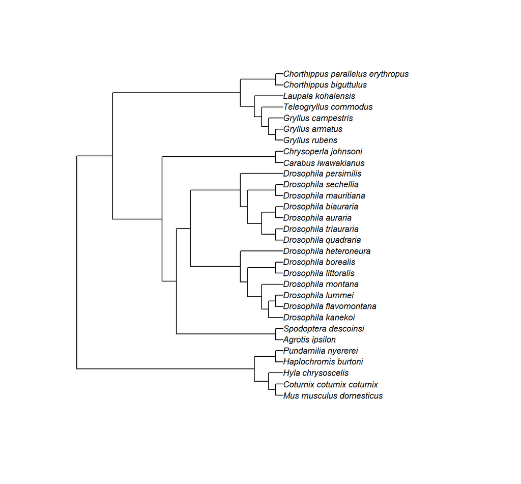

Figure S3. Phylogenetic tree used, which was based on tree of the parental species within a cross which name comes earlier in alphabetical order

```r
#++++++++++++++++++++++++++++++++++++++++++++++++++++++#
# Read create tree based on Open Tree of Life taxonomy
#++++++++++++++++++++++++++++++++++++++++++++++++++++++#

# # matching names from open tree taxonomy
# taxa <- tnrs_match_names(
#   names = levels(dat$sp1.name) %>%
#     str_replace_all("_", " "),
#   context_name = "Animals"
#   )
#
# # Create tree
# tree <- tol_induced_subtree(ott_ids = taxa$ott_id)
# tree$tip.label %<>%
#   strip_ott_ids # remove OTT IDs from tip labels
# # randomly solve non-binary phylogeny
# set.seed(6)
# bin.tree <- multi2di(tree, random = T)
# print("Randomly solved phylogeny")
#
# # Indicate mismatch between tip labels & dataset species names
# setdiff(levels(as.factor(bin.tree$tip.label)), levels(dat$sp1.name))
# setdiff(levels(dat$sp1.name), levels(as.factor(bin.tree$tip.label)))
# # Fix names of tip labels
# bin.tree$tip.label %<>% str_replace_all("Dryophytes", "Hyla")
#
# write.tree(bin.tree, file= "../data/phylo.novelty.tre")

#++++++++++++++++++++++++++++++++++#
# Phylogenetic tree for mcmcglmm
#++++++++++++++++++++++++++++++++++#

# compute branch lengths of tree
phylo_branch <- read.tree(file = "../data/phylo.novelty.tre") %>%
  compute.brlen(method = "Grafen", power = 1)
plot.phylo(phylo_branch, cex = 0.7)
```

```r
# saving phylogeneic matrix
phylo_cor <- vcv(phylo_branch, cor = T)

# generating inverse phylogenetic matrix for MCMCglmm
phylo_branch$node.label <- NULL
phylo_MCMC <- MCMCglmm::inverseA(phylo_branch, nodes = "ALL", scale = TRUE)$Ainv
```

## Phylogenetic ordinal (probit) regression

Here we ask if phenotypic novelty associate with relative variability levels. We conducted ordinal regression, employing categorical ordered variability levels (smaller < intermediate < larger, see above) as response variable, and categorical trait mean novelty levels (fixed effect `mean.novelty` with 2 levels: `Novel` vs `Nonnovel`) as moderator variable, using `MCMCglmm` function. The model included following Random effects estimates:

```r
# prior1<-list(
#   B=list(
#     mu=c(0,0),
#     V=gelman.prior(~mean.novelty, data=select(dat, -trait), scale=sqrt(1+1))
#     ),
#   R=list(V=1,fix=1),
#   G = list(
#     G1 = list(V = 1, nu = 1, alpha.mu = 0, alpha.V = 1000),
#     G2 = list(V = 1, nu = 1, alpha.mu = 0, alpha.V = 1000),
#     G3 = list(V = 1, nu = 1, alpha.mu = 0, alpha.V = 1000),
#     G3 = list(V = 1, nu = 1, alpha.mu = 0, alpha.V = 1000),
#     G4 = list(V = 1, nu = 1, alpha.mu = 0, alpha.V = 1000)
#     )
#   )
#
# phylmix <-MCMCglmm(
#   fixed = relative.var ~ mean.novelty,
#   family = "ordinal",
#   random = ~ Study.ID + Cross.ID + sp1.name + cross + ES.ID,
#   verbose = FALSE,
#   prior = prior1,
#   ginverse = list(sp1.name = phylo_MCMC),
#   data = select(dat, -trait),
#   nitt = 60000,  # Increase the number of iterations, default is 13000
#   burnin = 5000  # Increase the number of burnin, default is 3000
#   )
#
# ## Save model ###
# saveRDS(phylmix, file = "../Analysis/novelty.mean.var.obj")

## Load model ###
phylmix <- readRDS("../Analysis/novelty.mean.var.obj")

#+++++++++++++++++++++++++++#
# Fixed effects output
#+++++++++++++++++++++++++++#
get_fixed.MCMCglmm(summary(phylmix)$solutions) %>%
  dplyr::select("Factors", "Estimates", "95% credible interval", "P") %>%
  kable("html", digits = 3, caption = "Fixed effects estimates") %>%
  kable_styling("striped", position = "left")
```

Fixed effects estimates

| Factors | Estimates | 95% credible interval | P |
| --- | --- | --- | --- |
| (Intercept) | 0.23 | -1.72 – 1.94 | 0.678 |
| mean.noveltyNovel | 1.01 | 0.45 – 1.62 | < 0.001 |

```r
#+++++++++++++++++++++++++++#
# Random effects output
#+++++++++++++++++++++++++++#
# transformation for varaince
get_random.MCMCglmm(summary(phylmix$VCV/(1+c2))) %>%
  kable("html", digits = 2, caption = "Random effects estimates") %>%
  kable_styling("striped", position = "left")
```

Random effects estimates

| Random effects | Estimates | 95% credible interval |
| --- | --- | --- |
| Study.ID | 1.27 | 0.14–3.61 |
| Cross.ID | 0.23 | 0–1.12 |
| sp1.name | 0.52 | 0–3.04 |
| cross | 18.92 | 0–138.18 |
| ES.ID | 3.21 | 1.34–5.84 |
| units | 0.74 | 0.74–0.74 |

The phenotypic novelty (`mean.noveltyNovel`) influenced positively. This indicates that, compared to non-novel phenotypes, novel phenotypes have greater chances to be more variable than parents’ phenotypes.

# Trait mosaicism

F1 hybrids can be seen as “a mosaic of both parental and intermediate morphological characters rather than just intermediate ones” [Rieseberg and Ellstrand 1993](https://doi.org/10.1080/07352689309701902). That is, F1 hybrid individuals often consist of trats closely resemble one parent, intermediate, and resemble the other parent. Mosaicism indicates tr integration of parents are often collapse in F1 hybrids. Here we investigate the strength of trait mosaicism in male mating traits.

## d<sub>mismatch</sub> calculation

To quantify trait mosaicism in each crossing, we calculated d<sub>mismatch</sub> following [Thompson et al.](https://www.biorxiv.org/content/10.1101/818658v1.full#disp-formula-1) (2021). d<sub>mismatch</sub> was calculated as follows:

$d_{mismatch} = \sqrt{2} * \sqrt{ Z_i^2 + Z_j^2 - \frac{Z_i + Z_j}{\sqrt{2}}^2 }$  
Where $Z_i$, standardized hybrid trait value in trait $i$, is  
$Z_i = \frac{hyb_i - spSS_i}{spLL_i - spSS_i}$

$Z_i$ is 0-1 if F1 phenotypic mean lies within the range of parents. We note, however, novelty in phenotypic means (transgressive segregation) can result in quite large $Z_i$: when trait size is large and parental phenotypic divergence is small, novel hybrid phenotype will result in quite large $Z_i$. This seems occurred in mice (see bellow)

```r
dat <- original.dat %>%
  select(Study.ID, Cross.ID, taxa, Genus, Reciprocal, contains("Mn")) %>%
  # Gather reciprocal hybrid data
  gather(
    key = Hybrid, value = Mn.hybrid,
    -c(Study.ID, Cross.ID, taxa, Genus, Reciprocal), -contains("Mn.sp")
    ) %>%
  drop_na(Mn.hybrid) %>%
  # Calculate standardized hybrid phenotype mean
  mutate(
    Dominance = ifelse(
      Mn.sp1 > Mn.sp2,
      (Mn.hybrid - Mn.sp2)/abs(Mn.sp1 - Mn.sp2),
      (Mn.hybrid - Mn.sp1)/abs(Mn.sp1 - Mn.sp2)
    )
  ) %>%
  mutate_at("Cross.ID", as.factor) %>%
  arrange(taxa, Genus, Cross.ID, Hybrid) %>%
  # only get crosses with > 2 traits
  # Reciprocal hybrids are separated
  group_by(Cross.ID, Hybrid, taxa, Genus, Study.ID, Reciprocal) %>%
  filter(n() > 2) %>%
  # Create all combinations of standardized hybrid phenotype mean
  do(data.frame(t(combn(.$Dominance, 2)))) %>%
  # Calculate dominance mismatch
  mutate(
    Mismatch = sqrt(2) * sqrt( X1^2 + X2^2 - ( (X1 + X2) / sqrt(2) )^2 ),
    Mismatch.log = log(Mismatch)
  ) %>%
  left_join(meta) %>%
  mutate_if(is.character, as.factor) %>%
  within(taxa <- ordered(taxa, levels = c("Neuroptera", "Coleoptera", "Diptera", "Lepidoptera", "Orthoptera", "Aves", "Rodentia", "Anura", "Cichliformes"))) %>%
  as.data.frame
```

## Distribution of d<sub>mismatch</sub>

```r
dat %>%
  summarise(
    'Trait combination' = length(X1),
    'Species pair' = length(unique(species.pair)),
    'Crossing' = length(unique(Cross.ID))
    ) %>%
  kable("html", caption = "Dataset summary") %>%
  kable_styling("striped", position = "left")
```

Dataset summary

| Trait combination | Species pair | Crossing |
| --- | --- | --- |
| 15107 | 20 | 27 |

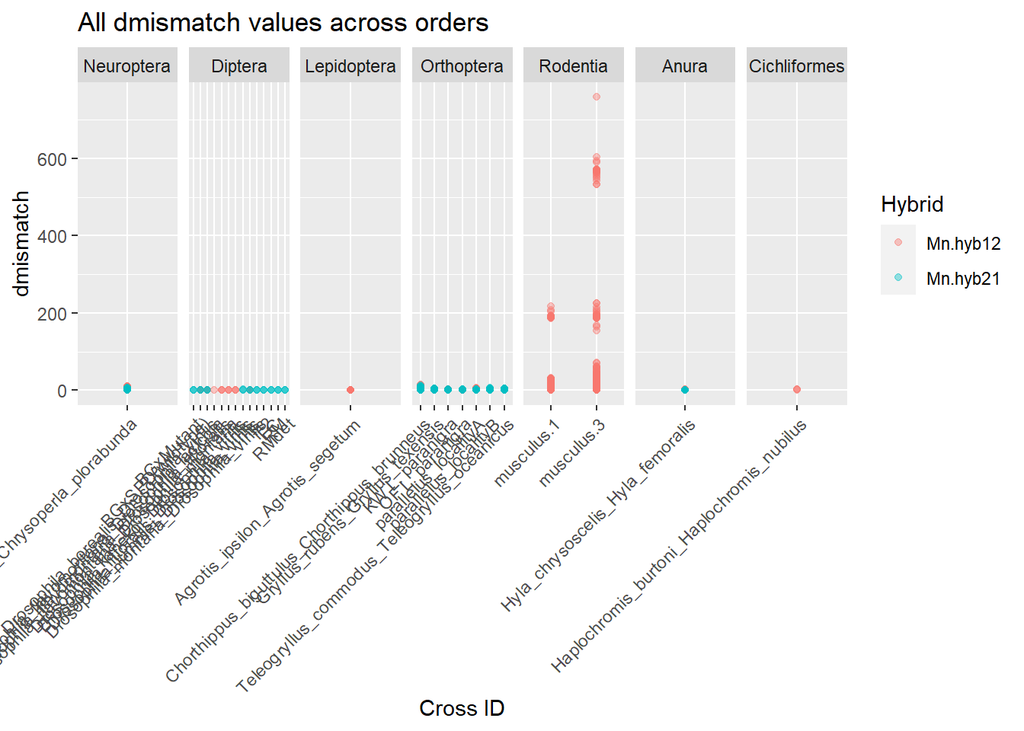

```r
ggplot(data = dat, aes(x = Cross.ID, y = Mismatch)) +
  geom_point(alpha = 0.4, aes(color = Hybrid)) +
  xlab("Cross ID") + ylab("dmismatch") +
  theme(axis.text.x = element_text(angle = 45, hjust = 1)) +
  facet_grid(~taxa, scales = "free") +
  ggtitle("All dmismatch values across orders")
```

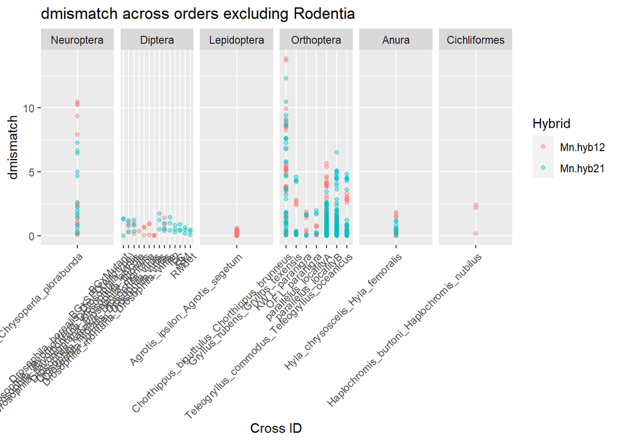

```r
ggplot(
  data = dat %>%
    filter(!grepl("musculus", Cross.ID)),
  aes(x = Cross.ID, y = Mismatch)) +
  xlab("Cross ID") + ylab("dmismatch") +
  geom_point(alpha = 0.4, aes(color = Hybrid)) +
  theme(axis.text.x = element_text(angle = 45, hjust = 1)) +
  facet_grid(~taxa, scales = "free") +
  ggtitle("dmismatch across orders excluding Rodentia")
```

d<sub>mismatch</sub> is quite large in crossing involving mices (Rodentia), due to large trait value.